# VirCapSeq Analysis Report

## Dataset Summary

Dataset Overview

[output not shown]

Dataset Index and Descriptions

| Index | Name | Description |
| --- | --- | --- |
| 1 | PathCare | Pathcare Dataset |
| 2 | NHLS_GS | NHLS Groote Schuur |
| 3 | NHLS_TY | NHLS Tygerberg |
| 4 | Mucokids | Muco-kids |
| 5 | SUDI | SUDI |
| 6 | ALL_COMBINED | COMBINED dataset - All datasets merged together |

## Dataset 1: Pathcare

### Overview

Basic Statistics for PathCare

| Metric | Value |
| --- | --- |
| Number of unique samples | 260 |
| Number of pathogens | 6 |
| Total observations | 2080 |
| PCR detections | 282 |
| PCR non-detections | 861 |

### Performance

#### Coverage Threshold Performance

Coverage Threshold Performance

| Threshold | TP | FN | FP | TN | Sensitivity | Specificity |
| --- | --- | --- | --- | --- | --- | --- |
| cov10 | 223 | 59 | 68 | 793 | 0.791 | 0.921 |
| cov20 | 210 | 72 | 37 | 824 | 0.745 | 0.957 |
| cov50 | 185 | 97 | 9 | 852 | 0.656 | 0.990 |
| cov80 | 168 | 114 | 4 | 857 | 0.596 | 0.995 |
| cov90 | 154 | 128 | 2 | 859 | 0.546 | 0.998 |

#### RPM Threshold Performance

RPM Threshold Performance

| Threshold | TP | FN | FP | TN | Sensitivity | Specificity |
| --- | --- | --- | --- | --- | --- | --- |
| rpm1 | 245 | 37 | 177 | 684 | 0.869 | 0.794 |
| rpm10 | 238 | 44 | 109 | 752 | 0.844 | 0.873 |
| rpm100 | 213 | 69 | 53 | 808 | 0.755 | 0.938 |
| rpm1000 | 173 | 109 | 18 | 843 | 0.613 | 0.979 |

#### Depth Threshold Performance

Depth Threshold Performance

| Threshold | TP | FN | FP | TN | Sensitivity | Specificity |
| --- | --- | --- | --- | --- | --- | --- |
| depth10 | 199 | 83 | 33 | 828 | 0.706 | 0.962 |
| depth30 | 170 | 112 | 31 | 830 | 0.603 | 0.964 |

### Plots

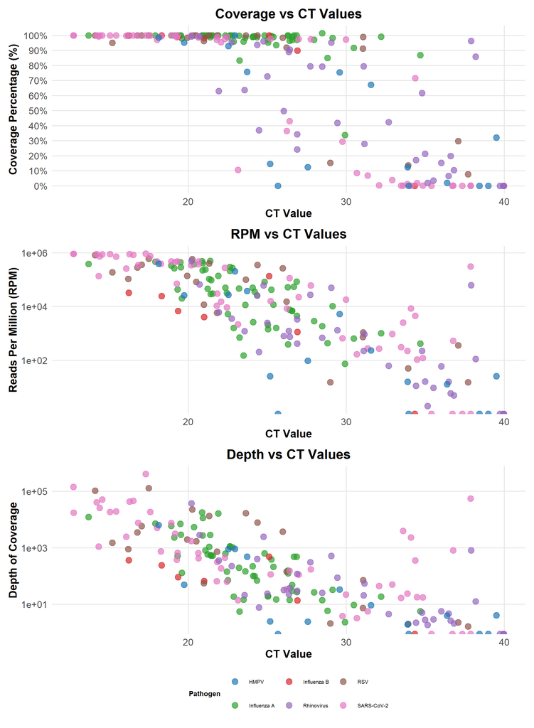

### ROC curves

ROC Performance Metrics

| Metric | AUC |
| --- | --- |
| Genome coverage | 0.9086746 |
| RPM | 0.9060531 |
| Depth | 0.8988847 |

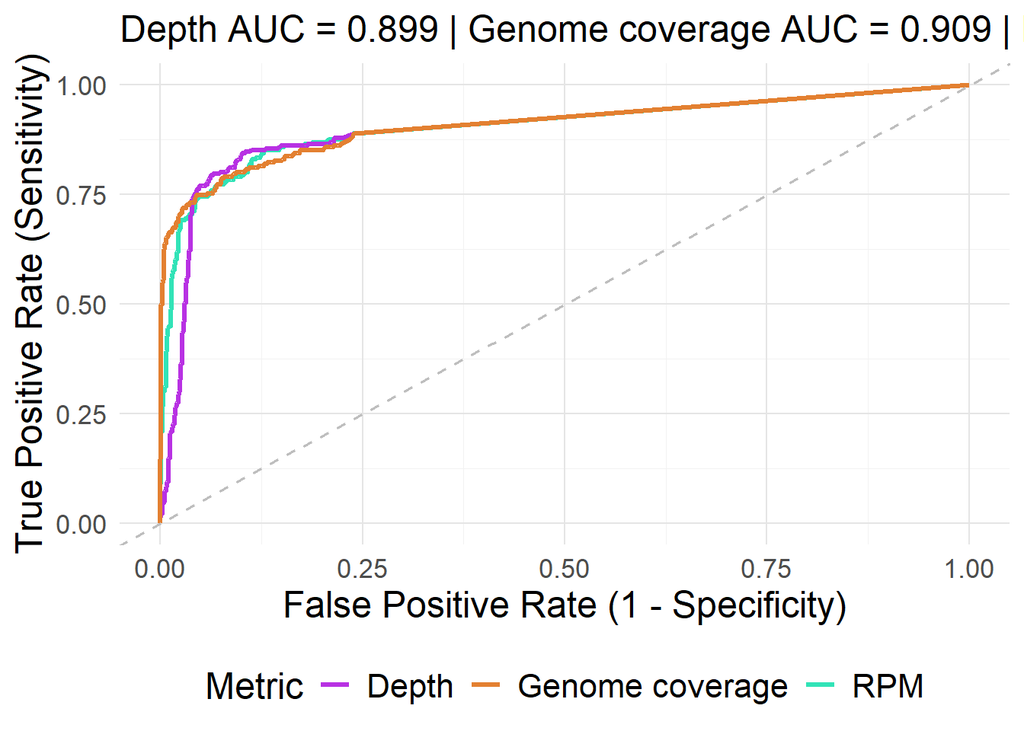

Plot saved to: figures/ROC_PathCare.png

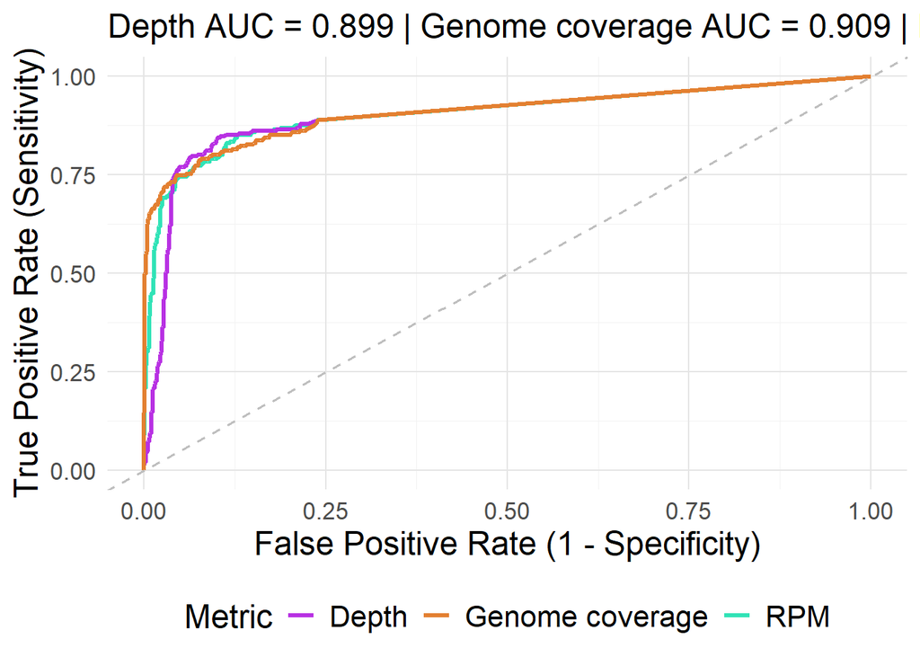

### CT Threshold

#### Coverage Performance (Ct < 30) & removed CT if NA

Coverage Analysis with Ct < 30 Filter

| Threshold | TP | FN | Sensitivity |
| --- | --- | --- | --- |
| cov10 | 139 | 1 | 0.993 |
| cov20 | 135 | 5 | 0.964 |
| cov50 | 126 | 14 | 0.900 |
| cov80 | 119 | 21 | 0.850 |
| cov90 | 115 | 25 | 0.821 |

#### RPM Performance (Ct < 30) & removed CT if NA

RPM Analysis with Ct < 30 Filter

| Threshold | TP | FN | Sensitivity |
| --- | --- | --- | --- |
| rpm10 | 139 | 1 | 0.993 |
| rpm100 | 135 | 5 | 0.964 |
| rpm500 | 130 | 10 | 0.929 |
| rpm1000 | 125 | 15 | 0.893 |

### Error Analysis <30 Coverage

#### False Negatives Samples (coverage)

False Negatives samples for PathCare ( coverage )

| sample_id | Pathogen | PCR_Result | SEQ_Result | Threshold | coverage_percentage | rpm | depth_of_coverage | ct_values |
| --- | --- | --- | --- | --- | --- | --- | --- | --- |
| C070882 | HMPV | 1 | 0 | cov10 | 0.00000 | 0.00000 | 0.000000 | 25.68 |
| C070885 | HMPV | 1 | 0 | cov20 | 12.41000 | 95.80000 | 2.410000 | 27.57 |
| C071521 | HMPV | 1 | 0 | cov20 | 14.59000 | 25.24000 | 2.500000 | 25.18 |
| C070872 | RSV | 1 | 0 | cov20 | 15.24000 | 15.01000 | 2.090000 | 28.99 |
| C070398 | SARS-CoV-2 | 1 | 0 | cov20 | 10.63000 | 2158.36000 | 14.080000 | 23.14 |
| VCS-C073372 | Influenza A | 1 | 0 | cov50 | 33.68313 | 72.54729 | 2.317429 | 29.92 |
| C070383 | Rhinovirus | 1 | 0 | cov50 | 37.03000 | 203.76000 | 7.650000 | 24.47 |
| C071075 | Rhinovirus | 1 | 0 | cov50 | 49.73000 | 792.69000 | 32.050000 | 26.04 |
| C071083 | Rhinovirus | 1 | 0 | cov50 | 24.15000 | 417.29000 | 30.130000 | 26.89 |
| C071084 | Rhinovirus | 1 | 0 | cov50 | 34.19000 | 3314.73000 | 119.970000 | 26.89 |
| C071521 | Rhinovirus | 1 | 0 | cov50 | 41.74000 | 1318.41000 | 88.510000 | 29.44 |
| C070400 | SARS-CoV-2 | 1 | 0 | cov50 | 29.40000 | 654.04000 | 3.830000 | 29.75 |
| C070870 | SARS-CoV-2 | 1 | 0 | cov50 | 36.45000 | 8497.81000 | 34.740000 | 26.23 |
| C071502 | SARS-CoV-2 | 1 | 0 | cov50 | 43.07000 | 114400.80000 | 151.810000 | 26.41 |
| C071072 | HMPV | 1 | 0 | cov80 | 75.75000 | 37619.98000 | 482.840000 | 23.72 |
| C071076 | HMPV | 1 | 0 | cov80 | 75.51000 | 5277.15000 | 33.600000 | 29.58 |
| C070330 | Rhinovirus | 1 | 0 | cov80 | 62.97000 | 6159.50000 | 357.340000 | 21.93 |
| C070881 | Rhinovirus | 1 | 0 | cov80 | 63.60000 | 1195.86000 | 21.250000 | 23.57 |
| C070886 | Rhinovirus | 1 | 0 | cov80 | 72.76000 | 2469.07000 | 23.980000 | 25.00 |
| C071082 | Rhinovirus | 1 | 0 | cov80 | 79.49000 | 27450.51000 | 305.830000 | 27.72 |
| C071086 | Rhinovirus | 1 | 0 | cov80 | 79.31000 | 679.26000 | 25.600000 | 28.48 |
| C070389 | Influenza A | 1 | 0 | cov90 | 83.32000 | 701.69000 | 5.600000 | 23.25 |
| VCS-C073441 | Influenza A | 1 | 0 | cov90 | 84.97835 | 431.45309 | 5.864767 | 28.81 |
| C070321 | Influenza B | 1 | 0 | cov90 | 89.84000 | 1119.63000 | 13.770000 | 26.91 |
| C070883 | Rhinovirus | 1 | 0 | cov90 | 89.07000 | 1226.94000 | 22.530000 | 26.36 |

#### No False Positives Samples found for coverage metric

#### False Negatives Samples (rpm)

False Negatives samples for PathCare ( rpm )

| sample_id | Pathogen | PCR_Result | SEQ_Result | Threshold | coverage_percentage | rpm | depth_of_coverage | ct_values |
| --- | --- | --- | --- | --- | --- | --- | --- | --- |
| C070882 | HMPV | 1 | 0 | rpm1 | 0.00000 | 0.00000 | 0.000000 | 25.68 |
| C070885 | HMPV | 1 | 0 | rpm100 | 12.41000 | 95.80000 | 2.410000 | 27.57 |
| C071521 | HMPV | 1 | 0 | rpm100 | 14.59000 | 25.24000 | 2.500000 | 25.18 |
| VCS-C073372 | Influenza A | 1 | 0 | rpm100 | 33.68313 | 72.54729 | 2.317429 | 29.92 |
| C070872 | RSV | 1 | 0 | rpm100 | 15.24000 | 15.01000 | 2.090000 | 28.99 |
| C070389 | Influenza A | 1 | 0 | rpm1000 | 83.32000 | 701.69000 | 5.600000 | 23.25 |
| C071112b | Influenza A | 1 | 0 | rpm1000 | 96.00000 | 150.48649 | 14.477475 | 23.50 |
| C071135b | Influenza A | 1 | 0 | rpm1000 | 99.96200 | 390.86882 | 123.216072 | 26.31 |
| VCS-C073441 | Influenza A | 1 | 0 | rpm1000 | 84.97835 | 431.45309 | 5.864767 | 28.81 |
| C070383 | Rhinovirus | 1 | 0 | rpm1000 | 37.03000 | 203.76000 | 7.650000 | 24.47 |
| C071075 | Rhinovirus | 1 | 0 | rpm1000 | 49.73000 | 792.69000 | 32.050000 | 26.04 |
| C071080 | Rhinovirus | 1 | 0 | rpm1000 | 90.62000 | 746.86000 | 37.550000 | 26.43 |
| C071083 | Rhinovirus | 1 | 0 | rpm1000 | 24.15000 | 417.29000 | 30.130000 | 26.89 |
| C071086 | Rhinovirus | 1 | 0 | rpm1000 | 79.31000 | 679.26000 | 25.600000 | 28.48 |
| C070400 | SARS-CoV-2 | 1 | 0 | rpm1000 | 29.40000 | 654.04000 | 3.830000 | 29.75 |

#### No False Positives Samples found for rpm metric

## Dataset 2: NHLS GS

### Overview

Basic Statistics for NHLS_GS

| Metric | Value |
| --- | --- |
| Number of unique samples | 40 |
| Number of pathogens | 8 |
| Total observations | 320 |
| PCR detections | 38 |
| PCR non-detections | 282 |

### Performance

#### Coverage Threshold Performance

Coverage Threshold Performance

| Threshold | TP | FN | FP | TN | Sensitivity | Specificity |
| --- | --- | --- | --- | --- | --- | --- |
| cov10 | 34 | 4 | 13 | 269 | 0.895 | 0.954 |
| cov20 | 32 | 6 | 9 | 273 | 0.842 | 0.968 |
| cov50 | 32 | 6 | 2 | 280 | 0.842 | 0.993 |
| cov80 | 25 | 13 | 0 | 282 | 0.658 | 1.000 |
| cov90 | 24 | 14 | 0 | 282 | 0.632 | 1.000 |

#### RPM Threshold Performance

RPM Threshold Performance

| Threshold | TP | FN | FP | TN | Sensitivity | Specificity |
| --- | --- | --- | --- | --- | --- | --- |
| rpm1 | 36 | 2 | 30 | 252 | 0.947 | 0.894 |
| rpm10 | 35 | 3 | 16 | 266 | 0.921 | 0.943 |
| rpm100 | 34 | 4 | 4 | 278 | 0.895 | 0.986 |
| rpm1000 | 30 | 8 | 2 | 280 | 0.789 | 0.993 |

#### Depth Threshold Performance

Depth Threshold Performance

| Threshold | TP | FN | FP | TN | Sensitivity | Specificity |
| --- | --- | --- | --- | --- | --- | --- |
| depth10 | 30 | 8 | 1 | 281 | 0.789 | 0.996 |
| depth30 | 21 | 17 | 1 | 281 | 0.553 | 0.996 |

### Plots (Ct-values)

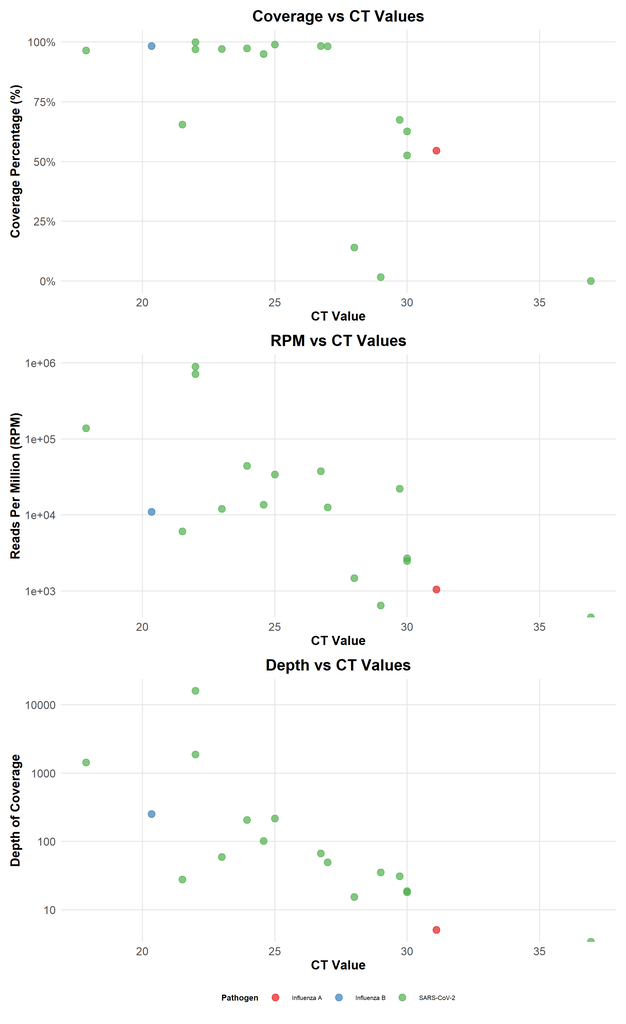

### ROC curves

ROC Performance Metrics

| Metric | AUC |
| --- | --- |
| Genome coverage | 0.9751306 |
| RPM | 0.9768104 |
| Depth | 0.9747574 |

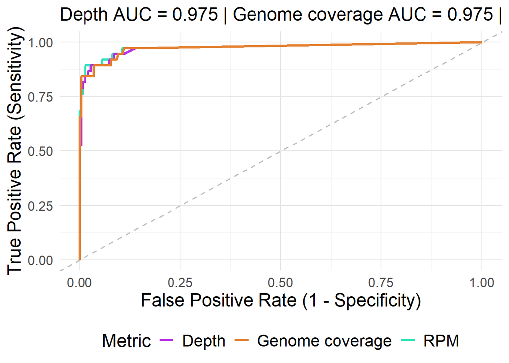

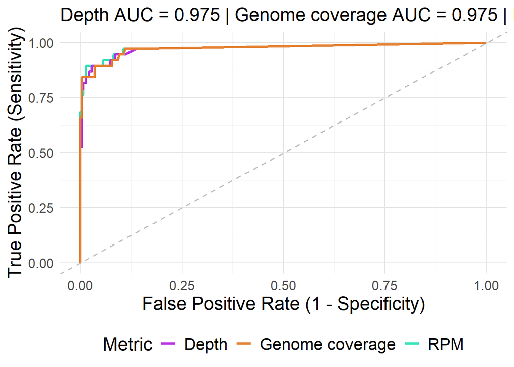

### CT Threshold

#### Coverage Performance (Ct < 30) & removed CT if NA

Coverage Analysis with Ct < 30 Filter

| Threshold | TP | FN | Sensitivity |
| --- | --- | --- | --- |
| cov10 | 13 | 1 | 0.929 |
| cov20 | 12 | 2 | 0.857 |
| cov50 | 12 | 2 | 0.857 |
| cov80 | 10 | 4 | 0.714 |
| cov90 | 10 | 4 | 0.714 |

#### RPM Performance (Ct < 30) & removed CT if NA

RPM Analysis with Ct < 30 Filter

| Threshold | TP | FN | Sensitivity |
| --- | --- | --- | --- |
| rpm10 | 14 | 0 | 1.000 |
| rpm100 | 14 | 0 | 1.000 |
| rpm500 | 14 | 0 | 1.000 |
| rpm1000 | 13 | 1 | 0.929 |

### Error Analysis <30 Coverage

#### False Negatives Samples (coverage)

False Negatives samples for NHLS_GS ( coverage )

| sample_id | Pathogen | PCR_Result | SEQ_Result | Threshold | coverage_percentage | rpm | depth_of_coverage | ct_values |
| --- | --- | --- | --- | --- | --- | --- | --- | --- |
| C070355 | SARS-CoV-2 | 1 | 0 | cov10 | 1.61 | 643.57 | 35.21 | 29.00 |
| C070353 | SARS-CoV-2 | 1 | 0 | cov20 | 14.01 | 1467.93 | 15.46 | 28.00 |
| C071544 | SARS-CoV-2 | 1 | 0 | cov80 | 67.41 | 22113.89 | 30.80 | 29.72 |
| C071546 | SARS-CoV-2 | 1 | 0 | cov80 | 65.39 | 6096.70 | 27.63 | 21.51 |

#### No False Positives Samples found for coverage metric

#### False Negatives Samples (rpm)

False Negatives samples for NHLS_GS ( rpm )

| sample_id | Pathogen | PCR_Result | SEQ_Result | Threshold | coverage_percentage | rpm | depth_of_coverage | ct_values |
| --- | --- | --- | --- | --- | --- | --- | --- | --- |
| C070355 | SARS-CoV-2 | 1 | 0 | rpm1000 | 1.61 | 643.57 | 35.21 | 29 |

#### No False Positives Samples found for rpm metric

## Dataset 3: NHLS TY

### Overview

Basic Statistics for NHLS_TY

| Metric | Value |
| --- | --- |
| Number of unique samples | 47 |
| Number of pathogens | 8 |
| Total observations | 376 |
| PCR detections | 48 |
| PCR non-detections | 303 |

### Performance

#### Coverage Threshold Performance

Coverage Threshold Performance

| Threshold | TP | FN | FP | TN | Sensitivity | Specificity |
| --- | --- | --- | --- | --- | --- | --- |
| cov10 | 46 | 2 | 6 | 297 | 0.958 | 0.980 |
| cov20 | 45 | 3 | 5 | 298 | 0.938 | 0.983 |
| cov50 | 43 | 5 | 3 | 300 | 0.896 | 0.990 |
| cov80 | 39 | 9 | 2 | 301 | 0.812 | 0.993 |
| cov90 | 37 | 11 | 1 | 302 | 0.771 | 0.997 |

#### RPM Threshold Performance

RPM Threshold Performance

| Threshold | TP | FN | FP | TN | Sensitivity | Specificity |
| --- | --- | --- | --- | --- | --- | --- |
| rpm1 | 48 | 0 | 17 | 286 | 1.000 | 0.944 |
| rpm10 | 47 | 1 | 13 | 290 | 0.979 | 0.957 |
| rpm100 | 42 | 6 | 5 | 298 | 0.875 | 0.983 |
| rpm1000 | 35 | 13 | 2 | 301 | 0.729 | 0.993 |

#### Depth Threshold Performance

Depth Threshold Performance

| Threshold | TP | FN | FP | TN | Sensitivity | Specificity |
| --- | --- | --- | --- | --- | --- | --- |
| depth10 | 39 | 9 | 8 | 295 | 0.812 | 0.974 |
| depth30 | 35 | 13 | 8 | 295 | 0.729 | 0.974 |

### Plots (Ct-values)

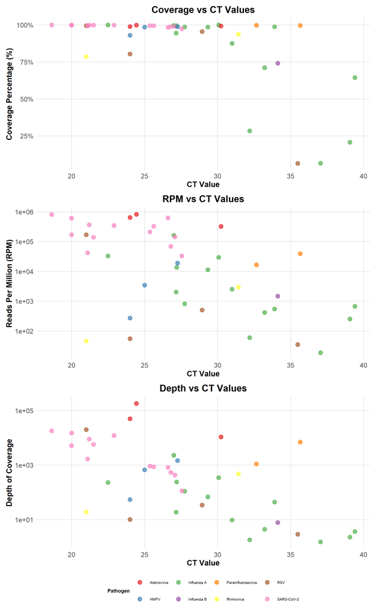

### ROC curves

ROC Performance Metrics

| Metric | AUC |
| --- | --- |
| Genome coverage | 0.9966309 |
| RPM | 0.9949807 |
| Depth | 0.9843922 |

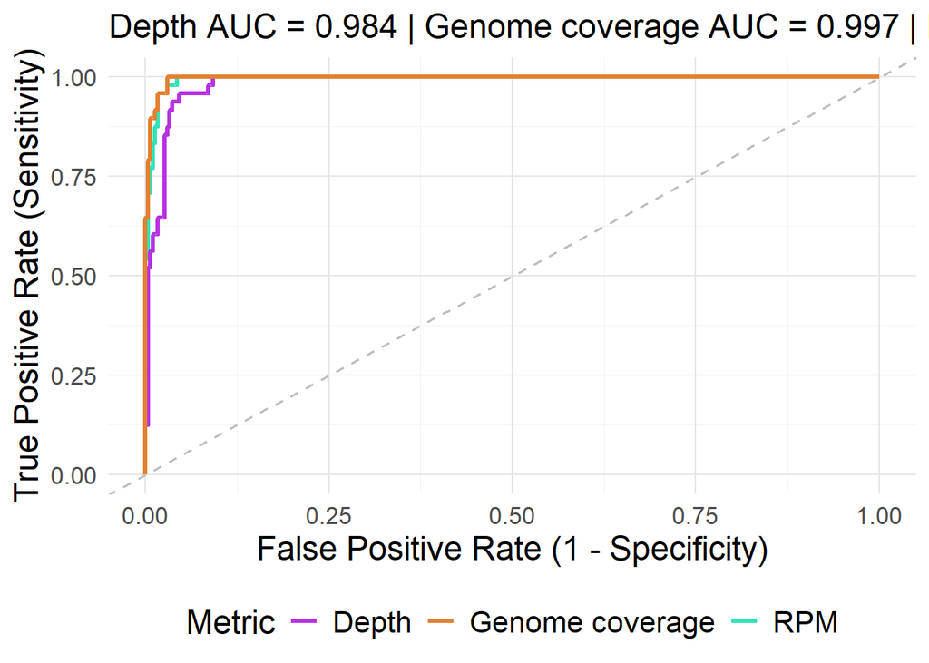

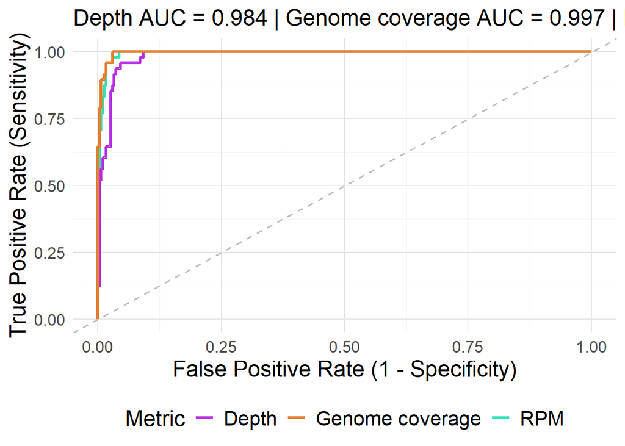

### CT Threshold

#### Coverage Performance (Ct < 30) & removed CT if NA

Coverage Analysis with Ct < 30 Filter

| Threshold | TP | FN | Sensitivity |
| --- | --- | --- | --- |
| cov10 | 28 | 0 | 1.000 |
| cov20 | 28 | 0 | 1.000 |
| cov50 | 28 | 0 | 1.000 |
| cov80 | 27 | 1 | 0.964 |
| cov90 | 26 | 2 | 0.929 |

#### RPM Performance (Ct < 30) & removed CT if NA

RPM Analysis with Ct < 30 Filter

| Threshold | TP | FN | Sensitivity |
| --- | --- | --- | --- |
| rpm10 | 28 | 0 | 1.000 |
| rpm100 | 26 | 2 | 0.929 |
| rpm500 | 25 | 3 | 0.893 |
| rpm1000 | 23 | 5 | 0.821 |

### Error Analysis <30 Coverage

#### False Negatives Samples (coverage)

False Negatives samples for NHLS_TY ( coverage )

| sample_id | Pathogen | PCR_Result | SEQ_Result | Threshold | coverage_percentage | rpm | depth_of_coverage | ct_values |
| --- | --- | --- | --- | --- | --- | --- | --- | --- |
| P004 | Rhinovirus | 1 | 0 | cov80 | 78.62 | 46.36 | 19.04 | 21 |
| P007 | RSV | 1 | 0 | cov90 | 80.45 | 55.29 | 10.23 | 24 |

#### No False Positives Samples found for coverage metric

#### False Negatives Samples (rpm)

False Negatives samples for NHLS_TY ( rpm )

| sample_id | Pathogen | PCR_Result | SEQ_Result | Threshold | coverage_percentage | rpm | depth_of_coverage | ct_values |
| --- | --- | --- | --- | --- | --- | --- | --- | --- |
| P007 | RSV | 1 | 0 | rpm100 | 80.45 | 55.29 | 10.23 | 24.00 |
| P004 | Rhinovirus | 1 | 0 | rpm100 | 78.62 | 46.36 | 19.04 | 21.00 |
| P006 | HMPV | 1 | 0 | rpm1000 | 92.99 | 272.39 | 55.00 | 24.00 |
| ST06926318 | Influenza A | 1 | 0 | rpm1000 | 98.64 | 816.19 | 110.69 | 27.74 |
| C070255 | RSV | 1 | 0 | rpm1000 | 95.59 | 502.50 | 34.53 | 28.94 |

#### No False Positives Samples found for rpm metric

## Dataset 4: Mucokids

### Overview

Basic Statistics for Mucokids

| Metric | Value |
| --- | --- |
| Number of unique samples | 68 |
| Number of pathogens | 8 |
| Total observations | 544 |
| PCR detections | 101 |
| PCR non-detections | 443 |

### Performance

#### Coverage Threshold Performance

Coverage Threshold Performance

| Threshold | TP | FN | FP | TN | Sensitivity | Specificity |
| --- | --- | --- | --- | --- | --- | --- |
| cov10 | 89 | 12 | 4 | 439 | 0.881 | 0.991 |
| cov20 | 86 | 15 | 3 | 440 | 0.851 | 0.993 |
| cov50 | 74 | 27 | 2 | 441 | 0.733 | 0.995 |
| cov80 | 68 | 33 | 2 | 441 | 0.673 | 0.995 |
| cov90 | 61 | 40 | 2 | 441 | 0.604 | 0.995 |

#### RPM Threshold Performance

RPM Threshold Performance

| Threshold | TP | FN | FP | TN | Sensitivity | Specificity |
| --- | --- | --- | --- | --- | --- | --- |
| rpm1 | 95 | 6 | 12 | 431 | 0.941 | 0.973 |
| rpm10 | 83 | 18 | 5 | 438 | 0.822 | 0.989 |
| rpm100 | 71 | 30 | 3 | 440 | 0.703 | 0.993 |
| rpm1000 | 60 | 41 | 3 | 440 | 0.594 | 0.993 |

#### Depth Threshold Performance

Depth Threshold Performance

| Threshold | TP | FN | FP | TN | Sensitivity | Specificity |
| --- | --- | --- | --- | --- | --- | --- |
| depth10 | 73 | 28 | 5 | 438 | 0.723 | 0.989 |
| depth30 | 68 | 33 | 5 | 438 | 0.673 | 0.989 |

### Plots (Ct-values)

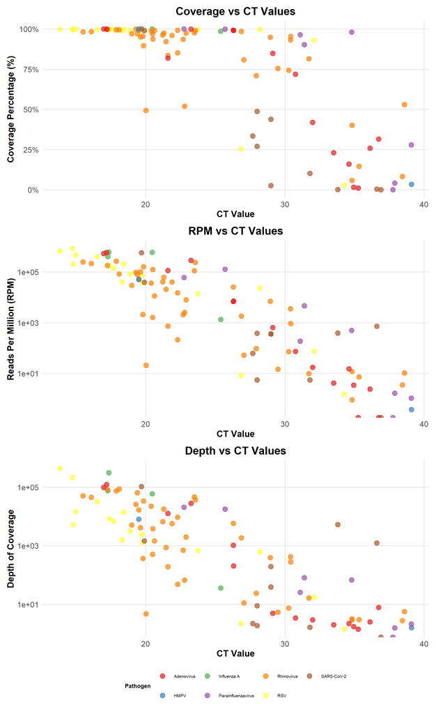

### ROC curves

ROC Performance Metrics

| Metric | AUC |
| --- | --- |
| Genome coverage | 0.9796728 |
| RPM | 0.9704423 |
| Depth | 0.9760409 |

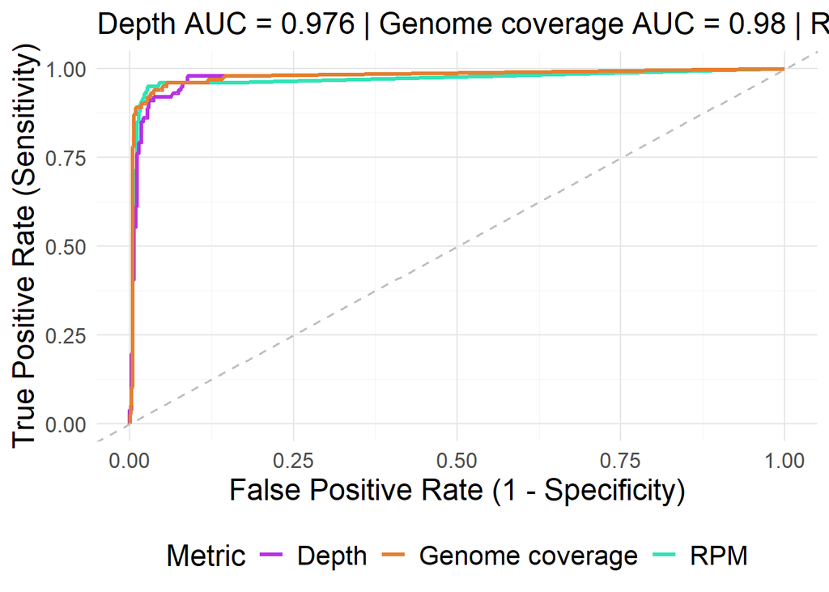

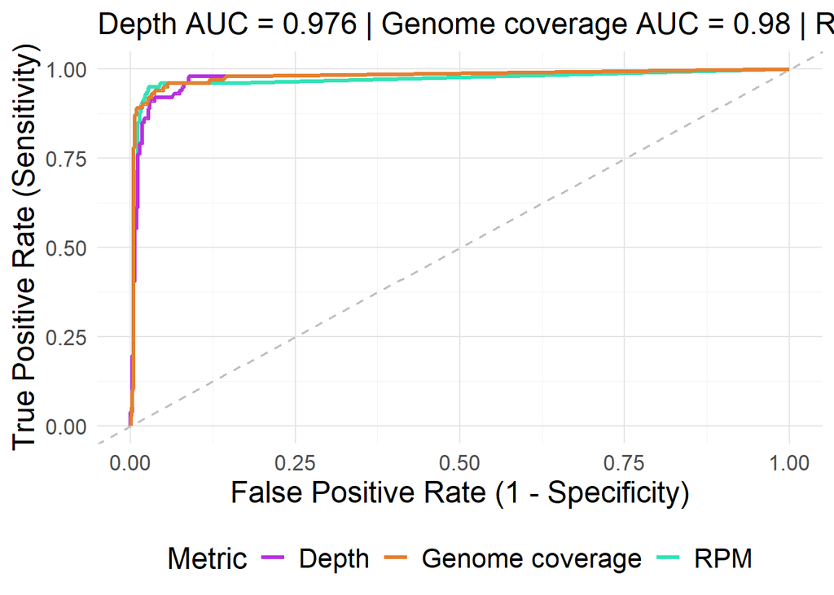

### CT Threshold

#### Coverage Performance (Ct < 30) & removed CT if NA

Coverage Analysis with Ct < 30 Filter

| Threshold | TP | FN | Sensitivity |
| --- | --- | --- | --- |
| cov10 | 70 | 1 | 0.986 |
| cov20 | 70 | 1 | 0.986 |
| cov50 | 64 | 7 | 0.901 |
| cov80 | 61 | 10 | 0.859 |
| cov90 | 55 | 16 | 0.775 |

#### RPM Performance (Ct < 30) & removed CT if NA

RPM Analysis with Ct < 30 Filter

| Threshold | TP | FN | Sensitivity |
| --- | --- | --- | --- |
| rpm10 | 69 | 2 | 0.972 |
| rpm100 | 64 | 7 | 0.901 |
| rpm500 | 60 | 11 | 0.845 |
| rpm1000 | 58 | 13 | 0.817 |

### Error Analysis <30 Coverage

#### False Negatives Samples (coverage)

False Negatives samples for Mucokids ( coverage )

| sample_id | Pathogen | PCR_Result | SEQ_Result | Threshold | coverage_percentage | rpm | depth_of_coverage | ct_values |
| --- | --- | --- | --- | --- | --- | --- | --- | --- |
| C066716 | SARS-CoV-2 | 1 | 0 | cov10 | 2.5400 | 361.11 | 195.08000 | 29.00 |
| C069869 | RSV | 1 | 0 | cov50 | 25.4900 | 8.34 | 2.21000 | 26.87 |
| C069883 | Rhinovirus | 1 | 0 | cov50 | 49.4100 | 21.09 | 4.77000 | 20.02 |
| C066718 | SARS-CoV-2 | 1 | 0 | cov50 | 43.8600 | 363.13 | 39.44000 | 29.00 |
| C066740 | SARS-CoV-2 | 1 | 0 | cov50 | 48.7900 | 381.99 | 8.94000 | 28.00 |
| C066742_S1 | SARS-CoV-2 | 1 | 0 | cov50 | 26.9500 | 5.48 | 1.88000 | 28.00 |
| C066746_S5 | SARS-CoV-2 | 1 | 0 | cov50 | 33.4400 | 61.78 | 2.21000 | 27.70 |
| C066721 | Rhinovirus | 1 | 0 | cov80 | 51.9700 | 2530.55 | 66.96000 | 22.80 |
| C066726 | Rhinovirus | 1 | 0 | cov80 | 75.4400 | 14.65 | 5.44000 | 29.50 |
| C066755_S14 | Rhinovirus | 1 | 0 | cov80 | 70.9172 | 96.30 | 24.30777 | 27.95 |
| C066727 | Adenovirus | 1 | 0 | cov90 | 81.9400 | 113888.81 | 12635.94000 | 21.60 |
| C066744_S3 | Adenovirus | 1 | 0 | cov90 | 84.8300 | 644.60 | 5.03000 | 29.13 |
| C066716 | Rhinovirus | 1 | 0 | cov90 | 83.5400 | 738.25 | 192.10000 | 21.60 |
| C066725 | Rhinovirus | 1 | 0 | cov90 | 85.2200 | 214.14 | 48.28000 | 22.30 |
| C066743_S2 | Rhinovirus | 1 | 0 | cov90 | 89.6500 | 160165.02 | 33480.76000 | 19.85 |
| C066760_S19 | Rhinovirus | 1 | 0 | cov90 | 80.8300 | 52.37 | 11.22000 | 27.05 |

#### No False Positives Samples found for coverage metric

#### False Negatives Samples (rpm)

False Negatives samples for Mucokids ( rpm )

| sample_id | Pathogen | PCR_Result | SEQ_Result | Threshold | coverage_percentage | rpm | depth_of_coverage | ct_values |
| --- | --- | --- | --- | --- | --- | --- | --- | --- |
| C069869 | RSV | 1 | 0 | rpm10 | 25.4900 | 8.34 | 2.21000 | 26.87 |
| C066742_S1 | SARS-CoV-2 | 1 | 0 | rpm10 | 26.9500 | 5.48 | 1.88000 | 28.00 |
| C066726 | Rhinovirus | 1 | 0 | rpm100 | 75.4400 | 14.65 | 5.44000 | 29.50 |
| C066755_S14 | Rhinovirus | 1 | 0 | rpm100 | 70.9172 | 96.30 | 24.30777 | 27.95 |
| C066760_S19 | Rhinovirus | 1 | 0 | rpm100 | 80.8300 | 52.37 | 11.22000 | 27.05 |
| C069883 | Rhinovirus | 1 | 0 | rpm100 | 49.4100 | 21.09 | 4.77000 | 20.02 |
| C066746_S5 | SARS-CoV-2 | 1 | 0 | rpm100 | 33.4400 | 61.78 | 2.21000 | 27.70 |
| C066744_S3 | Adenovirus | 1 | 0 | rpm1000 | 84.8300 | 644.60 | 5.03000 | 29.13 |
| C066716 | Rhinovirus | 1 | 0 | rpm1000 | 83.5400 | 738.25 | 192.10000 | 21.60 |
| C066725 | Rhinovirus | 1 | 0 | rpm1000 | 85.2200 | 214.14 | 48.28000 | 22.30 |
| C066716 | SARS-CoV-2 | 1 | 0 | rpm1000 | 2.5400 | 361.11 | 195.08000 | 29.00 |
| C066718 | SARS-CoV-2 | 1 | 0 | rpm1000 | 43.8600 | 363.13 | 39.44000 | 29.00 |
| C066740 | SARS-CoV-2 | 1 | 0 | rpm1000 | 48.7900 | 381.99 | 8.94000 | 28.00 |

#### No False Positives Samples found for rpm metric

## Dataset 5: SUDI

### Overview

Basic Statistics for SUDI

| Metric | Value |
| --- | --- |
| Number of unique samples | 64 |
| Number of pathogens | 7 |
| Total observations | 512 |
| PCR detections | 42 |
| PCR non-detections | 406 |

### Performance

#### Coverage Threshold Performance

Coverage Threshold Performance

| Threshold | TP | FN | FP | TN | Sensitivity | Specificity |
| --- | --- | --- | --- | --- | --- | --- |
| cov10 | 25 | 17 | 1 | 405 | 0.595 | 0.998 |
| cov20 | 24 | 18 | 0 | 406 | 0.571 | 1.000 |
| cov50 | 24 | 18 | 0 | 406 | 0.571 | 1.000 |
| cov80 | 20 | 22 | 0 | 406 | 0.476 | 1.000 |
| cov90 | 18 | 24 | 0 | 406 | 0.429 | 1.000 |

#### RPM Threshold Performance

RPM Threshold Performance

| Threshold | TP | FN | FP | TN | Sensitivity | Specificity |
| --- | --- | --- | --- | --- | --- | --- |
| rpm1 | 28 | 14 | 6 | 400 | 0.667 | 0.985 |
| rpm10 | 24 | 18 | 1 | 405 | 0.571 | 0.998 |
| rpm100 | 21 | 21 | 0 | 406 | 0.500 | 1.000 |
| rpm1000 | 12 | 30 | 0 | 406 | 0.286 | 1.000 |

#### Depth Threshold Performance

Depth Threshold Performance

| Threshold | TP | FN | FP | TN | Sensitivity | Specificity |
| --- | --- | --- | --- | --- | --- | --- |
| depth10 | 19 | 23 | 1 | 405 | 0.452 | 0.998 |
| depth30 | 15 | 27 | 1 | 405 | 0.357 | 0.998 |

### Plots (Ct-values)

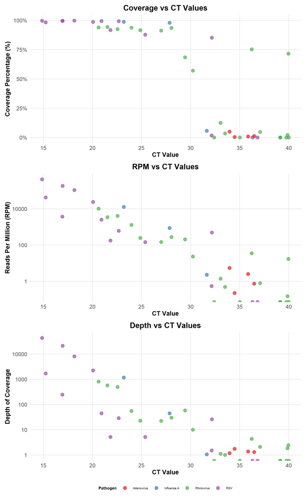

### ROC curves

ROC Performance Metrics

| Metric | AUC |
| --- | --- |
| Genome coverage | 0.8883122 |
| RPM | 0.8897197 |
| Depth | 0.8891919 |

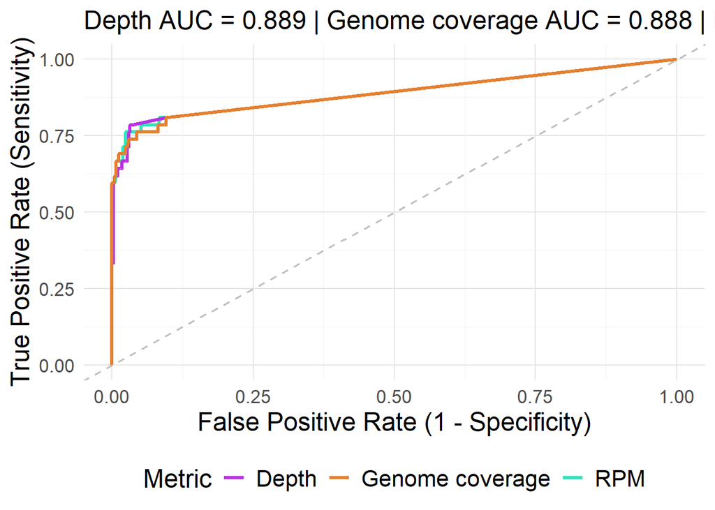

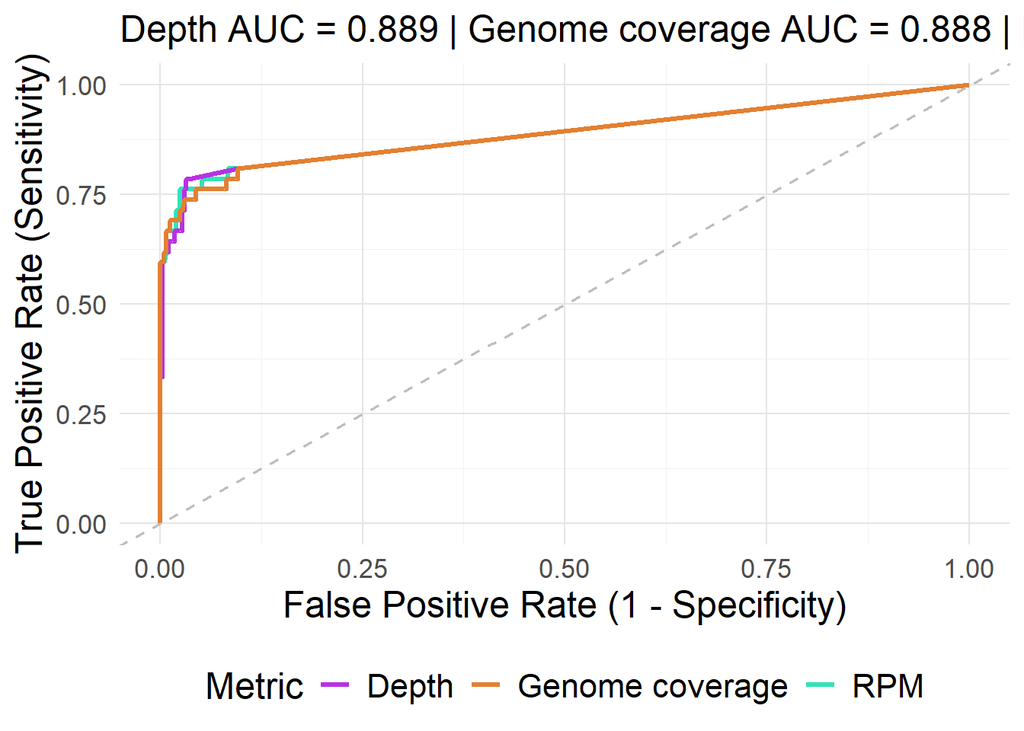

### CT Threshold

#### Coverage Performance (Ct < 30) & removed CT if NA

Coverage Analysis with Ct < 30 Filter

| Threshold | TP | FN | Sensitivity |
| --- | --- | --- | --- |
| cov10 | 20 | 0 | 1.00 |
| cov20 | 20 | 0 | 1.00 |
| cov50 | 20 | 0 | 1.00 |
| cov80 | 19 | 1 | 0.95 |
| cov90 | 18 | 2 | 0.90 |

#### RPM Performance (Ct < 30) & removed CT if NA

RPM Analysis with Ct < 30 Filter

| Threshold | TP | FN | Sensitivity |
| --- | --- | --- | --- |
| rpm10 | 20 | 0 | 1.0 |
| rpm100 | 20 | 0 | 1.0 |
| rpm500 | 14 | 6 | 0.7 |
| rpm1000 | 12 | 8 | 0.6 |

### Error Analysis <30 Coverage

#### False Negatives Samples (coverage)

False Negatives samples for SUDI ( coverage )

| sample_id | Pathogen | PCR_Result | SEQ_Result | Threshold | coverage_percentage | rpm | depth_of_coverage | ct_values |
| --- | --- | --- | --- | --- | --- | --- | --- | --- |
| C069911 | Rhinovirus | 1 | 0 | cov80 | 68.4400 | 205.8500 | 58.080000 | 29.44 |
| C071444 | RSV | 1 | 0 | cov90 | 87.7559 | 144.3549 | 5.182882 | 25.37 |

#### No False Positives Samples found for coverage metric

#### False Negatives Samples (rpm)

False Negatives samples for SUDI ( rpm )

| sample_id | Pathogen | PCR_Result | SEQ_Result | Threshold | coverage_percentage | rpm | depth_of_coverage | ct_values |
| --- | --- | --- | --- | --- | --- | --- | --- | --- |
| C069908 | Influenza A | 1 | 0 | rpm1000 | 97.9200 | 869.5400 | 44.320000 | 27.86 |
| C071441 | RSV | 1 | 0 | rpm1000 | 99.2298 | 604.5287 | 28.725952 | 22.67 |
| C071444 | RSV | 1 | 0 | rpm1000 | 87.7559 | 144.3549 | 5.182882 | 25.37 |
| C071452 | RSV | 1 | 0 | rpm1000 | 91.6859 | 176.3370 | 5.185526 | 21.83 |
| C069911 | Rhinovirus | 1 | 0 | rpm1000 | 68.4400 | 205.8500 | 58.080000 | 29.44 |
| C071415b | Rhinovirus | 1 | 0 | rpm1000 | 91.1913 | 147.5034 | 22.473628 | 27.00 |
| C071421 | Rhinovirus | 1 | 0 | rpm1000 | 91.5058 | 245.8167 | 22.546490 | 24.88 |
| C071441 | Rhinovirus | 1 | 0 | rpm1000 | 93.5625 | 275.3815 | 30.088377 | 28.04 |

#### No False Positives Samples found for rpm metric

## Dataset 6: ALL Samples

### Overview

Basic Statistics for ALL_COMBINED

| Metric | Value |
| --- | --- |
| Number of unique samples | 479 |
| Number of pathogens | 8 |
| Total observations | 3832 |
| PCR detections | 511 |
| PCR non-detections | 2295 |

### Performance

#### Coverage Threshold Performance

Coverage Threshold Performance

| Threshold | TP | FN | FP | TN | Sensitivity | Specificity |
| --- | --- | --- | --- | --- | --- | --- |
| cov10 | 417 | 94 | 92 | 2203 | 0.816 | 0.960 |
| cov20 | 397 | 114 | 54 | 2241 | 0.777 | 0.976 |
| cov50 | 358 | 153 | 16 | 2279 | 0.701 | 0.993 |
| cov80 | 320 | 191 | 8 | 2287 | 0.626 | 0.997 |
| cov90 | 294 | 217 | 5 | 2290 | 0.575 | 0.998 |

#### RPM Threshold Performance

RPM Threshold Performance

| Threshold | TP | FN | FP | TN | Sensitivity | Specificity |
| --- | --- | --- | --- | --- | --- | --- |
| rpm1 | 452 | 59 | 242 | 2053 | 0.885 | 0.895 |
| rpm10 | 427 | 84 | 144 | 2151 | 0.836 | 0.937 |
| rpm100 | 381 | 130 | 65 | 2230 | 0.746 | 0.972 |
| rpm1000 | 310 | 201 | 25 | 2270 | 0.607 | 0.989 |

#### Depth Threshold Performance

Depth Threshold Performance

| Threshold | TP | FN | FP | TN | Sensitivity | Specificity |
| --- | --- | --- | --- | --- | --- | --- |
| depth10 | 360 | 151 | 48 | 2247 | 0.705 | 0.979 |
| depth30 | 309 | 202 | 46 | 2249 | 0.605 | 0.980 |

### Plots (Ct-values)

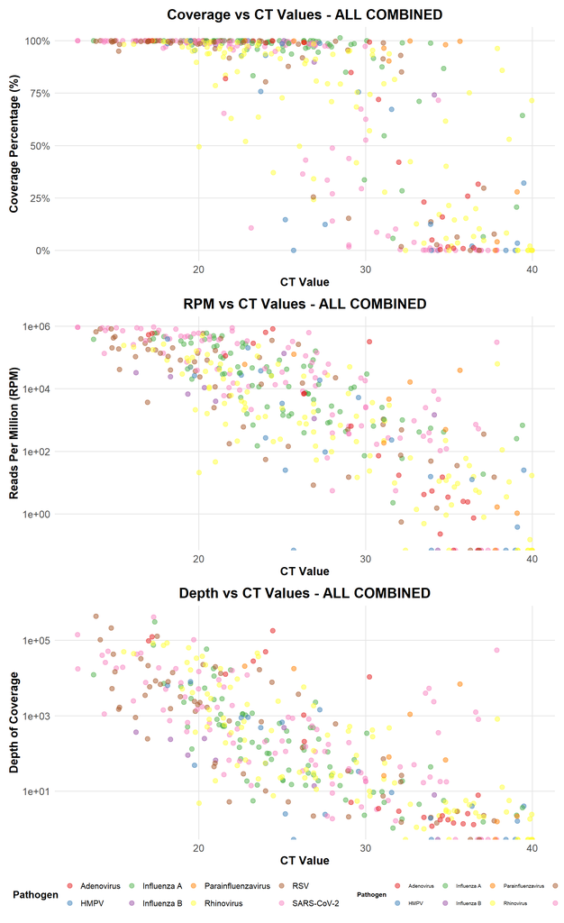

### ROC curves

ROC Performance Metrics

| Metric | AUC |
| --- | --- |
| Genome coverage | 0.9384107 |
| RPM | 0.9336919 |
| Depth | 0.9314932 |

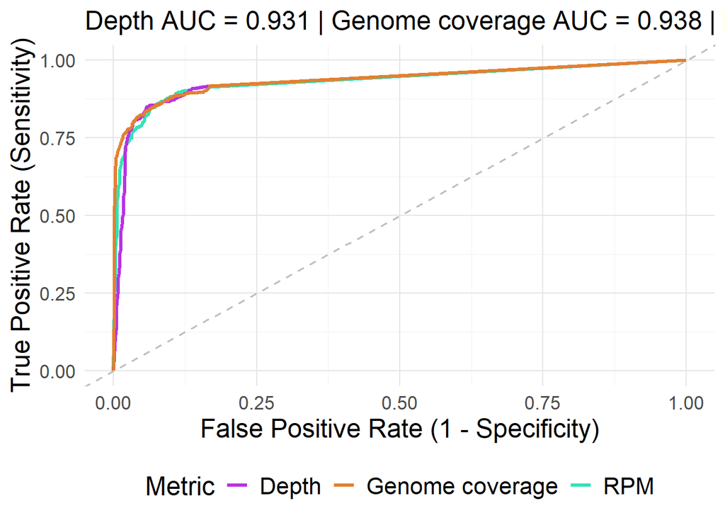

Plot saved to: figures/ROC_ALL_COMBINED.png

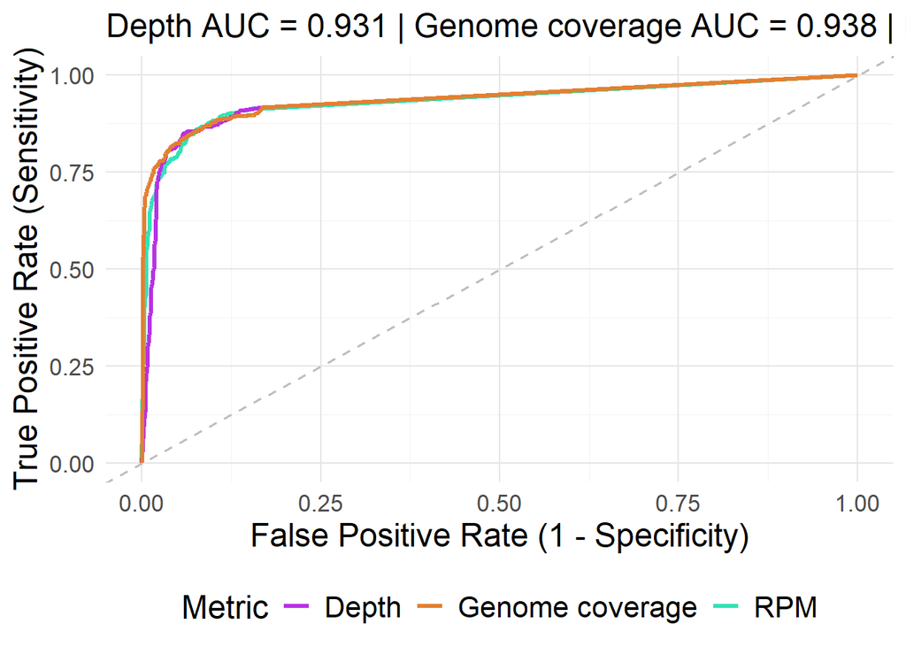

### CT Threshold

#### Coverage Performance (Ct < 30) & removed CT if NA

Coverage Analysis with Ct < 30 Filter - ALL COMBINED

| Threshold | TP | FN | Sensitivity |
| --- | --- | --- | --- |
| cov10 | 270 | 3 | 0.989 |
| cov20 | 265 | 8 | 0.971 |
| cov50 | 250 | 23 | 0.916 |
| cov80 | 236 | 37 | 0.864 |
| cov90 | 224 | 49 | 0.821 |

#### RPM Performance (Ct < 30) & removed CT if NA

RPM Analysis with Ct < 30 Filter - ALL COMBINED

| Threshold | TP | FN | Sensitivity |
| --- | --- | --- | --- |
| rpm10 | 270 | 3 | 0.989 |
| rpm100 | 259 | 14 | 0.949 |
| rpm500 | 243 | 30 | 0.890 |
| rpm1000 | 231 | 42 | 0.846 |

### Error Analysis <30 Coverage

#### False Negatives Samples (coverage)

False Negatives samples for ALL_COMBINED ( coverage )

| sample_id | Pathogen | PCR_Result | SEQ_Result | Threshold | coverage_percentage | rpm | depth_of_coverage | ct_values |
| --- | --- | --- | --- | --- | --- | --- | --- | --- |
| C070882 | HMPV | 1 | 0 | cov10 | 0.00000 | 0.00000 | 0.000000 | 25.68 |
| C066716 | SARS-CoV-2 | 1 | 0 | cov10 | 2.54000 | 361.11000 | 195.080000 | 29.00 |
| C070355 | SARS-CoV-2 | 1 | 0 | cov10 | 1.61000 | 643.57000 | 35.210000 | 29.00 |
| C070885 | HMPV | 1 | 0 | cov20 | 12.41000 | 95.80000 | 2.410000 | 27.57 |
| C071521 | HMPV | 1 | 0 | cov20 | 14.59000 | 25.24000 | 2.500000 | 25.18 |
| C070872 | RSV | 1 | 0 | cov20 | 15.24000 | 15.01000 | 2.090000 | 28.99 |
| C070353 | SARS-CoV-2 | 1 | 0 | cov20 | 14.01000 | 1467.93000 | 15.460000 | 28.00 |
| C070398 | SARS-CoV-2 | 1 | 0 | cov20 | 10.63000 | 2158.36000 | 14.080000 | 23.14 |
| VCS-C073372 | Influenza A | 1 | 0 | cov50 | 33.68313 | 72.54729 | 2.317429 | 29.92 |
| C069869 | RSV | 1 | 0 | cov50 | 25.49000 | 8.34000 | 2.210000 | 26.87 |
| C069883 | Rhinovirus | 1 | 0 | cov50 | 49.41000 | 21.09000 | 4.770000 | 20.02 |
| C070383 | Rhinovirus | 1 | 0 | cov50 | 37.03000 | 203.76000 | 7.650000 | 24.47 |
| C071075 | Rhinovirus | 1 | 0 | cov50 | 49.73000 | 792.69000 | 32.050000 | 26.04 |
| C071083 | Rhinovirus | 1 | 0 | cov50 | 24.15000 | 417.29000 | 30.130000 | 26.89 |
| C071084 | Rhinovirus | 1 | 0 | cov50 | 34.19000 | 3314.73000 | 119.970000 | 26.89 |
| C071521 | Rhinovirus | 1 | 0 | cov50 | 41.74000 | 1318.41000 | 88.510000 | 29.44 |
| C066718 | SARS-CoV-2 | 1 | 0 | cov50 | 43.86000 | 363.13000 | 39.440000 | 29.00 |
| C066740 | SARS-CoV-2 | 1 | 0 | cov50 | 48.79000 | 381.99000 | 8.940000 | 28.00 |
| C066742_S1 | SARS-CoV-2 | 1 | 0 | cov50 | 26.95000 | 5.48000 | 1.880000 | 28.00 |
| C066746_S5 | SARS-CoV-2 | 1 | 0 | cov50 | 33.44000 | 61.78000 | 2.210000 | 27.70 |
| C070400 | SARS-CoV-2 | 1 | 0 | cov50 | 29.40000 | 654.04000 | 3.830000 | 29.75 |
| C070870 | SARS-CoV-2 | 1 | 0 | cov50 | 36.45000 | 8497.81000 | 34.740000 | 26.23 |
| C071502 | SARS-CoV-2 | 1 | 0 | cov50 | 43.07000 | 114400.80000 | 151.810000 | 26.41 |
| C071072 | HMPV | 1 | 0 | cov80 | 75.75000 | 37619.98000 | 482.840000 | 23.72 |
| C071076 | HMPV | 1 | 0 | cov80 | 75.51000 | 5277.15000 | 33.600000 | 29.58 |
| C066721 | Rhinovirus | 1 | 0 | cov80 | 51.97000 | 2530.55000 | 66.960000 | 22.80 |
| C066726 | Rhinovirus | 1 | 0 | cov80 | 75.44000 | 14.65000 | 5.440000 | 29.50 |
| C066755_S14 | Rhinovirus | 1 | 0 | cov80 | 70.91720 | 96.30000 | 24.307768 | 27.95 |
| C069911 | Rhinovirus | 1 | 0 | cov80 | 68.44000 | 205.85000 | 58.080000 | 29.44 |
| C070330 | Rhinovirus | 1 | 0 | cov80 | 62.97000 | 6159.50000 | 357.340000 | 21.93 |
| C070881 | Rhinovirus | 1 | 0 | cov80 | 63.60000 | 1195.86000 | 21.250000 | 23.57 |
| C070886 | Rhinovirus | 1 | 0 | cov80 | 72.76000 | 2469.07000 | 23.980000 | 25.00 |
| C071082 | Rhinovirus | 1 | 0 | cov80 | 79.49000 | 27450.51000 | 305.830000 | 27.72 |
| C071086 | Rhinovirus | 1 | 0 | cov80 | 79.31000 | 679.26000 | 25.600000 | 28.48 |
| P004 | Rhinovirus | 1 | 0 | cov80 | 78.62000 | 46.36000 | 19.040000 | 21.00 |
| C071544 | SARS-CoV-2 | 1 | 0 | cov80 | 67.41000 | 22113.89000 | 30.800000 | 29.72 |
| C071546 | SARS-CoV-2 | 1 | 0 | cov80 | 65.39000 | 6096.70000 | 27.630000 | 21.51 |
| C066727 | Adenovirus | 1 | 0 | cov90 | 81.94000 | 113888.81000 | 12635.940000 | 21.60 |
| C066744_S3 | Adenovirus | 1 | 0 | cov90 | 84.83000 | 644.60000 | 5.030000 | 29.13 |
| C070389 | Influenza A | 1 | 0 | cov90 | 83.32000 | 701.69000 | 5.600000 | 23.25 |
| VCS-C073441 | Influenza A | 1 | 0 | cov90 | 84.97835 | 431.45309 | 5.864767 | 28.81 |
| C070321 | Influenza B | 1 | 0 | cov90 | 89.84000 | 1119.63000 | 13.770000 | 26.91 |
| C071444 | RSV | 1 | 0 | cov90 | 87.75590 | 144.35488 | 5.182882 | 25.37 |
| P007 | RSV | 1 | 0 | cov90 | 80.45000 | 55.29000 | 10.230000 | 24.00 |
| C066716 | Rhinovirus | 1 | 0 | cov90 | 83.54000 | 738.25000 | 192.100000 | 21.60 |
| C066725 | Rhinovirus | 1 | 0 | cov90 | 85.22000 | 214.14000 | 48.280000 | 22.30 |
| C066743_S2 | Rhinovirus | 1 | 0 | cov90 | 89.65000 | 160165.02000 | 33480.760000 | 19.85 |
| C066760_S19 | Rhinovirus | 1 | 0 | cov90 | 80.83000 | 52.37000 | 11.220000 | 27.05 |
| C070883 | Rhinovirus | 1 | 0 | cov90 | 89.07000 | 1226.94000 | 22.530000 | 26.36 |

#### No False Positives Samples found for coverage metric

#### False Negatives Samples (rpm)

False Negatives samples for ALL_COMBINED ( rpm )

| sample_id | Pathogen | PCR_Result | SEQ_Result | Threshold | coverage_percentage | rpm | depth_of_coverage | ct_values |
| --- | --- | --- | --- | --- | --- | --- | --- | --- |
| C070882 | HMPV | 1 | 0 | rpm1 | 0.00000 | 0.00000 | 0.000000 | 25.68 |
| C069869 | RSV | 1 | 0 | rpm10 | 25.49000 | 8.34000 | 2.210000 | 26.87 |
| C066742_S1 | SARS-CoV-2 | 1 | 0 | rpm10 | 26.95000 | 5.48000 | 1.880000 | 28.00 |
| C070885 | HMPV | 1 | 0 | rpm100 | 12.41000 | 95.80000 | 2.410000 | 27.57 |
| C071521 | HMPV | 1 | 0 | rpm100 | 14.59000 | 25.24000 | 2.500000 | 25.18 |
| VCS-C073372 | Influenza A | 1 | 0 | rpm100 | 33.68313 | 72.54729 | 2.317429 | 29.92 |
| C070872 | RSV | 1 | 0 | rpm100 | 15.24000 | 15.01000 | 2.090000 | 28.99 |
| P007 | RSV | 1 | 0 | rpm100 | 80.45000 | 55.29000 | 10.230000 | 24.00 |
| C066726 | Rhinovirus | 1 | 0 | rpm100 | 75.44000 | 14.65000 | 5.440000 | 29.50 |
| C066755_S14 | Rhinovirus | 1 | 0 | rpm100 | 70.91720 | 96.30000 | 24.307768 | 27.95 |
| C066760_S19 | Rhinovirus | 1 | 0 | rpm100 | 80.83000 | 52.37000 | 11.220000 | 27.05 |
| C069883 | Rhinovirus | 1 | 0 | rpm100 | 49.41000 | 21.09000 | 4.770000 | 20.02 |
| P004 | Rhinovirus | 1 | 0 | rpm100 | 78.62000 | 46.36000 | 19.040000 | 21.00 |
| C066746_S5 | SARS-CoV-2 | 1 | 0 | rpm100 | 33.44000 | 61.78000 | 2.210000 | 27.70 |
| C066744_S3 | Adenovirus | 1 | 0 | rpm1000 | 84.83000 | 644.60000 | 5.030000 | 29.13 |
| P006 | HMPV | 1 | 0 | rpm1000 | 92.99000 | 272.39000 | 55.000000 | 24.00 |
| C069908 | Influenza A | 1 | 0 | rpm1000 | 97.92000 | 869.54000 | 44.320000 | 27.86 |
| C070389 | Influenza A | 1 | 0 | rpm1000 | 83.32000 | 701.69000 | 5.600000 | 23.25 |
| C071112b | Influenza A | 1 | 0 | rpm1000 | 96.00000 | 150.48649 | 14.477475 | 23.50 |
| C071135b | Influenza A | 1 | 0 | rpm1000 | 99.96200 | 390.86882 | 123.216072 | 26.31 |
| ST06926318 | Influenza A | 1 | 0 | rpm1000 | 98.64000 | 816.19000 | 110.690000 | 27.74 |
| VCS-C073441 | Influenza A | 1 | 0 | rpm1000 | 84.97835 | 431.45309 | 5.864767 | 28.81 |
| C070255 | RSV | 1 | 0 | rpm1000 | 95.59000 | 502.50000 | 34.530000 | 28.94 |
| C071441 | RSV | 1 | 0 | rpm1000 | 99.22980 | 604.52869 | 28.725952 | 22.67 |
| C071444 | RSV | 1 | 0 | rpm1000 | 87.75590 | 144.35488 | 5.182882 | 25.37 |
| C071452 | RSV | 1 | 0 | rpm1000 | 91.68590 | 176.33704 | 5.185526 | 21.83 |
| C066716 | Rhinovirus | 1 | 0 | rpm1000 | 83.54000 | 738.25000 | 192.100000 | 21.60 |
| C066725 | Rhinovirus | 1 | 0 | rpm1000 | 85.22000 | 214.14000 | 48.280000 | 22.30 |
| C069911 | Rhinovirus | 1 | 0 | rpm1000 | 68.44000 | 205.85000 | 58.080000 | 29.44 |
| C070383 | Rhinovirus | 1 | 0 | rpm1000 | 37.03000 | 203.76000 | 7.650000 | 24.47 |
| C071075 | Rhinovirus | 1 | 0 | rpm1000 | 49.73000 | 792.69000 | 32.050000 | 26.04 |
| C071080 | Rhinovirus | 1 | 0 | rpm1000 | 90.62000 | 746.86000 | 37.550000 | 26.43 |
| C071083 | Rhinovirus | 1 | 0 | rpm1000 | 24.15000 | 417.29000 | 30.130000 | 26.89 |
| C071086 | Rhinovirus | 1 | 0 | rpm1000 | 79.31000 | 679.26000 | 25.600000 | 28.48 |
| C071415b | Rhinovirus | 1 | 0 | rpm1000 | 91.19130 | 147.50340 | 22.473628 | 27.00 |
| C071421 | Rhinovirus | 1 | 0 | rpm1000 | 91.50580 | 245.81668 | 22.546490 | 24.88 |
| C071441 | Rhinovirus | 1 | 0 | rpm1000 | 93.56250 | 275.38147 | 30.088377 | 28.04 |
| C066716 | SARS-CoV-2 | 1 | 0 | rpm1000 | 2.54000 | 361.11000 | 195.080000 | 29.00 |
| C066718 | SARS-CoV-2 | 1 | 0 | rpm1000 | 43.86000 | 363.13000 | 39.440000 | 29.00 |
| C066740 | SARS-CoV-2 | 1 | 0 | rpm1000 | 48.79000 | 381.99000 | 8.940000 | 28.00 |
| C070355 | SARS-CoV-2 | 1 | 0 | rpm1000 | 1.61000 | 643.57000 | 35.210000 | 29.00 |
| C070400 | SARS-CoV-2 | 1 | 0 | rpm1000 | 29.40000 | 654.04000 | 3.830000 | 29.75 |

#### No False Positives Samples found for rpm metric

## Cross-Dataset Analysis

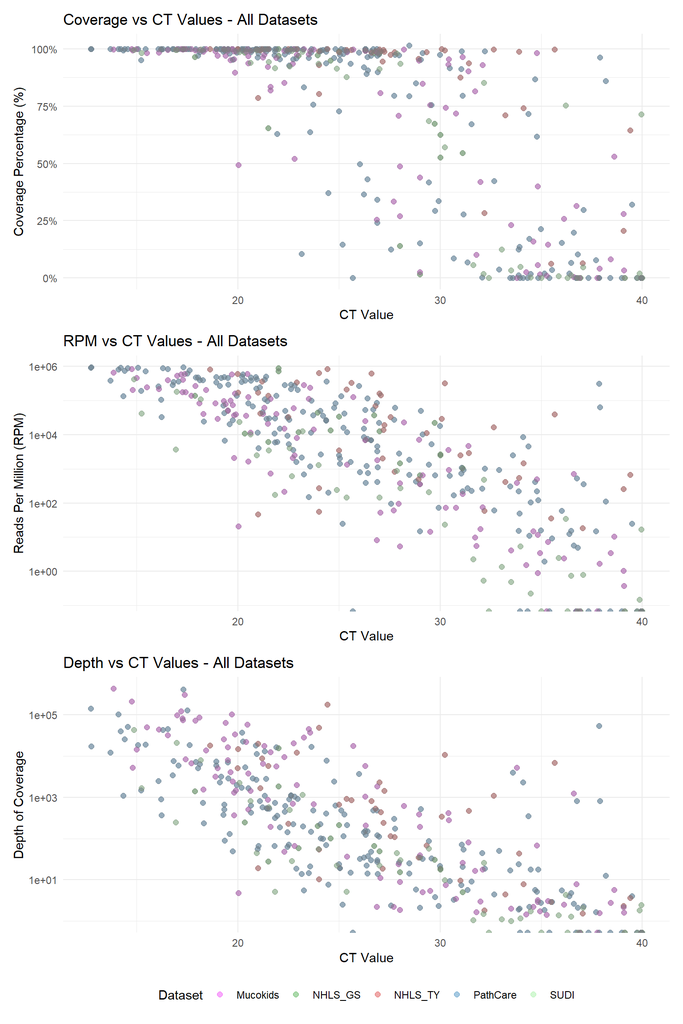

## Error Analysis

### Dataset 1: Pathcare

#### False Negatives Samples (coverage)

False Negatives samples for PathCare ( coverage )

| sample_id | Pathogen | PCR_Result | SEQ_Result | Threshold | coverage_percentage | rpm | depth_of_coverage | ct_values |
| --- | --- | --- | --- | --- | --- | --- | --- | --- |
| C070329 | HMPV | 1 | 0 | cov10 | 0.000000 | 0.000000e+00 | 0.000000 | 38.98 |
| C070372 | HMPV | 1 | 0 | cov10 | 0.000000 | 0.000000e+00 | 0.000000 | NA |
| C070384 | HMPV | 1 | 0 | cov10 | 0.000000 | 0.000000e+00 | 0.000000 | 38.42 |
| C070393 | HMPV | 1 | 0 | cov10 | 0.000000 | 0.000000e+00 | 0.000000 | NA |
| C070879 | HMPV | 1 | 0 | cov10 | 0.000000 | 0.000000e+00 | 0.000000 | 33.94 |
| C070882 | HMPV | 1 | 0 | cov10 | 0.000000 | 0.000000e+00 | 0.000000 | 25.68 |
| C071107 | HMPV | 1 | 0 | cov10 | 0.000000 | 0.000000e+00 | 0.000000 | NA |
| C071139 | HMPV | 1 | 0 | cov10 | 2.040000 | 1.247000e+01 | 4.000000 | 36.38 |
| C071160 | Influenza A | 1 | 0 | cov10 | 0.000000 | 0.000000e+00 | 0.000000 | NA |
| C071494 | Influenza B | 1 | 0 | cov10 | 0.000000 | 0.000000e+00 | 0.000000 | 34.33 |
| C071497 | Influenza B | 1 | 0 | cov10 | 4.690000 | 1.125000e+01 | 1.400000 | NA |
| C070253 | RSV | 1 | 0 | cov10 | 1.550000 | 1.402000e+01 | 2.830000 | NA |
| C071107 | RSV | 1 | 0 | cov10 | 0.579290 | 2.304418e-01 | 1.000000 | NA |
| C071108 | RSV | 1 | 0 | cov10 | 0.893444 | 1.814144e-01 | 1.000000 | NA |
| C071109 | RSV | 1 | 0 | cov10 | 6.273450 | 2.342573e+00 | 1.285414 | NA |
| C071161 | RSV | 1 | 0 | cov10 | 0.893444 | 2.833976e-01 | 1.000000 | NA |
| C071162 | RSV | 1 | 0 | cov10 | 2.639720 | 9.729981e-01 | 1.274314 | NA |
| C071478 | RSV | 1 | 0 | cov10 | 1.360000 | 1.300000e-01 | 1.310000 | NA |
| C071500 | RSV | 1 | 0 | cov10 | 7.770000 | 1.487000e+01 | 1.650000 | 37.71 |
| C070222 | Rhinovirus | 1 | 0 | cov10 | 0.000000 | 0.000000e+00 | 0.000000 | NA |
| C070226 | Rhinovirus | 1 | 0 | cov10 | 0.000000 | 0.000000e+00 | 0.000000 | NA |
| C070233 | Rhinovirus | 1 | 0 | cov10 | 0.000000 | 0.000000e+00 | 0.000000 | NA |
| C070247 | Rhinovirus | 1 | 0 | cov10 | 0.000000 | 0.000000e+00 | 0.000000 | NA |
| C070250 | Rhinovirus | 1 | 0 | cov10 | 0.000000 | 0.000000e+00 | 0.000000 | NA |
| C070336 | Rhinovirus | 1 | 0 | cov10 | 7.970000 | 5.460000e+00 | 1.840000 | NA |
| C070344 | Rhinovirus | 1 | 0 | cov10 | 0.000000 | 0.000000e+00 | 0.000000 | 39.93 |
| C070375 | Rhinovirus | 1 | 0 | cov10 | 1.980000 | 1.930000e+00 | 1.860000 | 35.15 |
| C070377 | Rhinovirus | 1 | 0 | cov10 | 0.000000 | 0.000000e+00 | 0.000000 | 39.96 |
| C070885 | Rhinovirus | 1 | 0 | cov10 | 0.000000 | 0.000000e+00 | 0.000000 | 39.72 |
| C071088 | Rhinovirus | 1 | 0 | cov10 | 6.590000 | 1.564000e+01 | 4.750000 | 36.47 |

[output cut: 98 more lines]

#### False Positives Samples (coverage)

False Positives samples for PathCare ( coverage )

| sample_id | Pathogen | PCR_Result | SEQ_Result | Threshold | coverage_percentage | rpm | depth_of_coverage | ct_values |
| --- | --- | --- | --- | --- | --- | --- | --- | --- |
| C070219 | Influenza A | 0 | 1 | cov10 | 99.99000 | 44688.200000 | 3902.960000 | NA |
| C070397 | Influenza A | 0 | 1 | cov10 | 43.71000 | 20.310000 | 2.530000 | NA |
| VCS-C073378 | Influenza A | 0 | 1 | cov10 | 13.48059 | 2.126911 | 2.044638 | NA |
| VCS-C073414 | Influenza A | 0 | 1 | cov10 | 31.82000 | 261.186111 | 2.740809 | NA |
| VCS-C073444 | Influenza A | 0 | 1 | cov10 | 24.74499 | 44.638712 | 1.899763 | NA |
| VCS-C073446 | Influenza A | 0 | 1 | cov10 | 15.49130 | 11.371408 | 1.671720 | NA |
| C070317 | RSV | 0 | 1 | cov10 | 21.75000 | 3.960000 | 2.400000 | NA |
| C070319 | RSV | 0 | 1 | cov10 | 15.86000 | 15.940000 | 1.700000 | NA |
| C070332 | RSV | 0 | 1 | cov10 | 19.87000 | 16.910000 | 1.770000 | NA |
| C070344 | RSV | 0 | 1 | cov10 | 10.45000 | 75.450000 | 1.580000 | NA |
| C070371 | RSV | 0 | 1 | cov10 | 10.60000 | 8.700000 | 1.840000 | NA |
| C070373 | RSV | 0 | 1 | cov10 | 18.11000 | 8.340000 | 2.100000 | NA |
| C070374 | RSV | 0 | 1 | cov10 | 21.29000 | 58.910000 | 2.320000 | NA |
| C070375 | RSV | 0 | 1 | cov10 | 18.51000 | 45.320000 | 2.180000 | NA |
| C070376 | RSV | 0 | 1 | cov10 | 38.59000 | 133.550000 | 2.500000 | NA |
| C070377 | RSV | 0 | 1 | cov10 | 18.97000 | 24.920000 | 1.980000 | NA |
| C070385 | RSV | 0 | 1 | cov10 | 22.47000 | 23.130000 | 1.960000 | NA |
| C070386 | RSV | 0 | 1 | cov10 | 56.51000 | 517.420000 | 3.520000 | NA |
| C070387 | RSV | 0 | 1 | cov10 | 16.63000 | 12.040000 | 2.020000 | NA |
| C070388 | RSV | 0 | 1 | cov10 | 12.59000 | 5.120000 | 1.880000 | NA |
| C070389 | RSV | 0 | 1 | cov10 | 16.21000 | 49.430000 | 2.360000 | NA |
| C070393 | RSV | 0 | 1 | cov10 | 12.09000 | 22.280000 | 1.670000 | NA |
| C070397 | RSV | 0 | 1 | cov10 | 35.22000 | 15.690000 | 2.380000 | NA |
| C070398 | RSV | 0 | 1 | cov10 | 12.03000 | 39.790000 | 1.990000 | NA |
| C070399 | RSV | 0 | 1 | cov10 | 45.34000 | 108.700000 | 2.480000 | NA |
| C070400 | RSV | 0 | 1 | cov10 | 11.94000 | 23.740000 | 1.550000 | NA |
| C070401 | RSV | 0 | 1 | cov10 | 15.24000 | 24.230000 | 2.440000 | NA |
| C070402 | RSV | 0 | 1 | cov10 | 25.58000 | 52.310000 | 1.900000 | NA |
| C070403 | RSV | 0 | 1 | cov10 | 31.47000 | 30.280000 | 2.430000 | NA |
| C070869 | RSV | 0 | 1 | cov10 | 41.16000 | 137.840000 | 2.650000 | NA |
| C070870 | RSV | 0 | 1 | cov10 | 24.59000 | 54.610000 | 1.930000 | NA |
| C070873 | RSV | 0 | 1 | cov10 | 19.68000 | 5.390000 | 2.190000 | NA |
| C070875 | RSV | 0 | 1 | cov10 | 43.03000 | 407.480000 | 2.430000 | NA |
| C070879 | RSV | 0 | 1 | cov10 | 19.34000 | 157.880000 | 2.040000 | NA |
| C070880 | RSV | 0 | 1 | cov10 | 22.93000 | 133.170000 | 2.430000 | NA |
| C070888 | RSV | 0 | 1 | cov10 | 29.13000 | 117.830000 | 2.520000 | NA |
| C070890 | RSV | 0 | 1 | cov10 | 38.97000 | 364.540000 | 2.470000 | NA |
| C070891 | RSV | 0 | 1 | cov10 | 45.51000 | 14.290000 | 3.250000 | NA |
| C070892 | RSV | 0 | 1 | cov10 | 51.79000 | 141.970000 | 4.400000 | NA |
| C070893 | RSV | 0 | 1 | cov10 | 56.08000 | 340.670000 | 3.490000 | NA |
| C070894 | RSV | 0 | 1 | cov10 | 17.02000 | 37.150000 | 2.380000 | NA |
| C071072 | RSV | 0 | 1 | cov10 | 29.18000 | 124.780000 | 3.670000 | NA |
| C071076 | RSV | 0 | 1 | cov10 | 40.81000 | 479.232631 | 5.326290 | NA |
| C071082 | RSV | 0 | 1 | cov10 | 32.89000 | 275.031794 | 3.497198 | NA |
| C071083 | RSV | 0 | 1 | cov10 | 25.68000 | 116.521330 | 3.814919 | NA |
| C071084 | RSV | 0 | 1 | cov10 | 30.82000 | 137.883869 | 2.690944 | NA |
| C071085 | RSV | 0 | 1 | cov10 | 17.91000 | 49.803530 | 2.240073 | NA |
| C071088 | RSV | 0 | 1 | cov10 | 15.74000 | 28.664545 | 1.796738 | NA |
| C071089 | RSV | 0 | 1 | cov10 | 28.43000 | 53.626748 | 3.185691 | NA |
| C071091 | RSV | 0 | 1 | cov10 | 10.97000 | 30.162501 | 1.824235 | NA |
| C071100 | RSV | 0 | 1 | cov10 | 21.41000 | 56.240172 | 2.020000 | NA |
| C071484 | RSV | 0 | 1 | cov10 | 15.11000 | 70.045368 | 2.169063 | NA |
| C071495 | RSV | 0 | 1 | cov10 | 11.55000 | 32.633464 | 1.672748 | NA |
| C071497 | RSV | 0 | 1 | cov10 | 16.29000 | 77.326037 | 2.679596 | NA |
| C071498 | RSV | 0 | 1 | cov10 | 17.85000 | 135.882753 | 1.947271 | NA |
| C071502 | RSV | 0 | 1 | cov10 | 17.60000 | 89.832619 | 2.011972 | NA |
| C071503 | RSV | 0 | 1 | cov10 | 23.64000 | 134.911534 | 2.445558 | NA |
| C071504 | RSV | 0 | 1 | cov10 | 17.71000 | 255.539348 | 2.353772 | NA |
| C071508 | RSV | 0 | 1 | cov10 | 18.38000 | 342.079590 | 2.460000 | NA |
| C071509 | RSV | 0 | 1 | cov10 | 10.27000 | 1.574543 | 1.386538 | NA |
| C071518 | RSV | 0 | 1 | cov10 | 17.42000 | 2.452084 | 2.597128 | NA |
| C071521 | RSV | 0 | 1 | cov10 | 35.71000 | 120.543671 | 4.415007 | NA |
| C070372 | Rhinovirus | 0 | 1 | cov10 | 88.13000 | 1183.500000 | 44.430000 | NA |
| C070882 | Rhinovirus | 0 | 1 | cov10 | 69.03000 | 1408.070000 | 23.030000 | NA |
| C070897 | Rhinovirus | 0 | 1 | cov10 | 89.58000 | 10542.010000 | 169.960000 | NA |
| C071089 | Rhinovirus | 0 | 1 | cov10 | 64.35000 | 6541.030000 | 373.900000 | NA |
| C071100 | Rhinovirus | 0 | 1 | cov10 | 29.11000 | 201.170000 | 11.290000 | NA |
| C071107 | Rhinovirus | 0 | 1 | cov10 | 93.33050 | 2186.892930 | 134.331985 | NA |

#### False Negatives Samples (rpm)

False Negatives samples for PathCare ( rpm )

| sample_id | Pathogen | PCR_Result | SEQ_Result | Threshold | coverage_percentage | rpm | depth_of_coverage | ct_values |
| --- | --- | --- | --- | --- | --- | --- | --- | --- |
| C070329 | HMPV | 1 | 0 | rpm1 | 0.000000 | 0.0000000 | 0.000000 | 38.98 |
| C070372 | HMPV | 1 | 0 | rpm1 | 0.000000 | 0.0000000 | 0.000000 | NA |
| C070384 | HMPV | 1 | 0 | rpm1 | 0.000000 | 0.0000000 | 0.000000 | 38.42 |
| C070393 | HMPV | 1 | 0 | rpm1 | 0.000000 | 0.0000000 | 0.000000 | NA |
| C070879 | HMPV | 1 | 0 | rpm1 | 0.000000 | 0.0000000 | 0.000000 | 33.94 |
| C070882 | HMPV | 1 | 0 | rpm1 | 0.000000 | 0.0000000 | 0.000000 | 25.68 |
| C071107 | HMPV | 1 | 0 | rpm1 | 0.000000 | 0.0000000 | 0.000000 | NA |
| C071160 | Influenza A | 1 | 0 | rpm1 | 0.000000 | 0.0000000 | 0.000000 | NA |
| C071494 | Influenza B | 1 | 0 | rpm1 | 0.000000 | 0.0000000 | 0.000000 | 34.33 |
| C071107 | RSV | 1 | 0 | rpm1 | 0.579290 | 0.2304418 | 1.000000 | NA |
| C071108 | RSV | 1 | 0 | rpm1 | 0.893444 | 0.1814144 | 1.000000 | NA |
| C071161 | RSV | 1 | 0 | rpm1 | 0.893444 | 0.2833976 | 1.000000 | NA |
| C071162 | RSV | 1 | 0 | rpm1 | 2.639720 | 0.9729981 | 1.274314 | NA |
| C071478 | RSV | 1 | 0 | rpm1 | 1.360000 | 0.1300000 | 1.310000 | NA |
| C070221 | Rhinovirus | 1 | 0 | rpm1 | 10.720000 | 0.9600000 | 2.230000 | NA |
| C070222 | Rhinovirus | 1 | 0 | rpm1 | 0.000000 | 0.0000000 | 0.000000 | NA |
| C070226 | Rhinovirus | 1 | 0 | rpm1 | 0.000000 | 0.0000000 | 0.000000 | NA |
| C070233 | Rhinovirus | 1 | 0 | rpm1 | 0.000000 | 0.0000000 | 0.000000 | NA |
| C070247 | Rhinovirus | 1 | 0 | rpm1 | 0.000000 | 0.0000000 | 0.000000 | NA |
| C070250 | Rhinovirus | 1 | 0 | rpm1 | 0.000000 | 0.0000000 | 0.000000 | NA |
| C070344 | Rhinovirus | 1 | 0 | rpm1 | 0.000000 | 0.0000000 | 0.000000 | 39.93 |
| C070377 | Rhinovirus | 1 | 0 | rpm1 | 0.000000 | 0.0000000 | 0.000000 | 39.96 |
| C070885 | Rhinovirus | 1 | 0 | rpm1 | 0.000000 | 0.0000000 | 0.000000 | 39.72 |
| C070236 | SARS-CoV-2 | 1 | 0 | rpm1 | 0.000000 | 0.0000000 | 0.000000 | 37.34 |
| C070253 | SARS-CoV-2 | 1 | 0 | rpm1 | 0.000000 | 0.0000000 | 0.000000 | NA |
| C070401 | SARS-CoV-2 | 1 | 0 | rpm1 | 0.000000 | 0.0000000 | 0.000000 | 39.98 |
| C071105 | SARS-CoV-2 | 1 | 0 | rpm1 | 0.000000 | 0.0000000 | 0.000000 | NA |
| C071112b | SARS-CoV-2 | 1 | 0 | rpm1 | 0.000000 | 0.0000000 | 0.000000 | 37.86 |
| C071157 | SARS-CoV-2 | 1 | 0 | rpm1 | 0.000000 | 0.0000000 | 0.000000 | NA |
| C071159 | SARS-CoV-2 | 1 | 0 | rpm1 | 0.000000 | 0.0000000 | 0.000000 | NA |

[output cut: 79 more lines]

#### False Positives Samples (rpm)

False Positives samples for PathCare ( rpm )

| sample_id | Pathogen | PCR_Result | SEQ_Result | Threshold | coverage_percentage | rpm | depth_of_coverage | ct_values |
| --- | --- | --- | --- | --- | --- | --- | --- | --- |
| C070219 | Influenza A | 0 | 1 | rpm1 | 99.990000 | 4.468820e+04 | 3.902960e+03 | NA |
| C070376 | Influenza A | 0 | 1 | rpm1 | 1.010000 | 2.300000e+00 | 1.780000e+00 | NA |
| C070377 | Influenza A | 0 | 1 | rpm1 | 0.970000 | 1.110000e+00 | 1.890000e+00 | NA |
| C070386 | Influenza A | 0 | 1 | rpm1 | 0.770000 | 4.290000e+00 | 1.860000e+00 | NA |
| C070395 | Influenza A | 0 | 1 | rpm1 | 0.900000 | 1.090000e+00 | 1.910000e+00 | NA |
| C070397 | Influenza A | 0 | 1 | rpm1 | 43.710000 | 2.031000e+01 | 2.530000e+00 | NA |
| C070869 | Influenza A | 0 | 1 | rpm1 | 1.040000 | 2.120000e+00 | 1.920000e+00 | NA |
| C070888 | Influenza A | 0 | 1 | rpm1 | 1.430000 | 2.710000e+00 | 1.390000e+00 | NA |
| C070892 | Influenza A | 0 | 1 | rpm1 | 0.960000 | 1.020000e+00 | 1.550000e+00 | NA |
| C070893 | Influenza A | 0 | 1 | rpm1 | 1.260000 | 2.830000e+00 | 1.560000e+00 | NA |
| C071076 | Influenza A | 0 | 1 | rpm1 | 1.060000 | 1.119000e+01 | 4.950000e+00 | NA |
| C071151 | Influenza A | 0 | 1 | rpm1 | 1.130000 | 1.380000e+00 | 3.430000e+00 | NA |
| C071503 | Influenza A | 0 | 1 | rpm1 | 1.710000 | 1.190000e+01 | 2.590000e+00 | NA |
| VCS-C073378 | Influenza A | 0 | 1 | rpm1 | 13.480590 | 2.126911e+00 | 2.044638e+00 | NA |
| VCS-C073379 | Influenza A | 0 | 1 | rpm1 | 1.020000 | 1.232944e+00 | 1.934783e+00 | NA |
| VCS-C073414 | Influenza A | 0 | 1 | rpm1 | 31.820000 | 2.611861e+02 | 2.740809e+00 | NA |
| VCS-C073444 | Influenza A | 0 | 1 | rpm1 | 24.744992 | 4.463871e+01 | 1.899763e+00 | NA |
| VCS-C073446 | Influenza A | 0 | 1 | rpm1 | 15.491304 | 1.137141e+01 | 1.671720e+00 | NA |
| C071513 | Influenza B | 0 | 1 | rpm1 | 1.860000 | 4.140000e+00 | 1.000000e+00 | NA |
| VCS-C073347 | Influenza B | 0 | 1 | rpm1 | 2.096596 | 5.954933e+00 | 1.788779e+00 | NA |
| C070224 | RSV | 0 | 1 | rpm1 | 1.070000 | 1.720000e+00 | 1.000000e+00 | NA |
| C070228 | RSV | 0 | 1 | rpm1 | 9.985550 | 1.143000e+01 | 2.080000e+00 | NA |
| C070234 | RSV | 0 | 1 | rpm1 | 6.060000 | 2.050000e+00 | 1.130000e+00 | NA |
| C070252 | RSV | 0 | 1 | rpm1 | 2.877000 | 2.300000e+00 | 1.370000e+00 | NA |
| C070312 | RSV | 0 | 1 | rpm1 | 6.940000 | 6.060000e+00 | 1.490000e+00 | NA |
| C070317 | RSV | 0 | 1 | rpm1 | 21.750000 | 3.960000e+00 | 2.400000e+00 | NA |
| C070319 | RSV | 0 | 1 | rpm1 | 15.860000 | 1.594000e+01 | 1.700000e+00 | NA |
| C070320 | RSV | 0 | 1 | rpm1 | 1.320000 | 1.200000e+00 | 1.350000e+00 | NA |
| C070321 | RSV | 0 | 1 | rpm1 | 3.930000 | 7.840000e+00 | 2.200000e+00 | NA |
| C070329 | RSV | 0 | 1 | rpm1 | 1.570000 | 2.930000e+00 | 1.750000e+00 | NA |

[output cut: 147 more lines]

### Dataset 2: NHLS GS

#### False Negatives Samples (coverage)

False Negatives samples for NHLS_GS ( coverage )

| sample_id | Pathogen | PCR_Result | SEQ_Result | Threshold | coverage_percentage | rpm | depth_of_coverage | ct_values |
| --- | --- | --- | --- | --- | --- | --- | --- | --- |
| C067948-VCS | Influenza A | 1 | 0 | cov10 | 1.01 | 0.94 | 1.00 | NA |
| C067954-VCS | Influenza A | 1 | 0 | cov10 | 2.22 | 3.82 | 1.71 | NA |
| C070355 | SARS-CoV-2 | 1 | 0 | cov10 | 1.61 | 643.57 | 35.21 | 29.00 |
| C070356 | SARS-CoV-2 | 1 | 0 | cov10 | 0.00 | 0.00 | 0.00 | 36.94 |
| C067964-VCS | Influenza A | 1 | 0 | cov20 | 15.40 | 10.64 | 1.58 | NA |
| C070353 | SARS-CoV-2 | 1 | 0 | cov20 | 14.01 | 1467.93 | 15.46 | 28.00 |
| C067961-VCS | Influenza A | 1 | 0 | cov80 | 52.07 | 126.86 | 2.70 | NA |
| C067967-VCS | Influenza A | 1 | 0 | cov80 | 66.36 | 130.74 | 3.47 | NA |
| C071538 | Influenza A | 1 | 0 | cov80 | 54.60 | 1043.32 | 5.09 | 31.11 |
| C070348 | SARS-CoV-2 | 1 | 0 | cov80 | 62.56 | 2675.04 | 18.70 | 30.00 |
| C070350 | SARS-CoV-2 | 1 | 0 | cov80 | 52.59 | 2481.02 | 18.08 | 30.00 |
| C071544 | SARS-CoV-2 | 1 | 0 | cov80 | 67.41 | 22113.89 | 30.80 | 29.72 |
| C071546 | SARS-CoV-2 | 1 | 0 | cov80 | 65.39 | 6096.70 | 27.63 | 21.51 |
| C067956-VCS | Influenza A | 1 | 0 | cov90 | 81.05 | 150.71 | 8.03 | NA |

#### False Positives Samples (coverage)

False Positives samples for NHLS_GS ( coverage )

| sample_id | Pathogen | PCR_Result | SEQ_Result | Threshold | coverage_percentage | rpm | depth_of_coverage | ct_values |
| --- | --- | --- | --- | --- | --- | --- | --- | --- |
| C071542 | HMPV | 0 | 1 | cov10 | 71.66 | 1392.82000 | 32.900000 | NA |
| C070348 | RSV | 0 | 1 | cov10 | 12.43 | 17.67000 | 1.740000 | NA |
| C070350 | RSV | 0 | 1 | cov10 | 11.61 | 16.63000 | 1.500000 | NA |
| C070351 | RSV | 0 | 1 | cov10 | 23.15 | 35.46000 | 1.830000 | NA |
| C070352 | RSV | 0 | 1 | cov10 | 24.88 | 89.73000 | 2.080000 | NA |
| C070353 | RSV | 0 | 1 | cov10 | 11.39 | 19.01000 | 1.630000 | NA |
| C071541 | RSV | 0 | 1 | cov10 | 17.75 | 44.50769 | 3.487760 | NA |
| C071543 | RSV | 0 | 1 | cov10 | 44.00 | 355.77316 | 6.410233 | NA |
| C071544 | RSV | 0 | 1 | cov10 | 50.44 | 2396.56000 | 9.641524 | NA |
| C071545 | RSV | 0 | 1 | cov10 | 34.39 | 497.16423 | 5.011103 | NA |
| C071547 | RSV | 0 | 1 | cov10 | 21.95 | 44.54000 | 2.521739 | NA |
| C067952-VCS | Rhinovirus | 0 | 1 | cov10 | 31.68 | 12.67000 | 2.800000 | NA |
| C071546 | Rhinovirus | 0 | 1 | cov10 | 25.11 | 34.22000 | 2.560000 | NA |

#### False Negatives Samples (rpm)

False Negatives samples for NHLS_GS ( rpm )

| sample_id | Pathogen | PCR_Result | SEQ_Result | Threshold | coverage_percentage | rpm | depth_of_coverage | ct_values |
| --- | --- | --- | --- | --- | --- | --- | --- | --- |
| C067948-VCS | Influenza A | 1 | 0 | rpm1 | 1.01 | 0.94 | 1.00 | NA |
| C070356 | SARS-CoV-2 | 1 | 0 | rpm1 | 0.00 | 0.00 | 0.00 | 36.94 |
| C067954-VCS | Influenza A | 1 | 0 | rpm10 | 2.22 | 3.82 | 1.71 | NA |
| C067964-VCS | Influenza A | 1 | 0 | rpm100 | 15.40 | 10.64 | 1.58 | NA |
| C067956-VCS | Influenza A | 1 | 0 | rpm1000 | 81.05 | 150.71 | 8.03 | NA |
| C067961-VCS | Influenza A | 1 | 0 | rpm1000 | 52.07 | 126.86 | 2.70 | NA |
| C067967-VCS | Influenza A | 1 | 0 | rpm1000 | 66.36 | 130.74 | 3.47 | NA |
| C070355 | SARS-CoV-2 | 1 | 0 | rpm1000 | 1.61 | 643.57 | 35.21 | 29.00 |

#### False Positives Samples (rpm)

False Positives samples for NHLS_GS ( rpm )

| sample_id | Pathogen | PCR_Result | SEQ_Result | Threshold | coverage_percentage | rpm | depth_of_coverage | ct_values |
| --- | --- | --- | --- | --- | --- | --- | --- | --- |
| C067966-VCS | Adenovirus | 0 | 1 | rpm1 | 0.409 | 1.230000 | 1.796000 | NA |
| C070356 | HMPV | 0 | 1 | rpm1 | 1.960 | 3.340000 | 1.880000 | NA |
| C071542 | HMPV | 0 | 1 | rpm1 | 71.660 | 1392.820000 | 32.900000 | NA |
| C071544 | HMPV | 0 | 1 | rpm1 | 3.180 | 32.770000 | 2.540000 | NA |
| C071547 | HMPV | 0 | 1 | rpm1 | 1.660 | 1.350000 | 1.230000 | NA |
| C071545 | Influenza A | 0 | 1 | rpm1 | 3.520 | 24.130000 | 2.750000 | NA |
| C071540 | Parainfluenzavirus | 0 | 1 | rpm1 | 0.990 | 2.890000 | 1.320000 | NA |
| C071543 | Parainfluenzavirus | 0 | 1 | rpm1 | 1.610 | 4.240000 | 2.170000 | NA |
| C071544 | Parainfluenzavirus | 0 | 1 | rpm1 | 3.010 | 32.770000 | 2.310000 | NA |
| C071547 | Parainfluenzavirus | 0 | 1 | rpm1 | 1.760 | 1.350000 | 1.000000 | NA |
| C070348 | RSV | 0 | 1 | rpm1 | 12.430 | 17.670000 | 1.740000 | NA |
| C070349 | RSV | 0 | 1 | rpm1 | 5.660 | 5.270000 | 1.360000 | NA |
| C070350 | RSV | 0 | 1 | rpm1 | 11.610 | 16.630000 | 1.500000 | NA |
| C070351 | RSV | 0 | 1 | rpm1 | 23.150 | 35.460000 | 1.830000 | NA |
| C070352 | RSV | 0 | 1 | rpm1 | 24.880 | 89.730000 | 2.080000 | NA |
| C070353 | RSV | 0 | 1 | rpm1 | 11.390 | 19.010000 | 1.630000 | NA |
| C070354 | RSV | 0 | 1 | rpm1 | 7.310 | 3.190000 | 1.660000 | NA |
| C070355 | RSV | 0 | 1 | rpm1 | 4.840 | 5.180000 | 1.360000 | NA |
| C070356 | RSV | 0 | 1 | rpm1 | 3.710 | 6.680000 | 1.940000 | NA |
| C071541 | RSV | 0 | 1 | rpm1 | 17.750 | 44.507692 | 3.487760 | NA |
| C071542 | RSV | 0 | 1 | rpm1 | 1.460 | 1.074290 | 1.225225 | NA |
| C071543 | RSV | 0 | 1 | rpm1 | 44.000 | 355.773161 | 6.410233 | NA |
| C071544 | RSV | 0 | 1 | rpm1 | 50.440 | 2396.560000 | 9.641524 | NA |
| C071545 | RSV | 0 | 1 | rpm1 | 34.390 | 497.164233 | 5.011103 | NA |
| C071546 | RSV | 0 | 1 | rpm1 | 1.010 | 5.549184 | 5.298701 | NA |
| C071547 | RSV | 0 | 1 | rpm1 | 21.950 | 44.540000 | 2.521739 | NA |
| C071548 | RSV | 0 | 1 | rpm1 | 5.520 | 4.498970 | 1.635280 | NA |
| C067952-VCS | Rhinovirus | 0 | 1 | rpm1 | 31.680 | 12.670000 | 2.800000 | NA |
| C071540 | Rhinovirus | 0 | 1 | rpm1 | 3.400 | 7.210000 | 2.460000 | NA |
| C071546 | Rhinovirus | 0 | 1 | rpm1 | 25.110 | 34.220000 | 2.560000 | NA |

### Dataset 3: NHLS TY

#### False Negatives Samples (coverage)

False Negatives samples for NHLS_TY ( coverage )

| sample_id | Pathogen | PCR_Result | SEQ_Result | Threshold | coverage_percentage | rpm | depth_of_coverage | ct_values |
| --- | --- | --- | --- | --- | --- | --- | --- | --- |
| C067985-VCS | Influenza A | 1 | 0 | cov10 | 6.50900 | 18.74 | 1.53000 | 37.05 |
| C067989-VCS | RSV | 1 | 0 | cov10 | 6.35903 | 35.24 | 2.92236 | 35.49 |
| ST05787360 | Influenza B | 1 | 0 | cov20 | 16.77000 | 8.70 | 6.73000 | NA |
| C067990-VCS | Influenza A | 1 | 0 | cov50 | 28.42000 | 59.61 | 1.84000 | 32.19 |
| C067995-VCS | Influenza A | 1 | 0 | cov50 | 20.66000 | 254.11 | 2.31000 | 39.06 |
| C067991-VCS | Influenza A | 1 | 0 | cov80 | 64.38000 | 675.64 | 3.67000 | 39.40 |
| C067997-VCS | Influenza A | 1 | 0 | cov80 | 71.13000 | 416.19 | 4.48000 | 33.21 |
| C071550 | Influenza B | 1 | 0 | cov80 | 74.19000 | 1475.97 | 7.92000 | 34.12 |
| P004 | Rhinovirus | 1 | 0 | cov80 | 78.62000 | 46.36 | 19.04000 | 21.00 |
| C067980-VCS | Influenza A | 1 | 0 | cov90 | 87.48000 | 2527.50 | 9.70000 | 30.99 |
| P007 | RSV | 1 | 0 | cov90 | 80.45000 | 55.29 | 10.23000 | 24.00 |

#### False Positives Samples (coverage)

False Positives samples for NHLS_TY ( coverage )

| sample_id | Pathogen | PCR_Result | SEQ_Result | Threshold | coverage_percentage | rpm | depth_of_coverage | ct_values |
| --- | --- | --- | --- | --- | --- | --- | --- | --- |
| C070260 | HMPV | 0 | 1 | cov10 | 97.54 | 1605.60 | 155.980000 | NA |
| C070262 | HMPV | 0 | 1 | cov10 | 11.03 | 0.53 | 1.930000 | NA |
| C070258 | Parainfluenzavirus | 0 | 1 | cov10 | 35.69 | 16.60 | 3.210000 | NA |
| P006 | Parainfluenzavirus | 0 | 1 | cov10 | 54.59 | 23.03 | 7.070000 | NA |
| C071550 | RSV | 0 | 1 | cov10 | 20.91 | 141.16 | 2.722292 | NA |
| P008 | Rhinovirus | 0 | 1 | cov10 | 86.12 | 564.76 | 252.290000 | NA |

#### False Negatives Samples (rpm)

False Negatives samples for NHLS_TY ( rpm )

| sample_id | Pathogen | PCR_Result | SEQ_Result | Threshold | coverage_percentage | rpm | depth_of_coverage | ct_values |
| --- | --- | --- | --- | --- | --- | --- | --- | --- |
| ST05787360 | Influenza B | 1 | 0 | rpm10 | 16.77000 | 8.70 | 6.73000 | NA |
| C067985-VCS | Influenza A | 1 | 0 | rpm100 | 6.50900 | 18.74 | 1.53000 | 37.05 |
| C067990-VCS | Influenza A | 1 | 0 | rpm100 | 28.42000 | 59.61 | 1.84000 | 32.19 |
| C067989-VCS | RSV | 1 | 0 | rpm100 | 6.35903 | 35.24 | 2.92236 | 35.49 |
| P007 | RSV | 1 | 0 | rpm100 | 80.45000 | 55.29 | 10.23000 | 24.00 |
| P004 | Rhinovirus | 1 | 0 | rpm100 | 78.62000 | 46.36 | 19.04000 | 21.00 |
| P006 | HMPV | 1 | 0 | rpm1000 | 92.99000 | 272.39 | 55.00000 | 24.00 |
| C067991-VCS | Influenza A | 1 | 0 | rpm1000 | 64.38000 | 675.64 | 3.67000 | 39.40 |
| C067995-VCS | Influenza A | 1 | 0 | rpm1000 | 20.66000 | 254.11 | 2.31000 | 39.06 |
| C067997-VCS | Influenza A | 1 | 0 | rpm1000 | 71.13000 | 416.19 | 4.48000 | 33.21 |
| C070259 | Influenza A | 1 | 0 | rpm1000 | 98.88000 | 549.41 | 44.06000 | 33.90 |
| ST06926318 | Influenza A | 1 | 0 | rpm1000 | 98.64000 | 816.19 | 110.69000 | 27.74 |
| C070255 | RSV | 1 | 0 | rpm1000 | 95.59000 | 502.50 | 34.53000 | 28.94 |

#### False Positives Samples (rpm)

False Positives samples for NHLS_TY ( rpm )

| sample_id | Pathogen | PCR_Result | SEQ_Result | Threshold | coverage_percentage | rpm | depth_of_coverage | ct_values |
| --- | --- | --- | --- | --- | --- | --- | --- | --- |
| P004 | Adenovirus | 0 | 1 | rpm1 | 0.50 | 26.25000 | 100.640000 | NA |
| P009 | Adenovirus | 0 | 1 | rpm1 | 5.08 | 13.25000 | 2.080000 | NA |
| P010 | Adenovirus | 0 | 1 | rpm1 | 0.38 | 3.85000 | 6.000000 | NA |
| P011 | Adenovirus | 0 | 1 | rpm1 | 0.49 | 27.02000 | 90.730000 | NA |
| ST06926318 | Adenovirus | 0 | 1 | rpm1 | 0.46 | 27.22000 | 89.770000 | NA |
| C070260 | HMPV | 0 | 1 | rpm1 | 97.54 | 1605.60000 | 155.980000 | NA |
| P009 | Influenza A | 0 | 1 | rpm1 | 0.70 | 12.45000 | 153.660000 | NA |
| C067973-VCS | Influenza B | 0 | 1 | rpm1 | 2.80 | 1.81000 | 1.450000 | NA |
| C070258 | Parainfluenzavirus | 0 | 1 | rpm1 | 35.69 | 16.60000 | 3.210000 | NA |
| P006 | Parainfluenzavirus | 0 | 1 | rpm1 | 54.59 | 23.03000 | 7.070000 | NA |
| C067973-VCS | RSV | 0 | 1 | rpm1 | 2.43 | 1.76000 | 1.679000 | NA |
| C070261 | RSV | 0 | 1 | rpm1 | 7.83 | 5.77000 | 2.800000 | NA |
| C071549 | RSV | 0 | 1 | rpm1 | 8.04 | 11.11927 | 2.220131 | NA |
| C071550 | RSV | 0 | 1 | rpm1 | 20.91 | 141.16000 | 2.722292 | NA |
| P008 | Rhinovirus | 0 | 1 | rpm1 | 86.12 | 564.76000 | 252.290000 | NA |
| C070255 | SARS-CoV-2 | 0 | 1 | rpm1 | 0.88 | 370.58000 | 385.300000 | NA |
| C070262 | SARS-CoV-2 | 0 | 1 | rpm1 | 4.45 | 12547.27000 | 13406.270000 | NA |

### Dataset 4: Muco

#### False Negatives Samples (coverage)

False Negatives samples for Mucokids ( coverage )

| sample_id | Pathogen | PCR_Result | SEQ_Result | Threshold | coverage_percentage | rpm | depth_of_coverage | ct_values |
| --- | --- | --- | --- | --- | --- | --- | --- | --- |
| C066758_S17 | Adenovirus | 1 | 0 | cov10 | 1.59000 | 3.46 | 1.750000 | 34.94 |
| C069879 | Adenovirus | 1 | 0 | cov10 | 1.05741 | 0.00 | 1.431579 | 35.27 |
| C066726 | HMPV | 1 | 0 | cov10 | 3.41000 | 0.38 | 1.610000 | 39.10 |
| C069879 | Parainfluenzavirus | 1 | 0 | cov10 | 4.08000 | 1.66 | 1.570000 | 37.89 |
| C069883 | Parainfluenzavirus | 1 | 0 | cov10 | 0.00000 | 0.00 | 0.000000 | 37.77 |
| C069868 | RSV | 1 | 0 | cov10 | 2.65000 | 1.52 | 1.450000 | 34.26 |
| C069867 | Rhinovirus | 1 | 0 | cov10 | 5.76000 | 0.91 | 3.210000 | 34.83 |
| C069875 | Rhinovirus | 1 | 0 | cov10 | 8.24000 | 3.50 | 2.790000 | 38.44 |
| C066716 | SARS-CoV-2 | 1 | 0 | cov10 | 2.54000 | 361.11 | 195.080000 | 29.00 |
| C066724 | SARS-CoV-2 | 1 | 0 | cov10 | 0.00000 | 0.00 | 0.000000 | 36.90 |
| C069861 | SARS-CoV-2 | 1 | 0 | cov10 | 0.12000 | 391.64 | 5310.110000 | 33.80 |
| C069862 | SARS-CoV-2 | 1 | 0 | cov10 | 0.37000 | 722.77 | 1247.180000 | 36.60 |
| C066740 | Adenovirus | 1 | 0 | cov20 | 15.95000 | 15.10 | 2.240000 | 34.60 |
| C069878 | Rhinovirus | 1 | 0 | cov20 | 14.55000 | 7.26 | 3.040000 | 35.33 |
| C066756_S15 | SARS-CoV-2 | 1 | 0 | cov20 | 10.19000 | 5.53 | 1.650000 | 31.80 |
| C066735 | Adenovirus | 1 | 0 | cov50 | 23.06000 | 4.19 | 2.020000 | 33.50 |
| C066742_S1 | Adenovirus | 1 | 0 | cov50 | 41.98000 | 17.21 | 2.970000 | 32.00 |
| C069863 | Adenovirus | 1 | 0 | cov50 | 25.82000 | 2.43 | 2.530000 | 36.12 |
| C069876 | Adenovirus | 1 | 0 | cov50 | 31.57190 | 0.00 | 7.831571 | 36.74 |
| C069863 | Parainfluenzavirus | 1 | 0 | cov50 | 27.94000 | 1.05 | 2.160000 | 39.08 |
| C069869 | RSV | 1 | 0 | cov50 | 25.49000 | 8.34 | 2.210000 | 26.87 |
| C069873 | Rhinovirus | 1 | 0 | cov50 | 40.07000 | 11.86 | 2.940000 | 34.82 |
| C069883 | Rhinovirus | 1 | 0 | cov50 | 49.41000 | 21.09 | 4.770000 | 20.02 |
| C066718 | SARS-CoV-2 | 1 | 0 | cov50 | 43.86000 | 363.13 | 39.440000 | 29.00 |
| C066740 | SARS-CoV-2 | 1 | 0 | cov50 | 48.79000 | 381.99 | 8.940000 | 28.00 |
| C066742_S1 | SARS-CoV-2 | 1 | 0 | cov50 | 26.95000 | 5.48 | 1.880000 | 28.00 |
| C066746_S5 | SARS-CoV-2 | 1 | 0 | cov50 | 33.44000 | 61.78 | 2.210000 | 27.70 |
| C066743_S2 | Adenovirus | 1 | 0 | cov80 | 71.92000 | 73.07 | 3.450000 | 30.77 |
| C066721 | Rhinovirus | 1 | 0 | cov80 | 51.97000 | 2530.55 | 66.960000 | 22.80 |
| C066726 | Rhinovirus | 1 | 0 | cov80 | 75.44000 | 14.65 | 5.440000 | 29.50 |
| C066736 | Rhinovirus | 1 | 0 | cov80 | 53.01000 | 10.46 | 5.700000 | 38.60 |
| C066755_S14 | Rhinovirus | 1 | 0 | cov80 | 70.91720 | 96.30 | 24.307768 | 27.95 |
| C069879 | Rhinovirus | 1 | 0 | cov80 | 74.34000 | 72.70 | 7.450000 | 30.27 |
| C066727 | Adenovirus | 1 | 0 | cov90 | 81.94000 | 113888.81 | 12635.940000 | 21.60 |
| C066744_S3 | Adenovirus | 1 | 0 | cov90 | 84.83000 | 644.60 | 5.030000 | 29.13 |
| C066716 | Rhinovirus | 1 | 0 | cov90 | 83.54000 | 738.25 | 192.100000 | 21.60 |
| C066725 | Rhinovirus | 1 | 0 | cov90 | 85.22000 | 214.14 | 48.280000 | 22.30 |
| C066743_S2 | Rhinovirus | 1 | 0 | cov90 | 89.65000 | 160165.02 | 33480.760000 | 19.85 |
| C066760_S19 | Rhinovirus | 1 | 0 | cov90 | 80.83000 | 52.37 | 11.220000 | 27.05 |
| C069863 | Rhinovirus | 1 | 0 | cov90 | 81.56000 | 9.79 | 16.500000 | 31.73 |

#### False Positives Samples (coverage)

False Positives samples for Mucokids ( coverage )

| sample_id | Pathogen | PCR_Result | SEQ_Result | Threshold | coverage_percentage | rpm | depth_of_coverage | ct_values |
| --- | --- | --- | --- | --- | --- | --- | --- | --- |
| C066733 | Adenovirus | 0 | 1 | cov10 | 99.96 | 206067.16 | 24845.37 | NA |
| C066741 | Influenza A | 0 | 1 | cov10 | 34.59 | 6.48 | 2.39 | NA |
| C066742_S1 | Parainfluenzavirus | 0 | 1 | cov10 | 100.00 | 598982.38 | 107278.02 | NA |
| C066756_S15 | Parainfluenzavirus | 0 | 1 | cov10 | 12.83 | 3.23 | 1.42 | NA |

#### False Negatives Samples (rpm)

False Negatives samples for Mucokids ( rpm )

| sample_id | Pathogen | PCR_Result | SEQ_Result | Threshold | coverage_percentage | rpm | depth_of_coverage | ct_values |
| --- | --- | --- | --- | --- | --- | --- | --- | --- |
| C069876 | Adenovirus | 1 | 0 | rpm1 | 31.57190 | 0.00 | 7.831571 | 36.74 |
| C069879 | Adenovirus | 1 | 0 | rpm1 | 1.05741 | 0.00 | 1.431579 | 35.27 |
| C066726 | HMPV | 1 | 0 | rpm1 | 3.41000 | 0.38 | 1.610000 | 39.10 |
| C069883 | Parainfluenzavirus | 1 | 0 | rpm1 | 0.00000 | 0.00 | 0.000000 | 37.77 |
| C069867 | Rhinovirus | 1 | 0 | rpm1 | 5.76000 | 0.91 | 3.210000 | 34.83 |
| C066724 | SARS-CoV-2 | 1 | 0 | rpm1 | 0.00000 | 0.00 | 0.000000 | 36.90 |
| C066735 | Adenovirus | 1 | 0 | rpm10 | 23.06000 | 4.19 | 2.020000 | 33.50 |
| C066758_S17 | Adenovirus | 1 | 0 | rpm10 | 1.59000 | 3.46 | 1.750000 | 34.94 |
| C069863 | Adenovirus | 1 | 0 | rpm10 | 25.82000 | 2.43 | 2.530000 | 36.12 |
| C069863 | Parainfluenzavirus | 1 | 0 | rpm10 | 27.94000 | 1.05 | 2.160000 | 39.08 |
| C069879 | Parainfluenzavirus | 1 | 0 | rpm10 | 4.08000 | 1.66 | 1.570000 | 37.89 |
| C069868 | RSV | 1 | 0 | rpm10 | 2.65000 | 1.52 | 1.450000 | 34.26 |
| C069869 | RSV | 1 | 0 | rpm10 | 25.49000 | 8.34 | 2.210000 | 26.87 |
| C069863 | Rhinovirus | 1 | 0 | rpm10 | 81.56000 | 9.79 | 16.500000 | 31.73 |
| C069875 | Rhinovirus | 1 | 0 | rpm10 | 8.24000 | 3.50 | 2.790000 | 38.44 |
| C069878 | Rhinovirus | 1 | 0 | rpm10 | 14.55000 | 7.26 | 3.040000 | 35.33 |
| C066742_S1 | SARS-CoV-2 | 1 | 0 | rpm10 | 26.95000 | 5.48 | 1.880000 | 28.00 |
| C066756_S15 | SARS-CoV-2 | 1 | 0 | rpm10 | 10.19000 | 5.53 | 1.650000 | 31.80 |
| C066740 | Adenovirus | 1 | 0 | rpm100 | 15.95000 | 15.10 | 2.240000 | 34.60 |
| C066742_S1 | Adenovirus | 1 | 0 | rpm100 | 41.98000 | 17.21 | 2.970000 | 32.00 |
| C066743_S2 | Adenovirus | 1 | 0 | rpm100 | 71.92000 | 73.07 | 3.450000 | 30.77 |
| C069882 | RSV | 1 | 0 | rpm100 | 92.96000 | 74.68 | 17.780000 | 32.10 |
| C066726 | Rhinovirus | 1 | 0 | rpm100 | 75.44000 | 14.65 | 5.440000 | 29.50 |
| C066736 | Rhinovirus | 1 | 0 | rpm100 | 53.01000 | 10.46 | 5.700000 | 38.60 |
| C066755_S14 | Rhinovirus | 1 | 0 | rpm100 | 70.91720 | 96.30 | 24.307768 | 27.95 |
| C066760_S19 | Rhinovirus | 1 | 0 | rpm100 | 80.83000 | 52.37 | 11.220000 | 27.05 |
| C069873 | Rhinovirus | 1 | 0 | rpm100 | 40.07000 | 11.86 | 2.940000 | 34.82 |
| C069879 | Rhinovirus | 1 | 0 | rpm100 | 74.34000 | 72.70 | 7.450000 | 30.27 |
| C069883 | Rhinovirus | 1 | 0 | rpm100 | 49.41000 | 21.09 | 4.770000 | 20.02 |
| C066746_S5 | SARS-CoV-2 | 1 | 0 | rpm100 | 33.44000 | 61.78 | 2.210000 | 27.70 |
| C066744_S3 | Adenovirus | 1 | 0 | rpm1000 | 84.83000 | 644.60 | 5.030000 | 29.13 |
| C066722 | Parainfluenzavirus | 1 | 0 | rpm1000 | 96.45000 | 187.67 | 25.670000 | 31.10 |
| C066751_S10 | Parainfluenzavirus | 1 | 0 | rpm1000 | 98.13000 | 498.80 | 67.880000 | 34.79 |
| C066716 | Rhinovirus | 1 | 0 | rpm1000 | 83.54000 | 738.25 | 192.100000 | 21.60 |
| C066725 | Rhinovirus | 1 | 0 | rpm1000 | 85.22000 | 214.14 | 48.280000 | 22.30 |
| C066751_S10 | Rhinovirus | 1 | 0 | rpm1000 | 95.41000 | 926.39 | 278.340000 | 30.42 |
| C066716 | SARS-CoV-2 | 1 | 0 | rpm1000 | 2.54000 | 361.11 | 195.080000 | 29.00 |
| C066718 | SARS-CoV-2 | 1 | 0 | rpm1000 | 43.86000 | 363.13 | 39.440000 | 29.00 |
| C066740 | SARS-CoV-2 | 1 | 0 | rpm1000 | 48.79000 | 381.99 | 8.940000 | 28.00 |
| C069861 | SARS-CoV-2 | 1 | 0 | rpm1000 | 0.12000 | 391.64 | 5310.110000 | 33.80 |
| C069862 | SARS-CoV-2 | 1 | 0 | rpm1000 | 0.37000 | 722.77 | 1247.180000 | 36.60 |

#### False Positives Samples (rpm)

False Positives samples for Mucokids ( rpm )

| sample_id | Pathogen | PCR_Result | SEQ_Result | Threshold | coverage_percentage | rpm | depth_of_coverage | ct_values |
| --- | --- | --- | --- | --- | --- | --- | --- | --- |
| C066722 | Adenovirus | 0 | 1 | rpm1 | 0.71 | 2.11 | 5.58 | NA |
| C066733 | Adenovirus | 0 | 1 | rpm1 | 99.96 | 206067.16 | 24845.37 | NA |
| C066755_S14 | Adenovirus | 0 | 1 | rpm1 | 0.94 | 1.29 | 2.62 | NA |
| C069861 | Adenovirus | 0 | 1 | rpm1 | 4.79 | 1.53 | 1.85 | NA |
| C066741 | Influenza A | 0 | 1 | rpm1 | 34.59 | 6.48 | 2.39 | NA |
| C069871 | Influenza A | 0 | 1 | rpm1 | 1.75 | 3.54 | 4.76 | NA |
| C066742_S1 | Parainfluenzavirus | 0 | 1 | rpm1 | 100.00 | 598982.38 | 107278.02 | NA |
| C066756_S15 | Parainfluenzavirus | 0 | 1 | rpm1 | 12.83 | 3.23 | 1.42 | NA |
| C069867 | RSV | 0 | 1 | rpm1 | 3.95 | 1.00 | 2.17 | NA |
| C066758_S17 | SARS-CoV-2 | 0 | 1 | rpm1 | 0.12 | 1047.44 | 2703.31 | NA |
| C069869 | SARS-CoV-2 | 0 | 1 | rpm1 | 0.42 | 84.94 | 182.15 | NA |
| C069880 | SARS-CoV-2 | 0 | 1 | rpm1 | 0.12 | 91.59 | 406.74 | NA |

### Dataset 5: SUDI

#### False Negatives Samples (coverage)

False Negatives samples for SUDI ( coverage )

| sample_id | Pathogen | PCR_Result | SEQ_Result | Threshold | coverage_percentage | rpm | depth_of_coverage | ct_values |
| --- | --- | --- | --- | --- | --- | --- | --- | --- |
| C071395 | Adenovirus | 1 | 0 | cov10 | 0.830532 | 2.4929957 | 1.371238 | 35.85 |
| C071397 | Adenovirus | 1 | 0 | cov10 | 4.897460 | 5.4089444 | 1.176705 | 33.97 |
| C071403 | Adenovirus | 1 | 0 | cov10 | 1.219410 | 0.7440000 | 1.298406 | 36.47 |
| C071451 | Adenovirus | 1 | 0 | cov10 | 0.347811 | 0.2254194 | 1.747899 | 34.48 |
| C071435 | Influenza A | 1 | 0 | cov10 | 5.760622 | 2.2718299 | 1.056051 | 31.64 |
| C071424 | RSV | 1 | 0 | cov10 | 1.790530 | 0.5453849 | 1.500000 | 32.14 |
| C071434 | RSV | 1 | 0 | cov10 | 0.000000 | 0.0000000 | 0.000000 | 36.81 |
| C071440 | RSV | 1 | 0 | cov10 | 0.000000 | 0.0000000 | 0.000000 | 36.29 |
| C069912 | Rhinovirus | 1 | 0 | cov10 | 2.080000 | 0.1500000 | 1.830000 | 39.86 |
| C071395 | Rhinovirus | 1 | 0 | cov10 | 0.000000 | 0.0000000 | 0.000000 | 32.40 |
| C071399 | Rhinovirus | 1 | 0 | cov10 | 0.000000 | 0.0000000 | 0.000000 | 40.00 |
| C071403 | Rhinovirus | 1 | 0 | cov10 | 0.000000 | 0.0000000 | 0.000000 | 35.01 |
| C071412 | Rhinovirus | 1 | 0 | cov10 | 3.423020 | 0.4914723 | 1.000000 | 33.50 |
| C071446 | Rhinovirus | 1 | 0 | cov10 | 0.000000 | 0.0000000 | 0.000000 | 39.75 |
| C071447 | Rhinovirus | 1 | 0 | cov10 | 0.000000 | 0.0000000 | 0.000000 | 39.12 |
| C071448 | Rhinovirus | 1 | 0 | cov10 | 0.000000 | 0.0000000 | 0.000000 | 39.14 |
| C071451 | Rhinovirus | 1 | 0 | cov10 | 4.753910 | 0.7889680 | 2.091176 | 37.08 |
| C071429 | Rhinovirus | 1 | 0 | cov20 | 12.541900 | 1.3837498 | 1.103679 | 33.05 |
| C069910 | Rhinovirus | 1 | 0 | cov80 | 57.010000 | 23.4500000 | 9.960000 | 30.23 |
| C069911 | Rhinovirus | 1 | 0 | cov80 | 68.440000 | 205.8500000 | 58.080000 | 29.44 |
| C071405 | Rhinovirus | 1 | 0 | cov80 | 75.220000 | 34.8500000 | 4.340000 | 36.22 |
| C071407 | Rhinovirus | 1 | 0 | cov80 | 71.492000 | 17.0280000 | 2.430000 | 39.96 |
| C069908 | RSV | 1 | 0 | cov90 | 85.160000 | 486.7900000 | 26.040000 | 32.16 |
| C071444 | RSV | 1 | 0 | cov90 | 87.755900 | 144.3548815 | 5.182882 | 25.37 |

#### False Positives Samples (coverage)

False Positives samples for SUDI ( coverage )

| sample_id | Pathogen | PCR_Result | SEQ_Result | Threshold | coverage_percentage | rpm | depth_of_coverage | ct_values |
| --- | --- | --- | --- | --- | --- | --- | --- | --- |
| C069907 | RSV | 0 | 1 | cov10 | 12.21 | 2.69 | 1.74 | NA |

#### False Negatives Samples (rpm)

False Negatives samples for SUDI ( rpm )

| sample_id | Pathogen | PCR_Result | SEQ_Result | Threshold | coverage_percentage | rpm | depth_of_coverage | ct_values |
| --- | --- | --- | --- | --- | --- | --- | --- | --- |
| C071403 | Adenovirus | 1 | 0 | rpm1 | 1.219410 | 0.7440000 | 1.298406 | 36.47 |
| C071451 | Adenovirus | 1 | 0 | rpm1 | 0.347811 | 0.2254194 | 1.747899 | 34.48 |
| C071424 | RSV | 1 | 0 | rpm1 | 1.790530 | 0.5453849 | 1.500000 | 32.14 |
| C071434 | RSV | 1 | 0 | rpm1 | 0.000000 | 0.0000000 | 0.000000 | 36.81 |
| C071440 | RSV | 1 | 0 | rpm1 | 0.000000 | 0.0000000 | 0.000000 | 36.29 |
| C069912 | Rhinovirus | 1 | 0 | rpm1 | 2.080000 | 0.1500000 | 1.830000 | 39.86 |
| C071395 | Rhinovirus | 1 | 0 | rpm1 | 0.000000 | 0.0000000 | 0.000000 | 32.40 |
| C071399 | Rhinovirus | 1 | 0 | rpm1 | 0.000000 | 0.0000000 | 0.000000 | 40.00 |
| C071403 | Rhinovirus | 1 | 0 | rpm1 | 0.000000 | 0.0000000 | 0.000000 | 35.01 |
| C071412 | Rhinovirus | 1 | 0 | rpm1 | 3.423020 | 0.4914723 | 1.000000 | 33.50 |
| C071446 | Rhinovirus | 1 | 0 | rpm1 | 0.000000 | 0.0000000 | 0.000000 | 39.75 |
| C071447 | Rhinovirus | 1 | 0 | rpm1 | 0.000000 | 0.0000000 | 0.000000 | 39.12 |
| C071448 | Rhinovirus | 1 | 0 | rpm1 | 0.000000 | 0.0000000 | 0.000000 | 39.14 |
| C071451 | Rhinovirus | 1 | 0 | rpm1 | 4.753910 | 0.7889680 | 2.091176 | 37.08 |
| C071395 | Adenovirus | 1 | 0 | rpm10 | 0.830532 | 2.4929957 | 1.371238 | 35.85 |
| C071397 | Adenovirus | 1 | 0 | rpm10 | 4.897460 | 5.4089444 | 1.176705 | 33.97 |
| C071435 | Influenza A | 1 | 0 | rpm10 | 5.760622 | 2.2718299 | 1.056051 | 31.64 |
| C071429 | Rhinovirus | 1 | 0 | rpm10 | 12.541900 | 1.3837498 | 1.103679 | 33.05 |
| C069910 | Rhinovirus | 1 | 0 | rpm100 | 57.010000 | 23.4500000 | 9.960000 | 30.23 |
| C071405 | Rhinovirus | 1 | 0 | rpm100 | 75.220000 | 34.8500000 | 4.340000 | 36.22 |
| C071407 | Rhinovirus | 1 | 0 | rpm100 | 71.492000 | 17.0280000 | 2.430000 | 39.96 |
| C069908 | Influenza A | 1 | 0 | rpm1000 | 97.920000 | 869.5400000 | 44.320000 | 27.86 |
| C069908 | RSV | 1 | 0 | rpm1000 | 85.160000 | 486.7900000 | 26.040000 | 32.16 |
| C071441 | RSV | 1 | 0 | rpm1000 | 99.229800 | 604.5286894 | 28.725952 | 22.67 |
| C071444 | RSV | 1 | 0 | rpm1000 | 87.755900 | 144.3548815 | 5.182882 | 25.37 |
| C071452 | RSV | 1 | 0 | rpm1000 | 91.685900 | 176.3370409 | 5.185526 | 21.83 |
| C069911 | Rhinovirus | 1 | 0 | rpm1000 | 68.440000 | 205.8500000 | 58.080000 | 29.44 |
| C071415b | Rhinovirus | 1 | 0 | rpm1000 | 91.191300 | 147.5033999 | 22.473628 | 27.00 |
| C071421 | Rhinovirus | 1 | 0 | rpm1000 | 91.505800 | 245.8166806 | 22.546490 | 24.88 |
| C071441 | Rhinovirus | 1 | 0 | rpm1000 | 93.562500 | 275.3814680 | 30.088377 | 28.04 |

#### False Positives Samples (rpm)

False Positives samples for SUDI ( rpm )

| sample_id | Pathogen | PCR_Result | SEQ_Result | Threshold | coverage_percentage | rpm | depth_of_coverage | ct_values |
| --- | --- | --- | --- | --- | --- | --- | --- | --- |
| C069905 | Adenovirus | 0 | 1 | rpm1 | 0.51000 | 10.930000 | 36.590000 | NA |
| C069907 | RSV | 0 | 1 | rpm1 | 12.21000 | 2.690000 | 1.740000 | NA |
| C071395 | RSV | 0 | 1 | rpm1 | 4.97005 | 2.492996 | 1.000000 | NA |
| C071404 | RSV | 0 | 1 | rpm1 | 3.92338 | 1.034558 | 1.000000 | NA |
| C071420 | RSV | 0 | 1 | rpm1 | 3.49549 | 1.029071 | 1.000000 | NA |
| C071428 | RSV | 0 | 1 | rpm1 | 2.30587 | 1.034963 | 1.384615 | NA |

### Dataset 6: All Samples

#### False Negatives Samples (coverage)

False Negatives samples for ALL_COMBINED ( coverage )

| sample_id | Pathogen | PCR_Result | SEQ_Result | Threshold | coverage_percentage | rpm | depth_of_coverage | ct_values |
| --- | --- | --- | --- | --- | --- | --- | --- | --- |
| C066758_S17 | Adenovirus | 1 | 0 | cov10 | 1.590000 | 3.460000e+00 | 1.750000 | 34.94 |
| C069879 | Adenovirus | 1 | 0 | cov10 | 1.057410 | 0.000000e+00 | 1.431579 | 35.27 |
| C071395 | Adenovirus | 1 | 0 | cov10 | 0.830532 | 2.492996e+00 | 1.371238 | 35.85 |
| C071397 | Adenovirus | 1 | 0 | cov10 | 4.897460 | 5.408944e+00 | 1.176705 | 33.97 |
| C071403 | Adenovirus | 1 | 0 | cov10 | 1.219410 | 7.440000e-01 | 1.298406 | 36.47 |
| C071451 | Adenovirus | 1 | 0 | cov10 | 0.347811 | 2.254194e-01 | 1.747899 | 34.48 |
| C066726 | HMPV | 1 | 0 | cov10 | 3.410000 | 3.800000e-01 | 1.610000 | 39.10 |
| C070329 | HMPV | 1 | 0 | cov10 | 0.000000 | 0.000000e+00 | 0.000000 | 38.98 |
| C070372 | HMPV | 1 | 0 | cov10 | 0.000000 | 0.000000e+00 | 0.000000 | NA |
| C070384 | HMPV | 1 | 0 | cov10 | 0.000000 | 0.000000e+00 | 0.000000 | 38.42 |
| C070393 | HMPV | 1 | 0 | cov10 | 0.000000 | 0.000000e+00 | 0.000000 | NA |
| C070879 | HMPV | 1 | 0 | cov10 | 0.000000 | 0.000000e+00 | 0.000000 | 33.94 |
| C070882 | HMPV | 1 | 0 | cov10 | 0.000000 | 0.000000e+00 | 0.000000 | 25.68 |
| C071107 | HMPV | 1 | 0 | cov10 | 0.000000 | 0.000000e+00 | 0.000000 | NA |
| C071139 | HMPV | 1 | 0 | cov10 | 2.040000 | 1.247000e+01 | 4.000000 | 36.38 |
| C067948-VCS | Influenza A | 1 | 0 | cov10 | 1.010000 | 9.400000e-01 | 1.000000 | NA |
| C067954-VCS | Influenza A | 1 | 0 | cov10 | 2.220000 | 3.820000e+00 | 1.710000 | NA |
| C067985-VCS | Influenza A | 1 | 0 | cov10 | 6.509000 | 1.874000e+01 | 1.530000 | 37.05 |
| C071160 | Influenza A | 1 | 0 | cov10 | 0.000000 | 0.000000e+00 | 0.000000 | NA |
| C071435 | Influenza A | 1 | 0 | cov10 | 5.760622 | 2.271830e+00 | 1.056051 | 31.64 |
| C071494 | Influenza B | 1 | 0 | cov10 | 0.000000 | 0.000000e+00 | 0.000000 | 34.33 |
| C071497 | Influenza B | 1 | 0 | cov10 | 4.690000 | 1.125000e+01 | 1.400000 | NA |
| C069879 | Parainfluenzavirus | 1 | 0 | cov10 | 4.080000 | 1.660000e+00 | 1.570000 | 37.89 |
| C069883 | Parainfluenzavirus | 1 | 0 | cov10 | 0.000000 | 0.000000e+00 | 0.000000 | 37.77 |
| C067989-VCS | RSV | 1 | 0 | cov10 | 6.359030 | 3.524000e+01 | 2.922360 | 35.49 |
| C069868 | RSV | 1 | 0 | cov10 | 2.650000 | 1.520000e+00 | 1.450000 | 34.26 |
| C070253 | RSV | 1 | 0 | cov10 | 1.550000 | 1.402000e+01 | 2.830000 | NA |
| C071107 | RSV | 1 | 0 | cov10 | 0.579290 | 2.304418e-01 | 1.000000 | NA |
| C071108 | RSV | 1 | 0 | cov10 | 0.893444 | 1.814144e-01 | 1.000000 | NA |
| C071109 | RSV | 1 | 0 | cov10 | 6.273450 | 2.342573e+00 | 1.285414 | NA |

[output cut: 187 more lines]

#### False Positives Samples (coverage)

False Positives samples for ALL_COMBINED ( coverage )

| sample_id | Pathogen | PCR_Result | SEQ_Result | Threshold | coverage_percentage | rpm | depth_of_coverage | ct_values |
| --- | --- | --- | --- | --- | --- | --- | --- | --- |
| C066733 | Adenovirus | 0 | 1 | cov10 | 99.96000 | 2.060672e+05 | 2.484537e+04 | NA |
| C070260 | HMPV | 0 | 1 | cov10 | 97.54000 | 1.605600e+03 | 1.559800e+02 | NA |
| C070262 | HMPV | 0 | 1 | cov10 | 11.03000 | 5.300000e-01 | 1.930000e+00 | NA |
| C071542 | HMPV | 0 | 1 | cov10 | 71.66000 | 1.392820e+03 | 3.290000e+01 | NA |
| C066741 | Influenza A | 0 | 1 | cov10 | 34.59000 | 6.480000e+00 | 2.390000e+00 | NA |
| C070219 | Influenza A | 0 | 1 | cov10 | 99.99000 | 4.468820e+04 | 3.902960e+03 | NA |
| C070397 | Influenza A | 0 | 1 | cov10 | 43.71000 | 2.031000e+01 | 2.530000e+00 | NA |
| VCS-C073378 | Influenza A | 0 | 1 | cov10 | 13.48059 | 2.126911e+00 | 2.044638e+00 | NA |
| VCS-C073414 | Influenza A | 0 | 1 | cov10 | 31.82000 | 2.611861e+02 | 2.740809e+00 | NA |
| VCS-C073444 | Influenza A | 0 | 1 | cov10 | 24.74499 | 4.463871e+01 | 1.899763e+00 | NA |
| VCS-C073446 | Influenza A | 0 | 1 | cov10 | 15.49130 | 1.137141e+01 | 1.671720e+00 | NA |
| C066742_S1 | Parainfluenzavirus | 0 | 1 | cov10 | 100.00000 | 5.989824e+05 | 1.072780e+05 | NA |
| C066756_S15 | Parainfluenzavirus | 0 | 1 | cov10 | 12.83000 | 3.230000e+00 | 1.420000e+00 | NA |
| C070258 | Parainfluenzavirus | 0 | 1 | cov10 | 35.69000 | 1.660000e+01 | 3.210000e+00 | NA |
| P006 | Parainfluenzavirus | 0 | 1 | cov10 | 54.59000 | 2.303000e+01 | 7.070000e+00 | NA |
| C069907 | RSV | 0 | 1 | cov10 | 12.21000 | 2.690000e+00 | 1.740000e+00 | NA |
| C070317 | RSV | 0 | 1 | cov10 | 21.75000 | 3.960000e+00 | 2.400000e+00 | NA |
| C070319 | RSV | 0 | 1 | cov10 | 15.86000 | 1.594000e+01 | 1.700000e+00 | NA |
| C070332 | RSV | 0 | 1 | cov10 | 19.87000 | 1.691000e+01 | 1.770000e+00 | NA |
| C070344 | RSV | 0 | 1 | cov10 | 10.45000 | 7.545000e+01 | 1.580000e+00 | NA |
| C070348 | RSV | 0 | 1 | cov10 | 12.43000 | 1.767000e+01 | 1.740000e+00 | NA |
| C070350 | RSV | 0 | 1 | cov10 | 11.61000 | 1.663000e+01 | 1.500000e+00 | NA |
| C070351 | RSV | 0 | 1 | cov10 | 23.15000 | 3.546000e+01 | 1.830000e+00 | NA |
| C070352 | RSV | 0 | 1 | cov10 | 24.88000 | 8.973000e+01 | 2.080000e+00 | NA |
| C070353 | RSV | 0 | 1 | cov10 | 11.39000 | 1.901000e+01 | 1.630000e+00 | NA |
| C070371 | RSV | 0 | 1 | cov10 | 10.60000 | 8.700000e+00 | 1.840000e+00 | NA |
| C070373 | RSV | 0 | 1 | cov10 | 18.11000 | 8.340000e+00 | 2.100000e+00 | NA |
| C070374 | RSV | 0 | 1 | cov10 | 21.29000 | 5.891000e+01 | 2.320000e+00 | NA |
| C070375 | RSV | 0 | 1 | cov10 | 18.51000 | 4.532000e+01 | 2.180000e+00 | NA |
| C070376 | RSV | 0 | 1 | cov10 | 38.59000 | 1.335500e+02 | 2.500000e+00 | NA |

[output cut: 62 more lines]

#### False Negatives Samples (rpm)

False Negatives samples for ALL_COMBINED ( rpm )

| sample_id | Pathogen | PCR_Result | SEQ_Result | Threshold | coverage_percentage | rpm | depth_of_coverage | ct_values |
| --- | --- | --- | --- | --- | --- | --- | --- | --- |
| C069876 | Adenovirus | 1 | 0 | rpm1 | 31.571900 | 0.0000000 | 7.831571 | 36.74 |
| C069879 | Adenovirus | 1 | 0 | rpm1 | 1.057410 | 0.0000000 | 1.431579 | 35.27 |
| C071403 | Adenovirus | 1 | 0 | rpm1 | 1.219410 | 0.7440000 | 1.298406 | 36.47 |
| C071451 | Adenovirus | 1 | 0 | rpm1 | 0.347811 | 0.2254194 | 1.747899 | 34.48 |
| C066726 | HMPV | 1 | 0 | rpm1 | 3.410000 | 0.3800000 | 1.610000 | 39.10 |
| C070329 | HMPV | 1 | 0 | rpm1 | 0.000000 | 0.0000000 | 0.000000 | 38.98 |
| C070372 | HMPV | 1 | 0 | rpm1 | 0.000000 | 0.0000000 | 0.000000 | NA |
| C070384 | HMPV | 1 | 0 | rpm1 | 0.000000 | 0.0000000 | 0.000000 | 38.42 |
| C070393 | HMPV | 1 | 0 | rpm1 | 0.000000 | 0.0000000 | 0.000000 | NA |
| C070879 | HMPV | 1 | 0 | rpm1 | 0.000000 | 0.0000000 | 0.000000 | 33.94 |
| C070882 | HMPV | 1 | 0 | rpm1 | 0.000000 | 0.0000000 | 0.000000 | 25.68 |
| C071107 | HMPV | 1 | 0 | rpm1 | 0.000000 | 0.0000000 | 0.000000 | NA |
| C067948-VCS | Influenza A | 1 | 0 | rpm1 | 1.010000 | 0.9400000 | 1.000000 | NA |
| C071160 | Influenza A | 1 | 0 | rpm1 | 0.000000 | 0.0000000 | 0.000000 | NA |
| C071494 | Influenza B | 1 | 0 | rpm1 | 0.000000 | 0.0000000 | 0.000000 | 34.33 |
| C069883 | Parainfluenzavirus | 1 | 0 | rpm1 | 0.000000 | 0.0000000 | 0.000000 | 37.77 |
| C071107 | RSV | 1 | 0 | rpm1 | 0.579290 | 0.2304418 | 1.000000 | NA |
| C071108 | RSV | 1 | 0 | rpm1 | 0.893444 | 0.1814144 | 1.000000 | NA |
| C071161 | RSV | 1 | 0 | rpm1 | 0.893444 | 0.2833976 | 1.000000 | NA |
| C071162 | RSV | 1 | 0 | rpm1 | 2.639720 | 0.9729981 | 1.274314 | NA |
| C071424 | RSV | 1 | 0 | rpm1 | 1.790530 | 0.5453849 | 1.500000 | 32.14 |
| C071434 | RSV | 1 | 0 | rpm1 | 0.000000 | 0.0000000 | 0.000000 | 36.81 |
| C071440 | RSV | 1 | 0 | rpm1 | 0.000000 | 0.0000000 | 0.000000 | 36.29 |
| C071478 | RSV | 1 | 0 | rpm1 | 1.360000 | 0.1300000 | 1.310000 | NA |
| C069867 | Rhinovirus | 1 | 0 | rpm1 | 5.760000 | 0.9100000 | 3.210000 | 34.83 |
| C069912 | Rhinovirus | 1 | 0 | rpm1 | 2.080000 | 0.1500000 | 1.830000 | 39.86 |
| C070221 | Rhinovirus | 1 | 0 | rpm1 | 10.720000 | 0.9600000 | 2.230000 | NA |
| C070222 | Rhinovirus | 1 | 0 | rpm1 | 0.000000 | 0.0000000 | 0.000000 | NA |
| C070226 | Rhinovirus | 1 | 0 | rpm1 | 0.000000 | 0.0000000 | 0.000000 | NA |
| C070233 | Rhinovirus | 1 | 0 | rpm1 | 0.000000 | 0.0000000 | 0.000000 | NA |

[output cut: 171 more lines]

#### False Positives Samples (rpm)

False Positives samples for ALL_COMBINED ( rpm )

| sample_id | Pathogen | PCR_Result | SEQ_Result | Threshold | coverage_percentage | rpm | depth_of_coverage | ct_values |
| --- | --- | --- | --- | --- | --- | --- | --- | --- |
| C066722 | Adenovirus | 0 | 1 | rpm1 | 0.710000 | 2.110000e+00 | 5.580000e+00 | NA |
| C066733 | Adenovirus | 0 | 1 | rpm1 | 99.960000 | 2.060672e+05 | 2.484537e+04 | NA |
| C066755_S14 | Adenovirus | 0 | 1 | rpm1 | 0.940000 | 1.290000e+00 | 2.620000e+00 | NA |
| C067966-VCS | Adenovirus | 0 | 1 | rpm1 | 0.409000 | 1.230000e+00 | 1.796000e+00 | NA |
| C069861 | Adenovirus | 0 | 1 | rpm1 | 4.790000 | 1.530000e+00 | 1.850000e+00 | NA |
| C069905 | Adenovirus | 0 | 1 | rpm1 | 0.510000 | 1.093000e+01 | 3.659000e+01 | NA |
| P004 | Adenovirus | 0 | 1 | rpm1 | 0.500000 | 2.625000e+01 | 1.006400e+02 | NA |
| P009 | Adenovirus | 0 | 1 | rpm1 | 5.080000 | 1.325000e+01 | 2.080000e+00 | NA |
| P010 | Adenovirus | 0 | 1 | rpm1 | 0.380000 | 3.850000e+00 | 6.000000e+00 | NA |
| P011 | Adenovirus | 0 | 1 | rpm1 | 0.490000 | 2.702000e+01 | 9.073000e+01 | NA |
| ST06926318 | Adenovirus | 0 | 1 | rpm1 | 0.460000 | 2.722000e+01 | 8.977000e+01 | NA |
| C070260 | HMPV | 0 | 1 | rpm1 | 97.540000 | 1.605600e+03 | 1.559800e+02 | NA |
| C070356 | HMPV | 0 | 1 | rpm1 | 1.960000 | 3.340000e+00 | 1.880000e+00 | NA |
| C071542 | HMPV | 0 | 1 | rpm1 | 71.660000 | 1.392820e+03 | 3.290000e+01 | NA |
| C071544 | HMPV | 0 | 1 | rpm1 | 3.180000 | 3.277000e+01 | 2.540000e+00 | NA |
| C071547 | HMPV | 0 | 1 | rpm1 | 1.660000 | 1.350000e+00 | 1.230000e+00 | NA |
| C066741 | Influenza A | 0 | 1 | rpm1 | 34.590000 | 6.480000e+00 | 2.390000e+00 | NA |
| C069871 | Influenza A | 0 | 1 | rpm1 | 1.750000 | 3.540000e+00 | 4.760000e+00 | NA |
| C070219 | Influenza A | 0 | 1 | rpm1 | 99.990000 | 4.468820e+04 | 3.902960e+03 | NA |
| C070376 | Influenza A | 0 | 1 | rpm1 | 1.010000 | 2.300000e+00 | 1.780000e+00 | NA |
| C070377 | Influenza A | 0 | 1 | rpm1 | 0.970000 | 1.110000e+00 | 1.890000e+00 | NA |
| C070386 | Influenza A | 0 | 1 | rpm1 | 0.770000 | 4.290000e+00 | 1.860000e+00 | NA |
| C070395 | Influenza A | 0 | 1 | rpm1 | 0.900000 | 1.090000e+00 | 1.910000e+00 | NA |
| C070397 | Influenza A | 0 | 1 | rpm1 | 43.710000 | 2.031000e+01 | 2.530000e+00 | NA |
| C070869 | Influenza A | 0 | 1 | rpm1 | 1.040000 | 2.120000e+00 | 1.920000e+00 | NA |
| C070888 | Influenza A | 0 | 1 | rpm1 | 1.430000 | 2.710000e+00 | 1.390000e+00 | NA |
| C070892 | Influenza A | 0 | 1 | rpm1 | 0.960000 | 1.020000e+00 | 1.550000e+00 | NA |
| C070893 | Influenza A | 0 | 1 | rpm1 | 1.260000 | 2.830000e+00 | 1.560000e+00 | NA |
| C071076 | Influenza A | 0 | 1 | rpm1 | 1.060000 | 1.119000e+01 | 4.950000e+00 | NA |
| C071151 | Influenza A | 0 | 1 | rpm1 | 1.130000 | 1.380000e+00 | 3.430000e+00 | NA |

[output cut: 212 more lines]

## Comprehensive Contamination-Adjusted Error Analysis

#### Coverage Thresholds

**Threshold = 10% - False Positives (Contamination-Adjusted):** 10 samples

False Positives - Contam Adj (PathCare, 10%)

| sample_id | Pathogen | PCR_Result | SEQ_Result | coverage_percentage | rpm | depth_of_coverage | ct_values |
| --- | --- | --- | --- | --- | --- | --- | --- |
| C070219 | Influenza A | 0 | 1 | 99.99000 | 44688.20000 | 3902.960000 | NA |
| C070397 | Influenza A | 0 | 1 | 43.71000 | 20.31000 | 2.530000 | NA |
| VCS-C073414 | Influenza A | 0 | 1 | 31.82000 | 261.18611 | 2.740809 | NA |
| VCS-C073444 | Influenza A | 0 | 1 | 24.74499 | 44.63871 | 1.899763 | NA |
| C070372 | Rhinovirus | 0 | 1 | 88.13000 | 1183.50000 | 44.430000 | NA |
| C070882 | Rhinovirus | 0 | 1 | 69.03000 | 1408.07000 | 23.030000 | NA |
| C070897 | Rhinovirus | 0 | 1 | 89.58000 | 10542.01000 | 169.960000 | NA |
| C071089 | Rhinovirus | 0 | 1 | 64.35000 | 6541.03000 | 373.900000 | NA |
| C071100 | Rhinovirus | 0 | 1 | 29.11000 | 201.17000 | 11.290000 | NA |
| C071107 | Rhinovirus | 0 | 1 | 93.33050 | 2186.89293 | 134.331985 | NA |

**Threshold = 10% - False Negatives (Contamination-Adjusted):** 57 samples

False Negatives - Contam Adj (PathCare, 10%)

| sample_id | Pathogen | PCR_Result | SEQ_Result | coverage_percentage | rpm | depth_of_coverage | ct_values |
| --- | --- | --- | --- | --- | --- | --- | --- |
| C070329 | HMPV | 1 | 0 | 0.000000 | 0.000000e+00 | 0.000000 | 38.98 |
| C070372 | HMPV | 1 | 0 | 0.000000 | 0.000000e+00 | 0.000000 | NA |
| C070384 | HMPV | 1 | 0 | 0.000000 | 0.000000e+00 | 0.000000 | 38.42 |
| C070393 | HMPV | 1 | 0 | 0.000000 | 0.000000e+00 | 0.000000 | NA |
| C070879 | HMPV | 1 | 0 | 0.000000 | 0.000000e+00 | 0.000000 | 33.94 |
| C070882 | HMPV | 1 | 0 | 0.000000 | 0.000000e+00 | 0.000000 | 25.68 |
| C071107 | HMPV | 1 | 0 | 0.000000 | 0.000000e+00 | 0.000000 | NA |
| C071139 | HMPV | 1 | 0 | 2.040000 | 1.247000e+01 | 4.000000 | 36.38 |
| C071160 | Influenza A | 1 | 0 | 0.000000 | 0.000000e+00 | 0.000000 | NA |
| C071494 | Influenza B | 1 | 0 | 0.000000 | 0.000000e+00 | 0.000000 | 34.33 |
| C071497 | Influenza B | 1 | 0 | 4.690000 | 1.125000e+01 | 1.400000 | NA |
| C070253 | RSV | 1 | 0 | 1.550000 | 1.402000e+01 | 2.830000 | NA |
| C071107 | RSV | 1 | 0 | 0.579290 | 2.304418e-01 | 1.000000 | NA |
| C071108 | RSV | 1 | 0 | 0.893444 | 1.814144e-01 | 1.000000 | NA |
| C071109 | RSV | 1 | 0 | 6.273450 | 2.342573e+00 | 1.285414 | NA |
| C071161 | RSV | 1 | 0 | 0.893444 | 2.833976e-01 | 1.000000 | NA |
| C071162 | RSV | 1 | 0 | 2.639720 | 9.729981e-01 | 1.274314 | NA |
| C070222 | Rhinovirus | 1 | 0 | 0.000000 | 0.000000e+00 | 0.000000 | NA |
| C070226 | Rhinovirus | 1 | 0 | 0.000000 | 0.000000e+00 | 0.000000 | NA |
| C070233 | Rhinovirus | 1 | 0 | 0.000000 | 0.000000e+00 | 0.000000 | NA |
| C070247 | Rhinovirus | 1 | 0 | 0.000000 | 0.000000e+00 | 0.000000 | NA |
| C070250 | Rhinovirus | 1 | 0 | 0.000000 | 0.000000e+00 | 0.000000 | NA |
| C070336 | Rhinovirus | 1 | 0 | 7.970000 | 5.460000e+00 | 1.840000 | NA |
| C070344 | Rhinovirus | 1 | 0 | 0.000000 | 0.000000e+00 | 0.000000 | 39.93 |
| C070375 | Rhinovirus | 1 | 0 | 1.980000 | 1.930000e+00 | 1.860000 | 35.15 |
| C070377 | Rhinovirus | 1 | 0 | 0.000000 | 0.000000e+00 | 0.000000 | 39.96 |
| C070885 | Rhinovirus | 1 | 0 | 0.000000 | 0.000000e+00 | 0.000000 | 39.72 |
| C071088 | Rhinovirus | 1 | 0 | 6.590000 | 1.564000e+01 | 4.750000 | 36.47 |
| C071139 | Rhinovirus | 1 | 0 | 3.520000 | 9.360000e+00 | 2.950000 | 35.52 |
| C070236 | SARS-CoV-2 | 1 | 0 | 0.000000 | 0.000000e+00 | 0.000000 | 37.34 |
| C070244 | SARS-CoV-2 | 1 | 0 | 1.170000 | 1.793000e+02 | 98.980000 | NA |
| C070253 | SARS-CoV-2 | 1 | 0 | 0.000000 | 0.000000e+00 | 0.000000 | NA |
| C070320 | SARS-CoV-2 | 1 | 0 | 0.120000 | 5.253300e+02 | 808.710000 | 36.77 |
| C070337 | SARS-CoV-2 | 1 | 0 | 1.190000 | 2.232200e+02 | 23.840000 | 33.87 |
| C070371 | SARS-CoV-2 | 1 | 0 | 1.900000 | 1.048200e+02 | 18.050000 | 34.48 |
| C070390 | SARS-CoV-2 | 1 | 0 | 6.840000 | 2.726200e+02 | 5.670000 | 31.36 |
| C070401 | SARS-CoV-2 | 1 | 0 | 0.000000 | 0.000000e+00 | 0.000000 | 39.98 |
| C070875 | SARS-CoV-2 | 1 | 0 | 0.120000 | 8.450180e+03 | 2343.200000 | 34.09 |
| C070890 | SARS-CoV-2 | 1 | 0 | 0.110000 | 3.058500e+02 | 17.000000 | 33.46 |
| C070892 | SARS-CoV-2 | 1 | 0 | 0.310000 | 2.675900e+02 | 44.400000 | 32.07 |
| C070896 | SARS-CoV-2 | 1 | 0 | 0.120000 | 2.505260e+03 | 4001.770000 | 33.60 |
| C071105 | SARS-CoV-2 | 1 | 0 | 0.000000 | 0.000000e+00 | 0.000000 | NA |
| C071112b | SARS-CoV-2 | 1 | 0 | 0.000000 | 0.000000e+00 | 0.000000 | 37.86 |
| C071157 | SARS-CoV-2 | 1 | 0 | 0.000000 | 0.000000e+00 | 0.000000 | NA |
| C071159 | SARS-CoV-2 | 1 | 0 | 0.000000 | 0.000000e+00 | 0.000000 | NA |
| C071481 | SARS-CoV-2 | 1 | 0 | 0.000000 | 0.000000e+00 | 0.000000 | NA |
| C071482 | SARS-CoV-2 | 1 | 0 | 0.000000 | 0.000000e+00 | 0.000000 | NA |
| C071483 | SARS-CoV-2 | 1 | 0 | 8.620000 | 1.680000e+02 | 3.280000 | 30.66 |
| C071504 | SARS-CoV-2 | 1 | 0 | 0.117045 | 3.093730e+05 | 54815.828570 | 37.87 |
| C071508 | SARS-CoV-2 | 1 | 0 | 0.117045 | 3.202815e+05 | 47623.457140 | NA |
| C071511 | SARS-CoV-2 | 1 | 0 | 0.110357 | 1.203210e+02 | 17.696970 | 34.85 |
| C071512 | SARS-CoV-2 | 1 | 0 | 0.000000 | 0.000000e+00 | 0.000000 | 35.39 |
| C071513 | SARS-CoV-2 | 1 | 0 | 0.000000 | 0.000000e+00 | 0.000000 | 36.71 |
| C071515 | SARS-CoV-2 | 1 | 0 | 0.000000 | 0.000000e+00 | 0.000000 | NA |
| C071516 | SARS-CoV-2 | 1 | 0 | 0.000000 | 0.000000e+00 | 0.000000 | NA |
| C071517 | SARS-CoV-2 | 1 | 0 | 0.000000 | 0.000000e+00 | 0.000000 | NA |
| VCS-C073380 | SARS-CoV-2 | 1 | 0 | 3.812330 | 9.450009e+02 | 50.536842 | 32.91 |

**Threshold = 20% - False Positives (Contamination-Adjusted):** 10 samples

False Positives - Contam Adj (PathCare, 20%)

| sample_id | Pathogen | PCR_Result | SEQ_Result | coverage_percentage | rpm | depth_of_coverage | ct_values |
| --- | --- | --- | --- | --- | --- | --- | --- |
| C070219 | Influenza A | 0 | 1 | 99.99000 | 44688.20000 | 3902.960000 | NA |
| C070397 | Influenza A | 0 | 1 | 43.71000 | 20.31000 | 2.530000 | NA |
| VCS-C073414 | Influenza A | 0 | 1 | 31.82000 | 261.18611 | 2.740809 | NA |
| VCS-C073444 | Influenza A | 0 | 1 | 24.74499 | 44.63871 | 1.899763 | NA |
| C070372 | Rhinovirus | 0 | 1 | 88.13000 | 1183.50000 | 44.430000 | NA |
| C070882 | Rhinovirus | 0 | 1 | 69.03000 | 1408.07000 | 23.030000 | NA |
| C070897 | Rhinovirus | 0 | 1 | 89.58000 | 10542.01000 | 169.960000 | NA |
| C071089 | Rhinovirus | 0 | 1 | 64.35000 | 6541.03000 | 373.900000 | NA |
| C071100 | Rhinovirus | 0 | 1 | 29.11000 | 201.17000 | 11.290000 | NA |
| C071107 | Rhinovirus | 0 | 1 | 93.33050 | 2186.89293 | 134.331985 | NA |

**Threshold = 20% - False Negatives (Contamination-Adjusted):** 68 samples

False Negatives - Contam Adj (PathCare, 20%)

| sample_id | Pathogen | PCR_Result | SEQ_Result | coverage_percentage | rpm | depth_of_coverage | ct_values |
| --- | --- | --- | --- | --- | --- | --- | --- |
| C070329 | HMPV | 1 | 0 | 0.000000 | 0.000000e+00 | 0.000000 | 38.98 |
| C070372 | HMPV | 1 | 0 | 0.000000 | 0.000000e+00 | 0.000000 | NA |
| C070384 | HMPV | 1 | 0 | 0.000000 | 0.000000e+00 | 0.000000 | 38.42 |
| C070393 | HMPV | 1 | 0 | 0.000000 | 0.000000e+00 | 0.000000 | NA |
| C070879 | HMPV | 1 | 0 | 0.000000 | 0.000000e+00 | 0.000000 | 33.94 |
| C070882 | HMPV | 1 | 0 | 0.000000 | 0.000000e+00 | 0.000000 | 25.68 |
| C070885 | HMPV | 1 | 0 | 12.410000 | 9.580000e+01 | 2.410000 | 27.57 |
| C071086 | HMPV | 1 | 0 | 12.480000 | 1.550000e+01 | 1.930000 | 33.89 |
| C071089 | HMPV | 1 | 0 | 11.090000 | 1.197000e+01 | 2.190000 | NA |
| C071107 | HMPV | 1 | 0 | 0.000000 | 0.000000e+00 | 0.000000 | NA |
| C071139 | HMPV | 1 | 0 | 2.040000 | 1.247000e+01 | 4.000000 | 36.38 |
| C071521 | HMPV | 1 | 0 | 14.590000 | 2.524000e+01 | 2.500000 | 25.18 |
| C071160 | Influenza A | 1 | 0 | 0.000000 | 0.000000e+00 | 0.000000 | NA |
| C071472 | Influenza A | 1 | 0 | 10.950000 | 9.340000e+00 | 2.110000 | NA |
| C071494 | Influenza B | 1 | 0 | 0.000000 | 0.000000e+00 | 0.000000 | 34.33 |
| C071497 | Influenza B | 1 | 0 | 4.690000 | 1.125000e+01 | 1.400000 | NA |
| C070253 | RSV | 1 | 0 | 1.550000 | 1.402000e+01 | 2.830000 | NA |
| C071107 | RSV | 1 | 0 | 0.579290 | 2.304418e-01 | 1.000000 | NA |
| C071108 | RSV | 1 | 0 | 0.893444 | 1.814144e-01 | 1.000000 | NA |
| C071109 | RSV | 1 | 0 | 6.273450 | 2.342573e+00 | 1.285414 | NA |
| C071161 | RSV | 1 | 0 | 0.893444 | 2.833976e-01 | 1.000000 | NA |
| C071162 | RSV | 1 | 0 | 2.639720 | 9.729981e-01 | 1.274314 | NA |
| C070221 | Rhinovirus | 1 | 0 | 10.720000 | 9.600000e-01 | 2.230000 | NA |
| C070222 | Rhinovirus | 1 | 0 | 0.000000 | 0.000000e+00 | 0.000000 | NA |
| C070226 | Rhinovirus | 1 | 0 | 0.000000 | 0.000000e+00 | 0.000000 | NA |
| C070233 | Rhinovirus | 1 | 0 | 0.000000 | 0.000000e+00 | 0.000000 | NA |
| C070247 | Rhinovirus | 1 | 0 | 0.000000 | 0.000000e+00 | 0.000000 | NA |
| C070250 | Rhinovirus | 1 | 0 | 0.000000 | 0.000000e+00 | 0.000000 | NA |
| C070336 | Rhinovirus | 1 | 0 | 7.970000 | 5.460000e+00 | 1.840000 | NA |
| C070344 | Rhinovirus | 1 | 0 | 0.000000 | 0.000000e+00 | 0.000000 | 39.93 |
| C070375 | Rhinovirus | 1 | 0 | 1.980000 | 1.930000e+00 | 1.860000 | 35.15 |
| C070377 | Rhinovirus | 1 | 0 | 0.000000 | 0.000000e+00 | 0.000000 | 39.96 |
| C070378 | Rhinovirus | 1 | 0 | 19.820000 | 5.700000e+00 | 2.660000 | 36.61 |
| C070885 | Rhinovirus | 1 | 0 | 0.000000 | 0.000000e+00 | 0.000000 | 39.72 |
| C071074 | Rhinovirus | 1 | 0 | 15.310000 | 5.894000e+01 | 5.620000 | 36.01 |
| C071081 | Rhinovirus | 1 | 0 | 17.090000 | 1.111000e+01 | 2.230000 | 34.41 |
| C071088 | Rhinovirus | 1 | 0 | 6.590000 | 1.564000e+01 | 4.750000 | 36.47 |
| C071139 | Rhinovirus | 1 | 0 | 3.520000 | 9.360000e+00 | 2.950000 | 35.52 |
| VCS-C073446 | Rhinovirus | 1 | 0 | 10.318800 | 4.873461e+00 | 2.111111 | 36.81 |
| C070236 | SARS-CoV-2 | 1 | 0 | 0.000000 | 0.000000e+00 | 0.000000 | 37.34 |
| C070244 | SARS-CoV-2 | 1 | 0 | 1.170000 | 1.793000e+02 | 98.980000 | NA |
| C070253 | SARS-CoV-2 | 1 | 0 | 0.000000 | 0.000000e+00 | 0.000000 | NA |
| C070320 | SARS-CoV-2 | 1 | 0 | 0.120000 | 5.253300e+02 | 808.710000 | 36.77 |
| C070337 | SARS-CoV-2 | 1 | 0 | 1.190000 | 2.232200e+02 | 23.840000 | 33.87 |
| C070371 | SARS-CoV-2 | 1 | 0 | 1.900000 | 1.048200e+02 | 18.050000 | 34.48 |
| C070390 | SARS-CoV-2 | 1 | 0 | 6.840000 | 2.726200e+02 | 5.670000 | 31.36 |
| C070398 | SARS-CoV-2 | 1 | 0 | 10.630000 | 2.158360e+03 | 14.080000 | 23.14 |
| C070401 | SARS-CoV-2 | 1 | 0 | 0.000000 | 0.000000e+00 | 0.000000 | 39.98 |
| C070875 | SARS-CoV-2 | 1 | 0 | 0.120000 | 8.450180e+03 | 2343.200000 | 34.09 |
| C070890 | SARS-CoV-2 | 1 | 0 | 0.110000 | 3.058500e+02 | 17.000000 | 33.46 |
| C070892 | SARS-CoV-2 | 1 | 0 | 0.310000 | 2.675900e+02 | 44.400000 | 32.07 |
| C070896 | SARS-CoV-2 | 1 | 0 | 0.120000 | 2.505260e+03 | 4001.770000 | 33.60 |
| C071105 | SARS-CoV-2 | 1 | 0 | 0.000000 | 0.000000e+00 | 0.000000 | NA |
| C071112b | SARS-CoV-2 | 1 | 0 | 0.000000 | 0.000000e+00 | 0.000000 | 37.86 |
| C071157 | SARS-CoV-2 | 1 | 0 | 0.000000 | 0.000000e+00 | 0.000000 | NA |
| C071159 | SARS-CoV-2 | 1 | 0 | 0.000000 | 0.000000e+00 | 0.000000 | NA |
| C071481 | SARS-CoV-2 | 1 | 0 | 0.000000 | 0.000000e+00 | 0.000000 | NA |
| C071482 | SARS-CoV-2 | 1 | 0 | 0.000000 | 0.000000e+00 | 0.000000 | NA |
| C071483 | SARS-CoV-2 | 1 | 0 | 8.620000 | 1.680000e+02 | 3.280000 | 30.66 |
| C071504 | SARS-CoV-2 | 1 | 0 | 0.117045 | 3.093730e+05 | 54815.828570 | 37.87 |
| C071508 | SARS-CoV-2 | 1 | 0 | 0.117045 | 3.202815e+05 | 47623.457140 | NA |
| C071511 | SARS-CoV-2 | 1 | 0 | 0.110357 | 1.203210e+02 | 17.696970 | 34.85 |
| C071512 | SARS-CoV-2 | 1 | 0 | 0.000000 | 0.000000e+00 | 0.000000 | 35.39 |
| C071513 | SARS-CoV-2 | 1 | 0 | 0.000000 | 0.000000e+00 | 0.000000 | 36.71 |
| C071515 | SARS-CoV-2 | 1 | 0 | 0.000000 | 0.000000e+00 | 0.000000 | NA |
| C071516 | SARS-CoV-2 | 1 | 0 | 0.000000 | 0.000000e+00 | 0.000000 | NA |
| C071517 | SARS-CoV-2 | 1 | 0 | 0.000000 | 0.000000e+00 | 0.000000 | NA |
| VCS-C073380 | SARS-CoV-2 | 1 | 0 | 3.812330 | 9.450009e+02 | 50.536842 | 32.91 |

**Threshold = 50% - False Positives (Contamination-Adjusted):** 6 samples

False Positives - Contam Adj (PathCare, 50%)

| sample_id | Pathogen | PCR_Result | SEQ_Result | coverage_percentage | rpm | depth_of_coverage | ct_values |
| --- | --- | --- | --- | --- | --- | --- | --- |
| C070219 | Influenza A | 0 | 1 | 99.9900 | 44688.200 | 3902.960 | NA |
| C070372 | Rhinovirus | 0 | 1 | 88.1300 | 1183.500 | 44.430 | NA |
| C070882 | Rhinovirus | 0 | 1 | 69.0300 | 1408.070 | 23.030 | NA |
| C070897 | Rhinovirus | 0 | 1 | 89.5800 | 10542.010 | 169.960 | NA |
| C071089 | Rhinovirus | 0 | 1 | 64.3500 | 6541.030 | 373.900 | NA |
| C071107 | Rhinovirus | 0 | 1 | 93.3305 | 2186.893 | 134.332 | NA |

**Threshold = 50% - False Negatives (Contamination-Adjusted):** 91 samples

False Negatives - Contam Adj (PathCare, 50%)

| sample_id | Pathogen | PCR_Result | SEQ_Result | coverage_percentage | rpm | depth_of_coverage | ct_values |
| --- | --- | --- | --- | --- | --- | --- | --- |
| C070224 | HMPV | 1 | 0 | 34.940000 | 1.446000e+01 | 3.180000 | NA |
| C070329 | HMPV | 1 | 0 | 0.000000 | 0.000000e+00 | 0.000000 | 38.98 |
| C070372 | HMPV | 1 | 0 | 0.000000 | 0.000000e+00 | 0.000000 | NA |
| C070384 | HMPV | 1 | 0 | 0.000000 | 0.000000e+00 | 0.000000 | 38.42 |
| C070393 | HMPV | 1 | 0 | 0.000000 | 0.000000e+00 | 0.000000 | NA |
| C070396 | HMPV | 1 | 0 | 31.230000 | 4.164700e+02 | 2.430000 | NA |
| C070879 | HMPV | 1 | 0 | 0.000000 | 0.000000e+00 | 0.000000 | 33.94 |
| C070882 | HMPV | 1 | 0 | 0.000000 | 0.000000e+00 | 0.000000 | 25.68 |
| C070885 | HMPV | 1 | 0 | 12.410000 | 9.580000e+01 | 2.410000 | 27.57 |
| C071086 | HMPV | 1 | 0 | 12.480000 | 1.550000e+01 | 1.930000 | 33.89 |
| C071089 | HMPV | 1 | 0 | 11.090000 | 1.197000e+01 | 2.190000 | NA |
| C071096 | HMPV | 1 | 0 | 20.340000 | 3.959000e+01 | 2.150000 | NA |
| C071107 | HMPV | 1 | 0 | 0.000000 | 0.000000e+00 | 0.000000 | NA |
| C071139 | HMPV | 1 | 0 | 2.040000 | 1.247000e+01 | 4.000000 | 36.38 |
| C071149 | HMPV | 1 | 0 | 32.080000 | 2.499000e+01 | 4.050000 | 39.49 |
| C071521 | HMPV | 1 | 0 | 14.590000 | 2.524000e+01 | 2.500000 | 25.18 |
| C071158b | Influenza A | 1 | 0 | 30.175387 | 2.060713e+01 | 2.075875 | NA |
| C071160 | Influenza A | 1 | 0 | 0.000000 | 0.000000e+00 | 0.000000 | NA |
| C071472 | Influenza A | 1 | 0 | 10.950000 | 9.340000e+00 | 2.110000 | NA |
| VCS-C073372 | Influenza A | 1 | 0 | 33.683129 | 7.254729e+01 | 2.317429 | 29.92 |
| C071494 | Influenza B | 1 | 0 | 0.000000 | 0.000000e+00 | 0.000000 | 34.33 |
| C071497 | Influenza B | 1 | 0 | 4.690000 | 1.125000e+01 | 1.400000 | NA |
| C071498 | Influenza B | 1 | 0 | 20.970000 | 2.523500e+02 | 2.910000 | NA |
| C070253 | RSV | 1 | 0 | 1.550000 | 1.402000e+01 | 2.830000 | NA |
| C071107 | RSV | 1 | 0 | 0.579290 | 2.304418e-01 | 1.000000 | NA |
| C071108 | RSV | 1 | 0 | 0.893444 | 1.814144e-01 | 1.000000 | NA |
| C071109 | RSV | 1 | 0 | 6.273450 | 2.342573e+00 | 1.285414 | NA |
| C071161 | RSV | 1 | 0 | 0.893444 | 2.833976e-01 | 1.000000 | NA |
| C071162 | RSV | 1 | 0 | 2.639720 | 9.729981e-01 | 1.274314 | NA |
| C070221 | Rhinovirus | 1 | 0 | 10.720000 | 9.600000e-01 | 2.230000 | NA |

[output cut: 61 more lines]

**Threshold = 80% - False Positives (Contamination-Adjusted):** 4 samples

False Positives - Contam Adj (PathCare, 80%)

| sample_id | Pathogen | PCR_Result | SEQ_Result | coverage_percentage | rpm | depth_of_coverage | ct_values |
| --- | --- | --- | --- | --- | --- | --- | --- |
| C070219 | Influenza A | 0 | 1 | 99.9900 | 44688.200 | 3902.960 | NA |
| C070372 | Rhinovirus | 0 | 1 | 88.1300 | 1183.500 | 44.430 | NA |
| C070897 | Rhinovirus | 0 | 1 | 89.5800 | 10542.010 | 169.960 | NA |
| C071107 | Rhinovirus | 0 | 1 | 93.3305 | 2186.893 | 134.332 | NA |

**Threshold = 80% - False Negatives (Contamination-Adjusted):** 108 samples

False Negatives - Contam Adj (PathCare, 80%)

| sample_id | Pathogen | PCR_Result | SEQ_Result | coverage_percentage | rpm | depth_of_coverage | ct_values |
| --- | --- | --- | --- | --- | --- | --- | --- |
| C070224 | HMPV | 1 | 0 | 34.940000 | 1.446000e+01 | 3.180000 | NA |
| C070329 | HMPV | 1 | 0 | 0.000000 | 0.000000e+00 | 0.000000 | 38.98 |
| C070372 | HMPV | 1 | 0 | 0.000000 | 0.000000e+00 | 0.000000 | NA |
| C070384 | HMPV | 1 | 0 | 0.000000 | 0.000000e+00 | 0.000000 | 38.42 |
| C070393 | HMPV | 1 | 0 | 0.000000 | 0.000000e+00 | 0.000000 | NA |
| C070396 | HMPV | 1 | 0 | 31.230000 | 4.164700e+02 | 2.430000 | NA |
| C070879 | HMPV | 1 | 0 | 0.000000 | 0.000000e+00 | 0.000000 | 33.94 |
| C070882 | HMPV | 1 | 0 | 0.000000 | 0.000000e+00 | 0.000000 | 25.68 |
| C070885 | HMPV | 1 | 0 | 12.410000 | 9.580000e+01 | 2.410000 | 27.57 |
| C071072 | HMPV | 1 | 0 | 75.750000 | 3.761998e+04 | 482.840000 | 23.72 |
| C071076 | HMPV | 1 | 0 | 75.510000 | 5.277150e+03 | 33.600000 | 29.58 |
| C071086 | HMPV | 1 | 0 | 12.480000 | 1.550000e+01 | 1.930000 | 33.89 |
| C071089 | HMPV | 1 | 0 | 11.090000 | 1.197000e+01 | 2.190000 | NA |
| C071096 | HMPV | 1 | 0 | 20.340000 | 3.959000e+01 | 2.150000 | NA |
| C071097 | HMPV | 1 | 0 | 75.870000 | 2.734470e+03 | 82.590000 | NA |
| C071104 | HMPV | 1 | 0 | 67.810000 | 1.737500e+03 | 20.750000 | NA |
| C071107 | HMPV | 1 | 0 | 0.000000 | 0.000000e+00 | 0.000000 | NA |
| C071111 | HMPV | 1 | 0 | 75.270000 | 4.117820e+03 | 78.240000 | NA |
| C071139 | HMPV | 1 | 0 | 2.040000 | 1.247000e+01 | 4.000000 | 36.38 |
| C071144 | HMPV | 1 | 0 | 65.790000 | 5.066600e+02 | 15.200000 | NA |
| C071149 | HMPV | 1 | 0 | 32.080000 | 2.499000e+01 | 4.050000 | 39.49 |
| C071151 | HMPV | 1 | 0 | 67.250000 | 2.291100e+02 | 9.240000 | 31.56 |
| C071521 | HMPV | 1 | 0 | 14.590000 | 2.524000e+01 | 2.500000 | 25.18 |
| C071158b | Influenza A | 1 | 0 | 30.175387 | 2.060713e+01 | 2.075875 | NA |
| C071160 | Influenza A | 1 | 0 | 0.000000 | 0.000000e+00 | 0.000000 | NA |
| C071472 | Influenza A | 1 | 0 | 10.950000 | 9.340000e+00 | 2.110000 | NA |
| VCS-C073372 | Influenza A | 1 | 0 | 33.683129 | 7.254729e+01 | 2.317429 | 29.92 |
| C071494 | Influenza B | 1 | 0 | 0.000000 | 0.000000e+00 | 0.000000 | 34.33 |
| C071497 | Influenza B | 1 | 0 | 4.690000 | 1.125000e+01 | 1.400000 | NA |
| C071498 | Influenza B | 1 | 0 | 20.970000 | 2.523500e+02 | 2.910000 | NA |

[output cut: 78 more lines]

**Threshold = 90% - False Positives (Contamination-Adjusted):** 2 samples

False Positives - Contam Adj (PathCare, 90%)

| sample_id | Pathogen | PCR_Result | SEQ_Result | coverage_percentage | rpm | depth_of_coverage | ct_values |
| --- | --- | --- | --- | --- | --- | --- | --- |
| C070219 | Influenza A | 0 | 1 | 99.9900 | 44688.200 | 3902.960 | NA |
| C071107 | Rhinovirus | 0 | 1 | 93.3305 | 2186.893 | 134.332 | NA |

**Threshold = 90% - False Negatives (Contamination-Adjusted):** 122 samples

False Negatives - Contam Adj (PathCare, 90%)

| sample_id | Pathogen | PCR_Result | SEQ_Result | coverage_percentage | rpm | depth_of_coverage | ct_values |
| --- | --- | --- | --- | --- | --- | --- | --- |
| C070224 | HMPV | 1 | 0 | 34.940000 | 1.446000e+01 | 3.180000 | NA |
| C070329 | HMPV | 1 | 0 | 0.000000 | 0.000000e+00 | 0.000000 | 38.98 |
| C070372 | HMPV | 1 | 0 | 0.000000 | 0.000000e+00 | 0.000000 | NA |
| C070384 | HMPV | 1 | 0 | 0.000000 | 0.000000e+00 | 0.000000 | 38.42 |
| C070393 | HMPV | 1 | 0 | 0.000000 | 0.000000e+00 | 0.000000 | NA |
| C070396 | HMPV | 1 | 0 | 31.230000 | 4.164700e+02 | 2.430000 | NA |
| C070879 | HMPV | 1 | 0 | 0.000000 | 0.000000e+00 | 0.000000 | 33.94 |
| C070882 | HMPV | 1 | 0 | 0.000000 | 0.000000e+00 | 0.000000 | 25.68 |
| C070885 | HMPV | 1 | 0 | 12.410000 | 9.580000e+01 | 2.410000 | 27.57 |
| C070897 | HMPV | 1 | 0 | 88.660000 | 8.440210e+03 | 70.760000 | NA |
| C071072 | HMPV | 1 | 0 | 75.750000 | 3.761998e+04 | 482.840000 | 23.72 |
| C071076 | HMPV | 1 | 0 | 75.510000 | 5.277150e+03 | 33.600000 | 29.58 |
| C071086 | HMPV | 1 | 0 | 12.480000 | 1.550000e+01 | 1.930000 | 33.89 |
| C071089 | HMPV | 1 | 0 | 11.090000 | 1.197000e+01 | 2.190000 | NA |
| C071090 | HMPV | 1 | 0 | 84.020000 | 3.434755e+04 | 296.070000 | NA |
| C071096 | HMPV | 1 | 0 | 20.340000 | 3.959000e+01 | 2.150000 | NA |
| C071097 | HMPV | 1 | 0 | 75.870000 | 2.734470e+03 | 82.590000 | NA |
| C071099 | HMPV | 1 | 0 | 85.990000 | 2.098570e+03 | 101.180000 | NA |
| C071101 | HMPV | 1 | 0 | 85.030000 | 3.469227e+04 | 251.160000 | NA |
| C071102 | HMPV | 1 | 0 | 86.420000 | 9.093010e+03 | 144.570000 | NA |
| C071104 | HMPV | 1 | 0 | 67.810000 | 1.737500e+03 | 20.750000 | NA |
| C071107 | HMPV | 1 | 0 | 0.000000 | 0.000000e+00 | 0.000000 | NA |
| C071111 | HMPV | 1 | 0 | 75.270000 | 4.117820e+03 | 78.240000 | NA |
| C071139 | HMPV | 1 | 0 | 2.040000 | 1.247000e+01 | 4.000000 | 36.38 |
| C071144 | HMPV | 1 | 0 | 65.790000 | 5.066600e+02 | 15.200000 | NA |
| C071149 | HMPV | 1 | 0 | 32.080000 | 2.499000e+01 | 4.050000 | 39.49 |
| C071151 | HMPV | 1 | 0 | 67.250000 | 2.291100e+02 | 9.240000 | 31.56 |
| C071521 | HMPV | 1 | 0 | 14.590000 | 2.524000e+01 | 2.500000 | 25.18 |
| C070389 | Influenza A | 1 | 0 | 83.320000 | 7.016900e+02 | 5.600000 | 23.25 |
| C071158b | Influenza A | 1 | 0 | 30.175387 | 2.060713e+01 | 2.075875 | NA |

[output cut: 92 more lines]

#### RPM Thresholds

**Threshold = 1 RPM - False Positives (Contamination-Adjusted):** 60 samples

False Positives - Contam Adj (PathCare, 1 RPM)

| sample_id | Pathogen | PCR_Result | SEQ_Result | coverage_percentage | rpm | depth_of_coverage | ct_values |
| --- | --- | --- | --- | --- | --- | --- | --- |
| C070219 | Influenza A | 0 | 1 | 99.990000 | 4.468820e+04 | 3.902960e+03 | NA |
| C070376 | Influenza A | 0 | 1 | 1.010000 | 2.300000e+00 | 1.780000e+00 | NA |
| C070377 | Influenza A | 0 | 1 | 0.970000 | 1.110000e+00 | 1.890000e+00 | NA |
| C070386 | Influenza A | 0 | 1 | 0.770000 | 4.290000e+00 | 1.860000e+00 | NA |
| C070395 | Influenza A | 0 | 1 | 0.900000 | 1.090000e+00 | 1.910000e+00 | NA |
| C070397 | Influenza A | 0 | 1 | 43.710000 | 2.031000e+01 | 2.530000e+00 | NA |
| C070869 | Influenza A | 0 | 1 | 1.040000 | 2.120000e+00 | 1.920000e+00 | NA |
| C070888 | Influenza A | 0 | 1 | 1.430000 | 2.710000e+00 | 1.390000e+00 | NA |
| C070892 | Influenza A | 0 | 1 | 0.960000 | 1.020000e+00 | 1.550000e+00 | NA |
| C070893 | Influenza A | 0 | 1 | 1.260000 | 2.830000e+00 | 1.560000e+00 | NA |
| C071076 | Influenza A | 0 | 1 | 1.060000 | 1.119000e+01 | 4.950000e+00 | NA |
| C071151 | Influenza A | 0 | 1 | 1.130000 | 1.380000e+00 | 3.430000e+00 | NA |
| C071503 | Influenza A | 0 | 1 | 1.710000 | 1.190000e+01 | 2.590000e+00 | NA |
| VCS-C073414 | Influenza A | 0 | 1 | 31.820000 | 2.611861e+02 | 2.740809e+00 | NA |
| VCS-C073444 | Influenza A | 0 | 1 | 24.744992 | 4.463871e+01 | 1.899763e+00 | NA |
| C071513 | Influenza B | 0 | 1 | 1.860000 | 4.140000e+00 | 1.000000e+00 | NA |
| VCS-C073347 | Influenza B | 0 | 1 | 2.096596 | 5.954933e+00 | 1.788779e+00 | NA |
| C070224 | RSV | 0 | 1 | 1.070000 | 1.720000e+00 | 1.000000e+00 | NA |
| C070228 | RSV | 0 | 1 | 9.985550 | 1.143000e+01 | 2.080000e+00 | NA |
| C070234 | RSV | 0 | 1 | 6.060000 | 2.050000e+00 | 1.130000e+00 | NA |
| C070252 | RSV | 0 | 1 | 2.877000 | 2.300000e+00 | 1.370000e+00 | NA |
| C071094 | RSV | 0 | 1 | 7.504440 | 3.472248e+00 | 1.000000e+00 | NA |
| C071158b | RSV | 0 | 1 | 1.685210 | 1.693736e+00 | 1.902344e+00 | NA |
| C071513 | RSV | 0 | 1 | 2.150000 | 1.241301e+01 | 2.373089e+00 | NA |
| C070372 | Rhinovirus | 0 | 1 | 88.130000 | 1.183500e+03 | 4.443000e+01 | NA |
| C070396 | Rhinovirus | 0 | 1 | 1.070000 | 4.530000e+00 | 1.000000e+00 | NA |
| C070882 | Rhinovirus | 0 | 1 | 69.030000 | 1.408070e+03 | 2.303000e+01 | NA |
| C070897 | Rhinovirus | 0 | 1 | 89.580000 | 1.054201e+04 | 1.699600e+02 | NA |
| C071076 | Rhinovirus | 0 | 1 | 3.270000 | 1.492000e+01 | 4.330000e+00 | NA |
| C071089 | Rhinovirus | 0 | 1 | 64.350000 | 6.541030e+03 | 3.739000e+02 | NA |
| C071100 | Rhinovirus | 0 | 1 | 29.110000 | 2.011700e+02 | 1.129000e+01 | NA |
| C071107 | Rhinovirus | 0 | 1 | 93.330500 | 2.186893e+03 | 1.343320e+02 | NA |
| C071137 | Rhinovirus | 0 | 1 | 2.040000 | 2.300000e+00 | 3.750000e+00 | NA |
| C070219 | SARS-CoV-2 | 0 | 1 | 0.120000 | 1.137570e+04 | 1.049288e+05 | NA |
| C070220 | SARS-CoV-2 | 0 | 1 | 0.590000 | 4.113700e+02 | 2.131840e+03 | NA |
| C070222 | SARS-CoV-2 | 0 | 1 | 0.120000 | 3.030800e+02 | 1.245970e+03 | NA |
| C070227 | SARS-CoV-2 | 0 | 1 | 0.120000 | 1.156660e+03 | 8.525190e+03 | NA |
| C070312 | SARS-CoV-2 | 0 | 1 | 0.120000 | 9.298000e+02 | 1.723230e+03 | NA |
| C070313 | SARS-CoV-2 | 0 | 1 | 0.110000 | 1.157000e+01 | 3.838000e+01 | NA |
| C070336 | SARS-CoV-2 | 0 | 1 | 0.120000 | 5.485300e+02 | 7.897700e+02 | NA |
| C070372 | SARS-CoV-2 | 0 | 1 | 0.120000 | 4.098500e+02 | 8.104600e+02 | NA |
| C070383 | SARS-CoV-2 | 0 | 1 | 0.120000 | 1.753700e+02 | 1.542300e+02 | NA |
| C070386 | SARS-CoV-2 | 0 | 1 | 1.640000 | 1.599500e+03 | 5.120000e+01 | NA |
| C070391 | SARS-CoV-2 | 0 | 1 | 0.120000 | 4.100700e+02 | 6.600300e+02 | NA |
| C070402 | SARS-CoV-2 | 0 | 1 | 0.110000 | 3.001000e+01 | 3.012000e+01 | NA |
| C070872 | SARS-CoV-2 | 0 | 1 | 0.120000 | 2.786200e+02 | 6.331700e+02 | NA |
| C070879 | SARS-CoV-2 | 0 | 1 | 0.470000 | 3.618000e+01 | 0.000000e+00 | NA |
| C070893 | SARS-CoV-2 | 0 | 1 | 1.050000 | 1.454561e+04 | 1.085860e+03 | NA |
| C070894 | SARS-CoV-2 | 0 | 1 | 0.120000 | 8.036000e+01 | 8.283000e+01 | NA |
| VCS-C073352 | SARS-CoV-2 | 0 | 1 | 0.468180 | 6.565084e+04 | 2.780686e+04 | NA |
| VCS-C073361 | SARS-CoV-2 | 0 | 1 | 0.387921 | 1.552513e+05 | 7.386478e+04 | NA |
| VCS-C073364 | SARS-CoV-2 | 0 | 1 | 0.922984 | 2.084710e+04 | 1.491337e+04 | NA |
| VCS-C073367 | SARS-CoV-2 | 0 | 1 | 0.117045 | 2.284505e+02 | 5.112571e+02 | NA |
| VCS-C073426 | SARS-CoV-2 | 0 | 1 | 0.117045 | 3.715925e+02 | 8.327143e+02 | NA |
| VCS-C073431 | SARS-CoV-2 | 0 | 1 | 0.120389 | 3.534813e+02 | 1.588417e+03 | NA |
| VCS-C073432 | SARS-CoV-2 | 0 | 1 | 7.731670 | 4.279494e+05 | 1.787128e+04 | NA |
| VCS-C073435 | SARS-CoV-2 | 0 | 1 | 0.568505 | 4.746009e+04 | 3.336508e+04 | NA |
| VCS-C073437 | SARS-CoV-2 | 0 | 1 | 0.117045 | 2.051247e+03 | 1.896057e+03 | NA |
| VCS-C073439 | SARS-CoV-2 | 0 | 1 | 0.836037 | 1.072017e+04 | 9.942128e+03 | NA |
| VCS-C073442 | SARS-CoV-2 | 0 | 1 | 0.525031 | 4.918127e+04 | 3.599816e+04 | NA |

**Threshold = 1 RPM - False Negatives (Contamination-Adjusted):** 36 samples

False Negatives - Contam Adj (PathCare, 1 RPM)

| sample_id | Pathogen | PCR_Result | SEQ_Result | coverage_percentage | rpm | depth_of_coverage | ct_values |
| --- | --- | --- | --- | --- | --- | --- | --- |
| C070329 | HMPV | 1 | 0 | 0.000000 | 0.0000000 | 0.000000 | 38.98 |
| C070372 | HMPV | 1 | 0 | 0.000000 | 0.0000000 | 0.000000 | NA |
| C070384 | HMPV | 1 | 0 | 0.000000 | 0.0000000 | 0.000000 | 38.42 |
| C070393 | HMPV | 1 | 0 | 0.000000 | 0.0000000 | 0.000000 | NA |
| C070879 | HMPV | 1 | 0 | 0.000000 | 0.0000000 | 0.000000 | 33.94 |
| C070882 | HMPV | 1 | 0 | 0.000000 | 0.0000000 | 0.000000 | 25.68 |
| C071107 | HMPV | 1 | 0 | 0.000000 | 0.0000000 | 0.000000 | NA |
| C071160 | Influenza A | 1 | 0 | 0.000000 | 0.0000000 | 0.000000 | NA |
| C071494 | Influenza B | 1 | 0 | 0.000000 | 0.0000000 | 0.000000 | 34.33 |
| C071107 | RSV | 1 | 0 | 0.579290 | 0.2304418 | 1.000000 | NA |
| C071108 | RSV | 1 | 0 | 0.893444 | 0.1814144 | 1.000000 | NA |
| C071161 | RSV | 1 | 0 | 0.893444 | 0.2833976 | 1.000000 | NA |
| C071162 | RSV | 1 | 0 | 2.639720 | 0.9729981 | 1.274314 | NA |
| C070221 | Rhinovirus | 1 | 0 | 10.720000 | 0.9600000 | 2.230000 | NA |
| C070222 | Rhinovirus | 1 | 0 | 0.000000 | 0.0000000 | 0.000000 | NA |
| C070226 | Rhinovirus | 1 | 0 | 0.000000 | 0.0000000 | 0.000000 | NA |
| C070233 | Rhinovirus | 1 | 0 | 0.000000 | 0.0000000 | 0.000000 | NA |
| C070247 | Rhinovirus | 1 | 0 | 0.000000 | 0.0000000 | 0.000000 | NA |
| C070250 | Rhinovirus | 1 | 0 | 0.000000 | 0.0000000 | 0.000000 | NA |
| C070344 | Rhinovirus | 1 | 0 | 0.000000 | 0.0000000 | 0.000000 | 39.93 |
| C070377 | Rhinovirus | 1 | 0 | 0.000000 | 0.0000000 | 0.000000 | 39.96 |
| C070885 | Rhinovirus | 1 | 0 | 0.000000 | 0.0000000 | 0.000000 | 39.72 |
| C070236 | SARS-CoV-2 | 1 | 0 | 0.000000 | 0.0000000 | 0.000000 | 37.34 |
| C070253 | SARS-CoV-2 | 1 | 0 | 0.000000 | 0.0000000 | 0.000000 | NA |
| C070401 | SARS-CoV-2 | 1 | 0 | 0.000000 | 0.0000000 | 0.000000 | 39.98 |
| C071105 | SARS-CoV-2 | 1 | 0 | 0.000000 | 0.0000000 | 0.000000 | NA |
| C071112b | SARS-CoV-2 | 1 | 0 | 0.000000 | 0.0000000 | 0.000000 | 37.86 |
| C071157 | SARS-CoV-2 | 1 | 0 | 0.000000 | 0.0000000 | 0.000000 | NA |
| C071159 | SARS-CoV-2 | 1 | 0 | 0.000000 | 0.0000000 | 0.000000 | NA |
| C071481 | SARS-CoV-2 | 1 | 0 | 0.000000 | 0.0000000 | 0.000000 | NA |
| C071482 | SARS-CoV-2 | 1 | 0 | 0.000000 | 0.0000000 | 0.000000 | NA |
| C071512 | SARS-CoV-2 | 1 | 0 | 0.000000 | 0.0000000 | 0.000000 | 35.39 |
| C071513 | SARS-CoV-2 | 1 | 0 | 0.000000 | 0.0000000 | 0.000000 | 36.71 |
| C071515 | SARS-CoV-2 | 1 | 0 | 0.000000 | 0.0000000 | 0.000000 | NA |
| C071516 | SARS-CoV-2 | 1 | 0 | 0.000000 | 0.0000000 | 0.000000 | NA |
| C071517 | SARS-CoV-2 | 1 | 0 | 0.000000 | 0.0000000 | 0.000000 | NA |

**Threshold = 10 RPM - False Positives (Contamination-Adjusted):** 42 samples

False Positives - Contam Adj (PathCare, 10 RPM)

| sample_id | Pathogen | PCR_Result | SEQ_Result | coverage_percentage | rpm | depth_of_coverage | ct_values |
| --- | --- | --- | --- | --- | --- | --- | --- |
| C070219 | Influenza A | 0 | 1 | 99.990000 | 44688.20000 | 3.902960e+03 | NA |
| C070397 | Influenza A | 0 | 1 | 43.710000 | 20.31000 | 2.530000e+00 | NA |
| C071076 | Influenza A | 0 | 1 | 1.060000 | 11.19000 | 4.950000e+00 | NA |
| C071503 | Influenza A | 0 | 1 | 1.710000 | 11.90000 | 2.590000e+00 | NA |
| VCS-C073414 | Influenza A | 0 | 1 | 31.820000 | 261.18611 | 2.740809e+00 | NA |
| VCS-C073444 | Influenza A | 0 | 1 | 24.744992 | 44.63871 | 1.899763e+00 | NA |
| C070228 | RSV | 0 | 1 | 9.985550 | 11.43000 | 2.080000e+00 | NA |
| C071513 | RSV | 0 | 1 | 2.150000 | 12.41301 | 2.373089e+00 | NA |
| C070372 | Rhinovirus | 0 | 1 | 88.130000 | 1183.50000 | 4.443000e+01 | NA |
| C070882 | Rhinovirus | 0 | 1 | 69.030000 | 1408.07000 | 2.303000e+01 | NA |
| C070897 | Rhinovirus | 0 | 1 | 89.580000 | 10542.01000 | 1.699600e+02 | NA |
| C071076 | Rhinovirus | 0 | 1 | 3.270000 | 14.92000 | 4.330000e+00 | NA |
| C071089 | Rhinovirus | 0 | 1 | 64.350000 | 6541.03000 | 3.739000e+02 | NA |
| C071100 | Rhinovirus | 0 | 1 | 29.110000 | 201.17000 | 1.129000e+01 | NA |
| C071107 | Rhinovirus | 0 | 1 | 93.330500 | 2186.89293 | 1.343320e+02 | NA |
| C070219 | SARS-CoV-2 | 0 | 1 | 0.120000 | 11375.70000 | 1.049288e+05 | NA |
| C070220 | SARS-CoV-2 | 0 | 1 | 0.590000 | 411.37000 | 2.131840e+03 | NA |
| C070222 | SARS-CoV-2 | 0 | 1 | 0.120000 | 303.08000 | 1.245970e+03 | NA |
| C070227 | SARS-CoV-2 | 0 | 1 | 0.120000 | 1156.66000 | 8.525190e+03 | NA |
| C070312 | SARS-CoV-2 | 0 | 1 | 0.120000 | 929.80000 | 1.723230e+03 | NA |
| C070313 | SARS-CoV-2 | 0 | 1 | 0.110000 | 11.57000 | 3.838000e+01 | NA |
| C070336 | SARS-CoV-2 | 0 | 1 | 0.120000 | 548.53000 | 7.897700e+02 | NA |
| C070372 | SARS-CoV-2 | 0 | 1 | 0.120000 | 409.85000 | 8.104600e+02 | NA |
| C070383 | SARS-CoV-2 | 0 | 1 | 0.120000 | 175.37000 | 1.542300e+02 | NA |
| C070386 | SARS-CoV-2 | 0 | 1 | 1.640000 | 1599.50000 | 5.120000e+01 | NA |
| C070391 | SARS-CoV-2 | 0 | 1 | 0.120000 | 410.07000 | 6.600300e+02 | NA |
| C070402 | SARS-CoV-2 | 0 | 1 | 0.110000 | 30.01000 | 3.012000e+01 | NA |
| C070872 | SARS-CoV-2 | 0 | 1 | 0.120000 | 278.62000 | 6.331700e+02 | NA |
| C070879 | SARS-CoV-2 | 0 | 1 | 0.470000 | 36.18000 | 0.000000e+00 | NA |
| C070893 | SARS-CoV-2 | 0 | 1 | 1.050000 | 14545.61000 | 1.085860e+03 | NA |
| C070894 | SARS-CoV-2 | 0 | 1 | 0.120000 | 80.36000 | 8.283000e+01 | NA |
| VCS-C073352 | SARS-CoV-2 | 0 | 1 | 0.468180 | 65650.83659 | 2.780686e+04 | NA |
| VCS-C073361 | SARS-CoV-2 | 0 | 1 | 0.387921 | 155251.29400 | 7.386478e+04 | NA |
| VCS-C073364 | SARS-CoV-2 | 0 | 1 | 0.922984 | 20847.09801 | 1.491337e+04 | NA |
| VCS-C073367 | SARS-CoV-2 | 0 | 1 | 0.117045 | 228.45055 | 5.112571e+02 | NA |
| VCS-C073426 | SARS-CoV-2 | 0 | 1 | 0.117045 | 371.59250 | 8.327143e+02 | NA |
| VCS-C073431 | SARS-CoV-2 | 0 | 1 | 0.120389 | 353.48125 | 1.588417e+03 | NA |
| VCS-C073432 | SARS-CoV-2 | 0 | 1 | 7.731670 | 427949.39810 | 1.787128e+04 | NA |
| VCS-C073435 | SARS-CoV-2 | 0 | 1 | 0.568505 | 47460.08767 | 3.336508e+04 | NA |
| VCS-C073437 | SARS-CoV-2 | 0 | 1 | 0.117045 | 2051.24672 | 1.896057e+03 | NA |
| VCS-C073439 | SARS-CoV-2 | 0 | 1 | 0.836037 | 10720.17242 | 9.942128e+03 | NA |
| VCS-C073442 | SARS-CoV-2 | 0 | 1 | 0.525031 | 49181.26606 | 3.599816e+04 | NA |

**Threshold = 10 RPM - False Negatives (Contamination-Adjusted):** 43 samples

False Negatives - Contam Adj (PathCare, 10 RPM)

| sample_id | Pathogen | PCR_Result | SEQ_Result | coverage_percentage | rpm | depth_of_coverage | ct_values |
| --- | --- | --- | --- | --- | --- | --- | --- |
| C070329 | HMPV | 1 | 0 | 0.000000 | 0.0000000 | 0.000000 | 38.98 |
| C070372 | HMPV | 1 | 0 | 0.000000 | 0.0000000 | 0.000000 | NA |
| C070384 | HMPV | 1 | 0 | 0.000000 | 0.0000000 | 0.000000 | 38.42 |
| C070393 | HMPV | 1 | 0 | 0.000000 | 0.0000000 | 0.000000 | NA |
| C070879 | HMPV | 1 | 0 | 0.000000 | 0.0000000 | 0.000000 | 33.94 |
| C070882 | HMPV | 1 | 0 | 0.000000 | 0.0000000 | 0.000000 | 25.68 |
| C071107 | HMPV | 1 | 0 | 0.000000 | 0.0000000 | 0.000000 | NA |
| C071160 | Influenza A | 1 | 0 | 0.000000 | 0.0000000 | 0.000000 | NA |
| C071472 | Influenza A | 1 | 0 | 10.950000 | 9.3400000 | 2.110000 | NA |
| C071494 | Influenza B | 1 | 0 | 0.000000 | 0.0000000 | 0.000000 | 34.33 |
| C071107 | RSV | 1 | 0 | 0.579290 | 0.2304418 | 1.000000 | NA |
| C071108 | RSV | 1 | 0 | 0.893444 | 0.1814144 | 1.000000 | NA |
| C071109 | RSV | 1 | 0 | 6.273450 | 2.3425727 | 1.285414 | NA |
| C071161 | RSV | 1 | 0 | 0.893444 | 0.2833976 | 1.000000 | NA |
| C071162 | RSV | 1 | 0 | 2.639720 | 0.9729981 | 1.274314 | NA |
| C070221 | Rhinovirus | 1 | 0 | 10.720000 | 0.9600000 | 2.230000 | NA |
| C070222 | Rhinovirus | 1 | 0 | 0.000000 | 0.0000000 | 0.000000 | NA |
| C070226 | Rhinovirus | 1 | 0 | 0.000000 | 0.0000000 | 0.000000 | NA |
| C070233 | Rhinovirus | 1 | 0 | 0.000000 | 0.0000000 | 0.000000 | NA |
| C070247 | Rhinovirus | 1 | 0 | 0.000000 | 0.0000000 | 0.000000 | NA |
| C070250 | Rhinovirus | 1 | 0 | 0.000000 | 0.0000000 | 0.000000 | NA |
| C070336 | Rhinovirus | 1 | 0 | 7.970000 | 5.4600000 | 1.840000 | NA |
| C070344 | Rhinovirus | 1 | 0 | 0.000000 | 0.0000000 | 0.000000 | 39.93 |
| C070375 | Rhinovirus | 1 | 0 | 1.980000 | 1.9300000 | 1.860000 | 35.15 |
| C070377 | Rhinovirus | 1 | 0 | 0.000000 | 0.0000000 | 0.000000 | 39.96 |
| C070378 | Rhinovirus | 1 | 0 | 19.820000 | 5.7000000 | 2.660000 | 36.61 |
| C070885 | Rhinovirus | 1 | 0 | 0.000000 | 0.0000000 | 0.000000 | 39.72 |
| C071139 | Rhinovirus | 1 | 0 | 3.520000 | 9.3600000 | 2.950000 | 35.52 |
| VCS-C073446 | Rhinovirus | 1 | 0 | 10.318800 | 4.8734606 | 2.111111 | 36.81 |
| C070236 | SARS-CoV-2 | 1 | 0 | 0.000000 | 0.0000000 | 0.000000 | 37.34 |
| C070253 | SARS-CoV-2 | 1 | 0 | 0.000000 | 0.0000000 | 0.000000 | NA |
| C070401 | SARS-CoV-2 | 1 | 0 | 0.000000 | 0.0000000 | 0.000000 | 39.98 |
| C071105 | SARS-CoV-2 | 1 | 0 | 0.000000 | 0.0000000 | 0.000000 | NA |
| C071112b | SARS-CoV-2 | 1 | 0 | 0.000000 | 0.0000000 | 0.000000 | 37.86 |
| C071157 | SARS-CoV-2 | 1 | 0 | 0.000000 | 0.0000000 | 0.000000 | NA |
| C071159 | SARS-CoV-2 | 1 | 0 | 0.000000 | 0.0000000 | 0.000000 | NA |
| C071481 | SARS-CoV-2 | 1 | 0 | 0.000000 | 0.0000000 | 0.000000 | NA |
| C071482 | SARS-CoV-2 | 1 | 0 | 0.000000 | 0.0000000 | 0.000000 | NA |
| C071512 | SARS-CoV-2 | 1 | 0 | 0.000000 | 0.0000000 | 0.000000 | 35.39 |
| C071513 | SARS-CoV-2 | 1 | 0 | 0.000000 | 0.0000000 | 0.000000 | 36.71 |
| C071515 | SARS-CoV-2 | 1 | 0 | 0.000000 | 0.0000000 | 0.000000 | NA |
| C071516 | SARS-CoV-2 | 1 | 0 | 0.000000 | 0.0000000 | 0.000000 | NA |
| C071517 | SARS-CoV-2 | 1 | 0 | 0.000000 | 0.0000000 | 0.000000 | NA |

**Threshold = 100 RPM - False Positives (Contamination-Adjusted):** 31 samples

False Positives - Contam Adj (PathCare, 100 RPM)

| sample_id | Pathogen | PCR_Result | SEQ_Result | coverage_percentage | rpm | depth_of_coverage | ct_values |
| --- | --- | --- | --- | --- | --- | --- | --- |
| C070219 | Influenza A | 0 | 1 | 99.990000 | 44688.2000 | 3.902960e+03 | NA |
| VCS-C073414 | Influenza A | 0 | 1 | 31.820000 | 261.1861 | 2.740809e+00 | NA |
| C070372 | Rhinovirus | 0 | 1 | 88.130000 | 1183.5000 | 4.443000e+01 | NA |
| C070882 | Rhinovirus | 0 | 1 | 69.030000 | 1408.0700 | 2.303000e+01 | NA |
| C070897 | Rhinovirus | 0 | 1 | 89.580000 | 10542.0100 | 1.699600e+02 | NA |
| C071089 | Rhinovirus | 0 | 1 | 64.350000 | 6541.0300 | 3.739000e+02 | NA |
| C071100 | Rhinovirus | 0 | 1 | 29.110000 | 201.1700 | 1.129000e+01 | NA |
| C071107 | Rhinovirus | 0 | 1 | 93.330500 | 2186.8929 | 1.343320e+02 | NA |
| C070219 | SARS-CoV-2 | 0 | 1 | 0.120000 | 11375.7000 | 1.049288e+05 | NA |
| C070220 | SARS-CoV-2 | 0 | 1 | 0.590000 | 411.3700 | 2.131840e+03 | NA |
| C070222 | SARS-CoV-2 | 0 | 1 | 0.120000 | 303.0800 | 1.245970e+03 | NA |
| C070227 | SARS-CoV-2 | 0 | 1 | 0.120000 | 1156.6600 | 8.525190e+03 | NA |
| C070312 | SARS-CoV-2 | 0 | 1 | 0.120000 | 929.8000 | 1.723230e+03 | NA |
| C070336 | SARS-CoV-2 | 0 | 1 | 0.120000 | 548.5300 | 7.897700e+02 | NA |
| C070372 | SARS-CoV-2 | 0 | 1 | 0.120000 | 409.8500 | 8.104600e+02 | NA |
| C070383 | SARS-CoV-2 | 0 | 1 | 0.120000 | 175.3700 | 1.542300e+02 | NA |
| C070386 | SARS-CoV-2 | 0 | 1 | 1.640000 | 1599.5000 | 5.120000e+01 | NA |
| C070391 | SARS-CoV-2 | 0 | 1 | 0.120000 | 410.0700 | 6.600300e+02 | NA |
| C070872 | SARS-CoV-2 | 0 | 1 | 0.120000 | 278.6200 | 6.331700e+02 | NA |
| C070893 | SARS-CoV-2 | 0 | 1 | 1.050000 | 14545.6100 | 1.085860e+03 | NA |
| VCS-C073352 | SARS-CoV-2 | 0 | 1 | 0.468180 | 65650.8366 | 2.780686e+04 | NA |
| VCS-C073361 | SARS-CoV-2 | 0 | 1 | 0.387921 | 155251.2940 | 7.386478e+04 | NA |
| VCS-C073364 | SARS-CoV-2 | 0 | 1 | 0.922984 | 20847.0980 | 1.491337e+04 | NA |
| VCS-C073367 | SARS-CoV-2 | 0 | 1 | 0.117045 | 228.4505 | 5.112571e+02 | NA |
| VCS-C073426 | SARS-CoV-2 | 0 | 1 | 0.117045 | 371.5925 | 8.327143e+02 | NA |
| VCS-C073431 | SARS-CoV-2 | 0 | 1 | 0.120389 | 353.4813 | 1.588417e+03 | NA |
| VCS-C073432 | SARS-CoV-2 | 0 | 1 | 7.731670 | 427949.3981 | 1.787128e+04 | NA |
| VCS-C073435 | SARS-CoV-2 | 0 | 1 | 0.568505 | 47460.0877 | 3.336508e+04 | NA |
| VCS-C073437 | SARS-CoV-2 | 0 | 1 | 0.117045 | 2051.2467 | 1.896057e+03 | NA |
| VCS-C073439 | SARS-CoV-2 | 0 | 1 | 0.836037 | 10720.1724 | 9.942128e+03 | NA |
| VCS-C073442 | SARS-CoV-2 | 0 | 1 | 0.525031 | 49181.2661 | 3.599816e+04 | NA |

**Threshold = 100 RPM - False Negatives (Contamination-Adjusted):** 64 samples

False Negatives - Contam Adj (PathCare, 100 RPM)

| sample_id | Pathogen | PCR_Result | SEQ_Result | coverage_percentage | rpm | depth_of_coverage | ct_values |
| --- | --- | --- | --- | --- | --- | --- | --- |
| C070224 | HMPV | 1 | 0 | 34.940000 | 14.4600000 | 3.180000 | NA |
| C070329 | HMPV | 1 | 0 | 0.000000 | 0.0000000 | 0.000000 | 38.98 |
| C070372 | HMPV | 1 | 0 | 0.000000 | 0.0000000 | 0.000000 | NA |
| C070384 | HMPV | 1 | 0 | 0.000000 | 0.0000000 | 0.000000 | 38.42 |
| C070393 | HMPV | 1 | 0 | 0.000000 | 0.0000000 | 0.000000 | NA |
| C070879 | HMPV | 1 | 0 | 0.000000 | 0.0000000 | 0.000000 | 33.94 |
| C070882 | HMPV | 1 | 0 | 0.000000 | 0.0000000 | 0.000000 | 25.68 |
| C070885 | HMPV | 1 | 0 | 12.410000 | 95.8000000 | 2.410000 | 27.57 |
| C071086 | HMPV | 1 | 0 | 12.480000 | 15.5000000 | 1.930000 | 33.89 |
| C071089 | HMPV | 1 | 0 | 11.090000 | 11.9700000 | 2.190000 | NA |
| C071096 | HMPV | 1 | 0 | 20.340000 | 39.5900000 | 2.150000 | NA |
| C071107 | HMPV | 1 | 0 | 0.000000 | 0.0000000 | 0.000000 | NA |
| C071139 | HMPV | 1 | 0 | 2.040000 | 12.4700000 | 4.000000 | 36.38 |
| C071149 | HMPV | 1 | 0 | 32.080000 | 24.9900000 | 4.050000 | 39.49 |
| C071521 | HMPV | 1 | 0 | 14.590000 | 25.2400000 | 2.500000 | 25.18 |
| C071158b | Influenza A | 1 | 0 | 30.175387 | 20.6071254 | 2.075875 | NA |
| C071160 | Influenza A | 1 | 0 | 0.000000 | 0.0000000 | 0.000000 | NA |
| C071472 | Influenza A | 1 | 0 | 10.950000 | 9.3400000 | 2.110000 | NA |
| VCS-C073372 | Influenza A | 1 | 0 | 33.683129 | 72.5472902 | 2.317429 | 29.92 |
| C071494 | Influenza B | 1 | 0 | 0.000000 | 0.0000000 | 0.000000 | 34.33 |
| C071497 | Influenza B | 1 | 0 | 4.690000 | 11.2500000 | 1.400000 | NA |
| C070253 | RSV | 1 | 0 | 1.550000 | 14.0200000 | 2.830000 | NA |
| C071107 | RSV | 1 | 0 | 0.579290 | 0.2304418 | 1.000000 | NA |
| C071108 | RSV | 1 | 0 | 0.893444 | 0.1814144 | 1.000000 | NA |
| C071109 | RSV | 1 | 0 | 6.273450 | 2.3425727 | 1.285414 | NA |
| C071161 | RSV | 1 | 0 | 0.893444 | 0.2833976 | 1.000000 | NA |
| C071162 | RSV | 1 | 0 | 2.639720 | 0.9729981 | 1.274314 | NA |
| C070221 | Rhinovirus | 1 | 0 | 10.720000 | 0.9600000 | 2.230000 | NA |
| C070222 | Rhinovirus | 1 | 0 | 0.000000 | 0.0000000 | 0.000000 | NA |
| C070226 | Rhinovirus | 1 | 0 | 0.000000 | 0.0000000 | 0.000000 | NA |
| C070231 | Rhinovirus | 1 | 0 | 37.190000 | 39.9600000 | 7.350000 | NA |
| C070233 | Rhinovirus | 1 | 0 | 0.000000 | 0.0000000 | 0.000000 | NA |
| C070247 | Rhinovirus | 1 | 0 | 0.000000 | 0.0000000 | 0.000000 | NA |
| C070248 | Rhinovirus | 1 | 0 | 33.690000 | 12.9700000 | 3.690000 | NA |
| C070250 | Rhinovirus | 1 | 0 | 0.000000 | 0.0000000 | 0.000000 | NA |
| C070251 | Rhinovirus | 1 | 0 | 49.920000 | 10.1500000 | 3.690000 | NA |
| C070312 | Rhinovirus | 1 | 0 | 21.140000 | 18.7000000 | 3.070000 | NA |
| C070331 | Rhinovirus | 1 | 0 | 42.320000 | 61.6300000 | 4.500000 | 32.68 |
| C070332 | Rhinovirus | 1 | 0 | 21.340000 | 16.0900000 | 2.790000 | 34.98 |
| C070336 | Rhinovirus | 1 | 0 | 7.970000 | 5.4600000 | 1.840000 | NA |
| C070344 | Rhinovirus | 1 | 0 | 0.000000 | 0.0000000 | 0.000000 | 39.93 |
| C070375 | Rhinovirus | 1 | 0 | 1.980000 | 1.9300000 | 1.860000 | 35.15 |
| C070377 | Rhinovirus | 1 | 0 | 0.000000 | 0.0000000 | 0.000000 | 39.96 |
| C070378 | Rhinovirus | 1 | 0 | 19.820000 | 5.7000000 | 2.660000 | 36.61 |
| C070885 | Rhinovirus | 1 | 0 | 0.000000 | 0.0000000 | 0.000000 | 39.72 |
| C071074 | Rhinovirus | 1 | 0 | 15.310000 | 58.9400000 | 5.620000 | 36.01 |
| C071081 | Rhinovirus | 1 | 0 | 17.090000 | 11.1100000 | 2.230000 | 34.41 |
| C071088 | Rhinovirus | 1 | 0 | 6.590000 | 15.6400000 | 4.750000 | 36.47 |
| C071139 | Rhinovirus | 1 | 0 | 3.520000 | 9.3600000 | 2.950000 | 35.52 |
| VCS-C073446 | Rhinovirus | 1 | 0 | 10.318800 | 4.8734606 | 2.111111 | 36.81 |
| C070236 | SARS-CoV-2 | 1 | 0 | 0.000000 | 0.0000000 | 0.000000 | 37.34 |
| C070253 | SARS-CoV-2 | 1 | 0 | 0.000000 | 0.0000000 | 0.000000 | NA |
| C070401 | SARS-CoV-2 | 1 | 0 | 0.000000 | 0.0000000 | 0.000000 | 39.98 |
| C071105 | SARS-CoV-2 | 1 | 0 | 0.000000 | 0.0000000 | 0.000000 | NA |
| C071112b | SARS-CoV-2 | 1 | 0 | 0.000000 | 0.0000000 | 0.000000 | 37.86 |
| C071157 | SARS-CoV-2 | 1 | 0 | 0.000000 | 0.0000000 | 0.000000 | NA |
| C071159 | SARS-CoV-2 | 1 | 0 | 0.000000 | 0.0000000 | 0.000000 | NA |
| C071481 | SARS-CoV-2 | 1 | 0 | 0.000000 | 0.0000000 | 0.000000 | NA |
| C071482 | SARS-CoV-2 | 1 | 0 | 0.000000 | 0.0000000 | 0.000000 | NA |
| C071512 | SARS-CoV-2 | 1 | 0 | 0.000000 | 0.0000000 | 0.000000 | 35.39 |
| C071513 | SARS-CoV-2 | 1 | 0 | 0.000000 | 0.0000000 | 0.000000 | 36.71 |
| C071515 | SARS-CoV-2 | 1 | 0 | 0.000000 | 0.0000000 | 0.000000 | NA |
| C071516 | SARS-CoV-2 | 1 | 0 | 0.000000 | 0.0000000 | 0.000000 | NA |
| C071517 | SARS-CoV-2 | 1 | 0 | 0.000000 | 0.0000000 | 0.000000 | NA |

**Threshold = 1000 RPM - False Positives (Contamination-Adjusted):** 18 samples

False Positives - Contam Adj (PathCare, 1000 RPM)

| sample_id | Pathogen | PCR_Result | SEQ_Result | coverage_percentage | rpm | depth_of_coverage | ct_values |
| --- | --- | --- | --- | --- | --- | --- | --- |
| C070219 | Influenza A | 0 | 1 | 99.990000 | 44688.200 | 3902.960 | NA |
| C070372 | Rhinovirus | 0 | 1 | 88.130000 | 1183.500 | 44.430 | NA |
| C070882 | Rhinovirus | 0 | 1 | 69.030000 | 1408.070 | 23.030 | NA |
| C070897 | Rhinovirus | 0 | 1 | 89.580000 | 10542.010 | 169.960 | NA |
| C071089 | Rhinovirus | 0 | 1 | 64.350000 | 6541.030 | 373.900 | NA |
| C071107 | Rhinovirus | 0 | 1 | 93.330500 | 2186.893 | 134.332 | NA |
| C070219 | SARS-CoV-2 | 0 | 1 | 0.120000 | 11375.700 | 104928.780 | NA |
| C070227 | SARS-CoV-2 | 0 | 1 | 0.120000 | 1156.660 | 8525.190 | NA |
| C070386 | SARS-CoV-2 | 0 | 1 | 1.640000 | 1599.500 | 51.200 | NA |
| C070893 | SARS-CoV-2 | 0 | 1 | 1.050000 | 14545.610 | 1085.860 | NA |
| VCS-C073352 | SARS-CoV-2 | 0 | 1 | 0.468180 | 65650.837 | 27806.864 | NA |
| VCS-C073361 | SARS-CoV-2 | 0 | 1 | 0.387921 | 155251.294 | 73864.776 | NA |
| VCS-C073364 | SARS-CoV-2 | 0 | 1 | 0.922984 | 20847.098 | 14913.366 | NA |
| VCS-C073432 | SARS-CoV-2 | 0 | 1 | 7.731670 | 427949.398 | 17871.278 | NA |
| VCS-C073435 | SARS-CoV-2 | 0 | 1 | 0.568505 | 47460.088 | 33365.082 | NA |
| VCS-C073437 | SARS-CoV-2 | 0 | 1 | 0.117045 | 2051.247 | 1896.057 | NA |
| VCS-C073439 | SARS-CoV-2 | 0 | 1 | 0.836037 | 10720.172 | 9942.128 | NA |
| VCS-C073442 | SARS-CoV-2 | 0 | 1 | 0.525031 | 49181.266 | 35998.159 | NA |

**Threshold = 1000 RPM - False Negatives (Contamination-Adjusted):** 103 samples

False Negatives - Contam Adj (PathCare, 1000 RPM)

| sample_id | Pathogen | PCR_Result | SEQ_Result | coverage_percentage | rpm | depth_of_coverage | ct_values |
| --- | --- | --- | --- | --- | --- | --- | --- |
| C070219 | HMPV | 1 | 0 | 93.220000 | 848.0000000 | 79.360000 | NA |
| C070224 | HMPV | 1 | 0 | 34.940000 | 14.4600000 | 3.180000 | NA |
| C070329 | HMPV | 1 | 0 | 0.000000 | 0.0000000 | 0.000000 | 38.98 |
| C070372 | HMPV | 1 | 0 | 0.000000 | 0.0000000 | 0.000000 | NA |
| C070384 | HMPV | 1 | 0 | 0.000000 | 0.0000000 | 0.000000 | 38.42 |
| C070393 | HMPV | 1 | 0 | 0.000000 | 0.0000000 | 0.000000 | NA |
| C070396 | HMPV | 1 | 0 | 31.230000 | 416.4700000 | 2.430000 | NA |
| C070879 | HMPV | 1 | 0 | 0.000000 | 0.0000000 | 0.000000 | 33.94 |
| C070882 | HMPV | 1 | 0 | 0.000000 | 0.0000000 | 0.000000 | 25.68 |
| C070885 | HMPV | 1 | 0 | 12.410000 | 95.8000000 | 2.410000 | 27.57 |
| C071086 | HMPV | 1 | 0 | 12.480000 | 15.5000000 | 1.930000 | 33.89 |
| C071089 | HMPV | 1 | 0 | 11.090000 | 11.9700000 | 2.190000 | NA |
| C071096 | HMPV | 1 | 0 | 20.340000 | 39.5900000 | 2.150000 | NA |
| C071107 | HMPV | 1 | 0 | 0.000000 | 0.0000000 | 0.000000 | NA |
| C071139 | HMPV | 1 | 0 | 2.040000 | 12.4700000 | 4.000000 | 36.38 |
| C071144 | HMPV | 1 | 0 | 65.790000 | 506.6600000 | 15.200000 | NA |
| C071149 | HMPV | 1 | 0 | 32.080000 | 24.9900000 | 4.050000 | 39.49 |
| C071151 | HMPV | 1 | 0 | 67.250000 | 229.1100000 | 9.240000 | 31.56 |
| C071521 | HMPV | 1 | 0 | 14.590000 | 25.2400000 | 2.500000 | 25.18 |
| C070228 | Influenza A | 1 | 0 | 98.680000 | 450.8600000 | 31.120000 | NA |
| C070229 | Influenza A | 1 | 0 | 100.000000 | 328.6900000 | 26.510000 | NA |
| C070389 | Influenza A | 1 | 0 | 83.320000 | 701.6900000 | 5.600000 | 23.25 |
| C071112b | Influenza A | 1 | 0 | 96.000000 | 150.4864894 | 14.477475 | 23.50 |
| C071135b | Influenza A | 1 | 0 | 99.962000 | 390.8688187 | 123.216072 | 26.31 |
| C071158b | Influenza A | 1 | 0 | 30.175387 | 20.6071254 | 2.075875 | NA |
| C071160 | Influenza A | 1 | 0 | 0.000000 | 0.0000000 | 0.000000 | NA |
| C071472 | Influenza A | 1 | 0 | 10.950000 | 9.3400000 | 2.110000 | NA |
| VCS-C073372 | Influenza A | 1 | 0 | 33.683129 | 72.5472902 | 2.317429 | 29.92 |
| VCS-C073427-B | Influenza A | 1 | 0 | 86.790000 | 419.6230000 | 5.642000 | 34.69 |
| VCS-C073430 | Influenza A | 1 | 0 | 91.656271 | 638.7208891 | 9.425060 | 30.47 |

[output cut: 73 more lines]

#### Depth Thresholds

**Threshold = 10 Depth - False Positives (Contamination-Adjusted):** 33 samples

False Positives - Contam Adj (PathCare, 10 Depth)

| sample_id | Pathogen | PCR_Result | SEQ_Result | coverage_percentage | rpm | depth_of_coverage | ct_values |
| --- | --- | --- | --- | --- | --- | --- | --- |
| C070219 | Influenza A | 0 | 1 | 99.990000 | 44688.2000 | 3902.9600 | NA |
| C070372 | Rhinovirus | 0 | 1 | 88.130000 | 1183.5000 | 44.4300 | NA |
| C070882 | Rhinovirus | 0 | 1 | 69.030000 | 1408.0700 | 23.0300 | NA |
| C070897 | Rhinovirus | 0 | 1 | 89.580000 | 10542.0100 | 169.9600 | NA |
| C071089 | Rhinovirus | 0 | 1 | 64.350000 | 6541.0300 | 373.9000 | NA |
| C071100 | Rhinovirus | 0 | 1 | 29.110000 | 201.1700 | 11.2900 | NA |
| C071107 | Rhinovirus | 0 | 1 | 93.330500 | 2186.8929 | 134.3320 | NA |
| C070219 | SARS-CoV-2 | 0 | 1 | 0.120000 | 11375.7000 | 104928.7800 | NA |
| C070220 | SARS-CoV-2 | 0 | 1 | 0.590000 | 411.3700 | 2131.8400 | NA |
| C070222 | SARS-CoV-2 | 0 | 1 | 0.120000 | 303.0800 | 1245.9700 | NA |
| C070227 | SARS-CoV-2 | 0 | 1 | 0.120000 | 1156.6600 | 8525.1900 | NA |
| C070312 | SARS-CoV-2 | 0 | 1 | 0.120000 | 929.8000 | 1723.2300 | NA |
| C070313 | SARS-CoV-2 | 0 | 1 | 0.110000 | 11.5700 | 38.3800 | NA |
| C070336 | SARS-CoV-2 | 0 | 1 | 0.120000 | 548.5300 | 789.7700 | NA |
| C070372 | SARS-CoV-2 | 0 | 1 | 0.120000 | 409.8500 | 810.4600 | NA |
| C070383 | SARS-CoV-2 | 0 | 1 | 0.120000 | 175.3700 | 154.2300 | NA |
| C070386 | SARS-CoV-2 | 0 | 1 | 1.640000 | 1599.5000 | 51.2000 | NA |
| C070391 | SARS-CoV-2 | 0 | 1 | 0.120000 | 410.0700 | 660.0300 | NA |
| C070402 | SARS-CoV-2 | 0 | 1 | 0.110000 | 30.0100 | 30.1200 | NA |
| C070872 | SARS-CoV-2 | 0 | 1 | 0.120000 | 278.6200 | 633.1700 | NA |
| C070893 | SARS-CoV-2 | 0 | 1 | 1.050000 | 14545.6100 | 1085.8600 | NA |
| C070894 | SARS-CoV-2 | 0 | 1 | 0.120000 | 80.3600 | 82.8300 | NA |
| VCS-C073352 | SARS-CoV-2 | 0 | 1 | 0.468180 | 65650.8366 | 27806.8643 | NA |
| VCS-C073361 | SARS-CoV-2 | 0 | 1 | 0.387921 | 155251.2940 | 73864.7759 | NA |
| VCS-C073364 | SARS-CoV-2 | 0 | 1 | 0.922984 | 20847.0980 | 14913.3659 | NA |
| VCS-C073367 | SARS-CoV-2 | 0 | 1 | 0.117045 | 228.4505 | 511.2571 | NA |
| VCS-C073426 | SARS-CoV-2 | 0 | 1 | 0.117045 | 371.5925 | 832.7143 | NA |
| VCS-C073431 | SARS-CoV-2 | 0 | 1 | 0.120389 | 353.4813 | 1588.4167 | NA |
| VCS-C073432 | SARS-CoV-2 | 0 | 1 | 7.731670 | 427949.3981 | 17871.2781 | NA |
| VCS-C073435 | SARS-CoV-2 | 0 | 1 | 0.568505 | 47460.0877 | 33365.0823 | NA |
| VCS-C073437 | SARS-CoV-2 | 0 | 1 | 0.117045 | 2051.2467 | 1896.0571 | NA |
| VCS-C073439 | SARS-CoV-2 | 0 | 1 | 0.836037 | 10720.1724 | 9942.1280 | NA |
| VCS-C073442 | SARS-CoV-2 | 0 | 1 | 0.525031 | 49181.2661 | 35998.1592 | NA |

**Threshold = 10 Depth - False Negatives (Contamination-Adjusted):** 77 samples

False Negatives - Contam Adj (PathCare, 10 Depth)

| sample_id | Pathogen | PCR_Result | SEQ_Result | coverage_percentage | rpm | depth_of_coverage | ct_values |
| --- | --- | --- | --- | --- | --- | --- | --- |
| C070224 | HMPV | 1 | 0 | 34.940000 | 14.4600000 | 3.180000 | NA |
| C070329 | HMPV | 1 | 0 | 0.000000 | 0.0000000 | 0.000000 | 38.98 |
| C070372 | HMPV | 1 | 0 | 0.000000 | 0.0000000 | 0.000000 | NA |
| C070384 | HMPV | 1 | 0 | 0.000000 | 0.0000000 | 0.000000 | 38.42 |
| C070393 | HMPV | 1 | 0 | 0.000000 | 0.0000000 | 0.000000 | NA |
| C070396 | HMPV | 1 | 0 | 31.230000 | 416.4700000 | 2.430000 | NA |
| C070879 | HMPV | 1 | 0 | 0.000000 | 0.0000000 | 0.000000 | 33.94 |
| C070882 | HMPV | 1 | 0 | 0.000000 | 0.0000000 | 0.000000 | 25.68 |
| C070885 | HMPV | 1 | 0 | 12.410000 | 95.8000000 | 2.410000 | 27.57 |
| C071086 | HMPV | 1 | 0 | 12.480000 | 15.5000000 | 1.930000 | 33.89 |
| C071089 | HMPV | 1 | 0 | 11.090000 | 11.9700000 | 2.190000 | NA |
| C071096 | HMPV | 1 | 0 | 20.340000 | 39.5900000 | 2.150000 | NA |
| C071107 | HMPV | 1 | 0 | 0.000000 | 0.0000000 | 0.000000 | NA |
| C071139 | HMPV | 1 | 0 | 2.040000 | 12.4700000 | 4.000000 | 36.38 |
| C071149 | HMPV | 1 | 0 | 32.080000 | 24.9900000 | 4.050000 | 39.49 |
| C071151 | HMPV | 1 | 0 | 67.250000 | 229.1100000 | 9.240000 | 31.56 |
| C071521 | HMPV | 1 | 0 | 14.590000 | 25.2400000 | 2.500000 | 25.18 |
| C070389 | Influenza A | 1 | 0 | 83.320000 | 701.6900000 | 5.600000 | 23.25 |
| C071158b | Influenza A | 1 | 0 | 30.175387 | 20.6071254 | 2.075875 | NA |
| C071160 | Influenza A | 1 | 0 | 0.000000 | 0.0000000 | 0.000000 | NA |
| C071472 | Influenza A | 1 | 0 | 10.950000 | 9.3400000 | 2.110000 | NA |
| VCS-C073372 | Influenza A | 1 | 0 | 33.683129 | 72.5472902 | 2.317429 | 29.92 |
| VCS-C073427-B | Influenza A | 1 | 0 | 86.790000 | 419.6230000 | 5.642000 | 34.69 |
| VCS-C073430 | Influenza A | 1 | 0 | 91.656271 | 638.7208891 | 9.425060 | 30.47 |
| VCS-C073441 | Influenza A | 1 | 0 | 84.978352 | 431.4530869 | 5.864767 | 28.81 |
| C071494 | Influenza B | 1 | 0 | 0.000000 | 0.0000000 | 0.000000 | 34.33 |
| C071497 | Influenza B | 1 | 0 | 4.690000 | 11.2500000 | 1.400000 | NA |
| C071498 | Influenza B | 1 | 0 | 20.970000 | 252.3500000 | 2.910000 | NA |
| C070253 | RSV | 1 | 0 | 1.550000 | 14.0200000 | 2.830000 | NA |
| C070895 | RSV | 1 | 0 | 91.300000 | 723.5000000 | 7.450000 | 31.05 |
| C071107 | RSV | 1 | 0 | 0.579290 | 0.2304418 | 1.000000 | NA |
| C071108 | RSV | 1 | 0 | 0.893444 | 0.1814144 | 1.000000 | NA |
| C071109 | RSV | 1 | 0 | 6.273450 | 2.3425727 | 1.285414 | NA |
| C071161 | RSV | 1 | 0 | 0.893444 | 0.2833976 | 1.000000 | NA |
| C071162 | RSV | 1 | 0 | 2.639720 | 0.9729981 | 1.274314 | NA |
| C070221 | Rhinovirus | 1 | 0 | 10.720000 | 0.9600000 | 2.230000 | NA |
| C070222 | Rhinovirus | 1 | 0 | 0.000000 | 0.0000000 | 0.000000 | NA |
| C070226 | Rhinovirus | 1 | 0 | 0.000000 | 0.0000000 | 0.000000 | NA |
| C070231 | Rhinovirus | 1 | 0 | 37.190000 | 39.9600000 | 7.350000 | NA |
| C070233 | Rhinovirus | 1 | 0 | 0.000000 | 0.0000000 | 0.000000 | NA |
| C070247 | Rhinovirus | 1 | 0 | 0.000000 | 0.0000000 | 0.000000 | NA |
| C070248 | Rhinovirus | 1 | 0 | 33.690000 | 12.9700000 | 3.690000 | NA |
| C070250 | Rhinovirus | 1 | 0 | 0.000000 | 0.0000000 | 0.000000 | NA |
| C070251 | Rhinovirus | 1 | 0 | 49.920000 | 10.1500000 | 3.690000 | NA |
| C070312 | Rhinovirus | 1 | 0 | 21.140000 | 18.7000000 | 3.070000 | NA |
| C070331 | Rhinovirus | 1 | 0 | 42.320000 | 61.6300000 | 4.500000 | 32.68 |
| C070332 | Rhinovirus | 1 | 0 | 21.340000 | 16.0900000 | 2.790000 | 34.98 |
| C070336 | Rhinovirus | 1 | 0 | 7.970000 | 5.4600000 | 1.840000 | NA |
| C070344 | Rhinovirus | 1 | 0 | 0.000000 | 0.0000000 | 0.000000 | 39.93 |
| C070375 | Rhinovirus | 1 | 0 | 1.980000 | 1.9300000 | 1.860000 | 35.15 |
| C070376 | Rhinovirus | 1 | 0 | 61.720000 | 221.0500000 | 5.120000 | 34.79 |
| C070377 | Rhinovirus | 1 | 0 | 0.000000 | 0.0000000 | 0.000000 | 39.96 |
| C070378 | Rhinovirus | 1 | 0 | 19.820000 | 5.7000000 | 2.660000 | 36.61 |
| C070383 | Rhinovirus | 1 | 0 | 37.030000 | 203.7600000 | 7.650000 | 24.47 |
| C070885 | Rhinovirus | 1 | 0 | 0.000000 | 0.0000000 | 0.000000 | 39.72 |
| C071074 | Rhinovirus | 1 | 0 | 15.310000 | 58.9400000 | 5.620000 | 36.01 |
| C071081 | Rhinovirus | 1 | 0 | 17.090000 | 11.1100000 | 2.230000 | 34.41 |
| C071088 | Rhinovirus | 1 | 0 | 6.590000 | 15.6400000 | 4.750000 | 36.47 |
| C071139 | Rhinovirus | 1 | 0 | 3.520000 | 9.3600000 | 2.950000 | 35.52 |
| VCS-C073446 | Rhinovirus | 1 | 0 | 10.318800 | 4.8734606 | 2.111111 | 36.81 |
| C070236 | SARS-CoV-2 | 1 | 0 | 0.000000 | 0.0000000 | 0.000000 | 37.34 |
| C070253 | SARS-CoV-2 | 1 | 0 | 0.000000 | 0.0000000 | 0.000000 | NA |
| C070390 | SARS-CoV-2 | 1 | 0 | 6.840000 | 272.6200000 | 5.670000 | 31.36 |
| C070400 | SARS-CoV-2 | 1 | 0 | 29.400000 | 654.0400000 | 3.830000 | 29.75 |
| C070401 | SARS-CoV-2 | 1 | 0 | 0.000000 | 0.0000000 | 0.000000 | 39.98 |
| C071105 | SARS-CoV-2 | 1 | 0 | 0.000000 | 0.0000000 | 0.000000 | NA |
| C071112b | SARS-CoV-2 | 1 | 0 | 0.000000 | 0.0000000 | 0.000000 | 37.86 |
| C071157 | SARS-CoV-2 | 1 | 0 | 0.000000 | 0.0000000 | 0.000000 | NA |
| C071159 | SARS-CoV-2 | 1 | 0 | 0.000000 | 0.0000000 | 0.000000 | NA |
| C071481 | SARS-CoV-2 | 1 | 0 | 0.000000 | 0.0000000 | 0.000000 | NA |
| C071482 | SARS-CoV-2 | 1 | 0 | 0.000000 | 0.0000000 | 0.000000 | NA |
| C071483 | SARS-CoV-2 | 1 | 0 | 8.620000 | 168.0000000 | 3.280000 | 30.66 |
| C071512 | SARS-CoV-2 | 1 | 0 | 0.000000 | 0.0000000 | 0.000000 | 35.39 |
| C071513 | SARS-CoV-2 | 1 | 0 | 0.000000 | 0.0000000 | 0.000000 | 36.71 |
| C071515 | SARS-CoV-2 | 1 | 0 | 0.000000 | 0.0000000 | 0.000000 | NA |
| C071516 | SARS-CoV-2 | 1 | 0 | 0.000000 | 0.0000000 | 0.000000 | NA |
| C071517 | SARS-CoV-2 | 1 | 0 | 0.000000 | 0.0000000 | 0.000000 | NA |

**Threshold = 30 Depth - False Positives (Contamination-Adjusted):** 31 samples

False Positives - Contam Adj (PathCare, 30 Depth)

| sample_id | Pathogen | PCR_Result | SEQ_Result | coverage_percentage | rpm | depth_of_coverage | ct_values |
| --- | --- | --- | --- | --- | --- | --- | --- |
| C070219 | Influenza A | 0 | 1 | 99.990000 | 44688.2000 | 3902.9600 | NA |
| C070372 | Rhinovirus | 0 | 1 | 88.130000 | 1183.5000 | 44.4300 | NA |
| C070897 | Rhinovirus | 0 | 1 | 89.580000 | 10542.0100 | 169.9600 | NA |
| C071089 | Rhinovirus | 0 | 1 | 64.350000 | 6541.0300 | 373.9000 | NA |
| C071107 | Rhinovirus | 0 | 1 | 93.330500 | 2186.8929 | 134.3320 | NA |
| C070219 | SARS-CoV-2 | 0 | 1 | 0.120000 | 11375.7000 | 104928.7800 | NA |
| C070220 | SARS-CoV-2 | 0 | 1 | 0.590000 | 411.3700 | 2131.8400 | NA |
| C070222 | SARS-CoV-2 | 0 | 1 | 0.120000 | 303.0800 | 1245.9700 | NA |
| C070227 | SARS-CoV-2 | 0 | 1 | 0.120000 | 1156.6600 | 8525.1900 | NA |
| C070312 | SARS-CoV-2 | 0 | 1 | 0.120000 | 929.8000 | 1723.2300 | NA |
| C070313 | SARS-CoV-2 | 0 | 1 | 0.110000 | 11.5700 | 38.3800 | NA |
| C070336 | SARS-CoV-2 | 0 | 1 | 0.120000 | 548.5300 | 789.7700 | NA |
| C070372 | SARS-CoV-2 | 0 | 1 | 0.120000 | 409.8500 | 810.4600 | NA |
| C070383 | SARS-CoV-2 | 0 | 1 | 0.120000 | 175.3700 | 154.2300 | NA |
| C070386 | SARS-CoV-2 | 0 | 1 | 1.640000 | 1599.5000 | 51.2000 | NA |
| C070391 | SARS-CoV-2 | 0 | 1 | 0.120000 | 410.0700 | 660.0300 | NA |
| C070402 | SARS-CoV-2 | 0 | 1 | 0.110000 | 30.0100 | 30.1200 | NA |
| C070872 | SARS-CoV-2 | 0 | 1 | 0.120000 | 278.6200 | 633.1700 | NA |
| C070893 | SARS-CoV-2 | 0 | 1 | 1.050000 | 14545.6100 | 1085.8600 | NA |
| C070894 | SARS-CoV-2 | 0 | 1 | 0.120000 | 80.3600 | 82.8300 | NA |
| VCS-C073352 | SARS-CoV-2 | 0 | 1 | 0.468180 | 65650.8366 | 27806.8643 | NA |
| VCS-C073361 | SARS-CoV-2 | 0 | 1 | 0.387921 | 155251.2940 | 73864.7759 | NA |
| VCS-C073364 | SARS-CoV-2 | 0 | 1 | 0.922984 | 20847.0980 | 14913.3659 | NA |
| VCS-C073367 | SARS-CoV-2 | 0 | 1 | 0.117045 | 228.4505 | 511.2571 | NA |
| VCS-C073426 | SARS-CoV-2 | 0 | 1 | 0.117045 | 371.5925 | 832.7143 | NA |
| VCS-C073431 | SARS-CoV-2 | 0 | 1 | 0.120389 | 353.4813 | 1588.4167 | NA |
| VCS-C073432 | SARS-CoV-2 | 0 | 1 | 7.731670 | 427949.3981 | 17871.2781 | NA |
| VCS-C073435 | SARS-CoV-2 | 0 | 1 | 0.568505 | 47460.0877 | 33365.0823 | NA |
| VCS-C073437 | SARS-CoV-2 | 0 | 1 | 0.117045 | 2051.2467 | 1896.0571 | NA |
| VCS-C073439 | SARS-CoV-2 | 0 | 1 | 0.836037 | 10720.1724 | 9942.1280 | NA |
| VCS-C073442 | SARS-CoV-2 | 0 | 1 | 0.525031 | 49181.2661 | 35998.1592 | NA |

**Threshold = 30 Depth - False Negatives (Contamination-Adjusted):** 106 samples

False Negatives - Contam Adj (PathCare, 30 Depth)

| sample_id | Pathogen | PCR_Result | SEQ_Result | coverage_percentage | rpm | depth_of_coverage | ct_values |
| --- | --- | --- | --- | --- | --- | --- | --- |
| C070224 | HMPV | 1 | 0 | 34.940000 | 1.446000e+01 | 3.180000 | NA |
| C070329 | HMPV | 1 | 0 | 0.000000 | 0.000000e+00 | 0.000000 | 38.98 |
| C070372 | HMPV | 1 | 0 | 0.000000 | 0.000000e+00 | 0.000000 | NA |
| C070384 | HMPV | 1 | 0 | 0.000000 | 0.000000e+00 | 0.000000 | 38.42 |
| C070393 | HMPV | 1 | 0 | 0.000000 | 0.000000e+00 | 0.000000 | NA |
| C070396 | HMPV | 1 | 0 | 31.230000 | 4.164700e+02 | 2.430000 | NA |
| C070879 | HMPV | 1 | 0 | 0.000000 | 0.000000e+00 | 0.000000 | 33.94 |
| C070882 | HMPV | 1 | 0 | 0.000000 | 0.000000e+00 | 0.000000 | 25.68 |
| C070885 | HMPV | 1 | 0 | 12.410000 | 9.580000e+01 | 2.410000 | 27.57 |
| C071086 | HMPV | 1 | 0 | 12.480000 | 1.550000e+01 | 1.930000 | 33.89 |
| C071089 | HMPV | 1 | 0 | 11.090000 | 1.197000e+01 | 2.190000 | NA |
| C071096 | HMPV | 1 | 0 | 20.340000 | 3.959000e+01 | 2.150000 | NA |
| C071104 | HMPV | 1 | 0 | 67.810000 | 1.737500e+03 | 20.750000 | NA |
| C071107 | HMPV | 1 | 0 | 0.000000 | 0.000000e+00 | 0.000000 | NA |
| C071139 | HMPV | 1 | 0 | 2.040000 | 1.247000e+01 | 4.000000 | 36.38 |
| C071144 | HMPV | 1 | 0 | 65.790000 | 5.066600e+02 | 15.200000 | NA |
| C071149 | HMPV | 1 | 0 | 32.080000 | 2.499000e+01 | 4.050000 | 39.49 |
| C071151 | HMPV | 1 | 0 | 67.250000 | 2.291100e+02 | 9.240000 | 31.56 |
| C071521 | HMPV | 1 | 0 | 14.590000 | 2.524000e+01 | 2.500000 | 25.18 |
| C070229 | Influenza A | 1 | 0 | 100.000000 | 3.286900e+02 | 26.510000 | NA |
| C070335 | Influenza A | 1 | 0 | 95.190000 | 1.431110e+03 | 19.410000 | 25.05 |
| C070389 | Influenza A | 1 | 0 | 83.320000 | 7.016900e+02 | 5.600000 | 23.25 |
| C071112b | Influenza A | 1 | 0 | 96.000000 | 1.504865e+02 | 14.477475 | 23.50 |
| C071158b | Influenza A | 1 | 0 | 30.175387 | 2.060713e+01 | 2.075875 | NA |
| C071160 | Influenza A | 1 | 0 | 0.000000 | 0.000000e+00 | 0.000000 | NA |
| C071470 | Influenza A | 1 | 0 | 99.060000 | 1.011840e+03 | 18.590000 | 32.20 |
| C071472 | Influenza A | 1 | 0 | 10.950000 | 9.340000e+00 | 2.110000 | NA |
| C071473 | Influenza A | 1 | 0 | 93.640000 | 1.580350e+03 | 14.960000 | 25.56 |
| VCS-C073352 | Influenza A | 1 | 0 | 97.112023 | 4.519494e+03 | 27.090703 | 26.88 |
| VCS-C073362 | Influenza A | 1 | 0 | 95.868496 | 1.587276e+03 | 18.692131 | 22.88 |

[output cut: 76 more lines]

#### Coverage Thresholds

**Threshold = 10% - False Positives (Contamination-Adjusted):** 5 samples

False Positives - Contam Adj (NHLS_GS, 10%)

| sample_id | Pathogen | PCR_Result | SEQ_Result | coverage_percentage | rpm | depth_of_coverage | ct_values |
| --- | --- | --- | --- | --- | --- | --- | --- |
| C071542 | HMPV | 0 | 1 | 71.66 | 1392.8200 | 32.900000 | NA |
| C071543 | RSV | 0 | 1 | 44.00 | 355.7732 | 6.410233 | NA |
| C071544 | RSV | 0 | 1 | 50.44 | 2396.5600 | 9.641524 | NA |
| C067952-VCS | Rhinovirus | 0 | 1 | 31.68 | 12.6700 | 2.800000 | NA |
| C071546 | Rhinovirus | 0 | 1 | 25.11 | 34.2200 | 2.560000 | NA |

**Threshold = 10% - False Negatives (Contamination-Adjusted):** 4 samples

False Negatives - Contam Adj (NHLS_GS, 10%)

| sample_id | Pathogen | PCR_Result | SEQ_Result | coverage_percentage | rpm | depth_of_coverage | ct_values |
| --- | --- | --- | --- | --- | --- | --- | --- |
| C067948-VCS | Influenza A | 1 | 0 | 1.01 | 0.94 | 1.00 | NA |
| C067954-VCS | Influenza A | 1 | 0 | 2.22 | 3.82 | 1.71 | NA |
| C070355 | SARS-CoV-2 | 1 | 0 | 1.61 | 643.57 | 35.21 | 29.00 |
| C070356 | SARS-CoV-2 | 1 | 0 | 0.00 | 0.00 | 0.00 | 36.94 |

**Threshold = 20% - False Positives (Contamination-Adjusted):** 5 samples

False Positives - Contam Adj (NHLS_GS, 20%)

| sample_id | Pathogen | PCR_Result | SEQ_Result | coverage_percentage | rpm | depth_of_coverage | ct_values |
| --- | --- | --- | --- | --- | --- | --- | --- |
| C071542 | HMPV | 0 | 1 | 71.66 | 1392.8200 | 32.900000 | NA |
| C071543 | RSV | 0 | 1 | 44.00 | 355.7732 | 6.410233 | NA |
| C071544 | RSV | 0 | 1 | 50.44 | 2396.5600 | 9.641524 | NA |
| C067952-VCS | Rhinovirus | 0 | 1 | 31.68 | 12.6700 | 2.800000 | NA |
| C071546 | Rhinovirus | 0 | 1 | 25.11 | 34.2200 | 2.560000 | NA |

**Threshold = 20% - False Negatives (Contamination-Adjusted):** 6 samples

False Negatives - Contam Adj (NHLS_GS, 20%)

| sample_id | Pathogen | PCR_Result | SEQ_Result | coverage_percentage | rpm | depth_of_coverage | ct_values |
| --- | --- | --- | --- | --- | --- | --- | --- |
| C067948-VCS | Influenza A | 1 | 0 | 1.01 | 0.94 | 1.00 | NA |
| C067954-VCS | Influenza A | 1 | 0 | 2.22 | 3.82 | 1.71 | NA |
| C067964-VCS | Influenza A | 1 | 0 | 15.40 | 10.64 | 1.58 | NA |
| C070353 | SARS-CoV-2 | 1 | 0 | 14.01 | 1467.93 | 15.46 | 28.00 |
| C070355 | SARS-CoV-2 | 1 | 0 | 1.61 | 643.57 | 35.21 | 29.00 |
| C070356 | SARS-CoV-2 | 1 | 0 | 0.00 | 0.00 | 0.00 | 36.94 |

**Threshold = 50% - False Positives (Contamination-Adjusted):** 2 samples

False Positives - Contam Adj (NHLS_GS, 50%)

| sample_id | Pathogen | PCR_Result | SEQ_Result | coverage_percentage | rpm | depth_of_coverage | ct_values |
| --- | --- | --- | --- | --- | --- | --- | --- |
| C071542 | HMPV | 0 | 1 | 71.66 | 1392.82 | 32.900000 | NA |
| C071544 | RSV | 0 | 1 | 50.44 | 2396.56 | 9.641524 | NA |

**Threshold = 50% - False Negatives (Contamination-Adjusted):** 6 samples

False Negatives - Contam Adj (NHLS_GS, 50%)

| sample_id | Pathogen | PCR_Result | SEQ_Result | coverage_percentage | rpm | depth_of_coverage | ct_values |
| --- | --- | --- | --- | --- | --- | --- | --- |
| C067948-VCS | Influenza A | 1 | 0 | 1.01 | 0.94 | 1.00 | NA |
| C067954-VCS | Influenza A | 1 | 0 | 2.22 | 3.82 | 1.71 | NA |
| C067964-VCS | Influenza A | 1 | 0 | 15.40 | 10.64 | 1.58 | NA |
| C070353 | SARS-CoV-2 | 1 | 0 | 14.01 | 1467.93 | 15.46 | 28.00 |
| C070355 | SARS-CoV-2 | 1 | 0 | 1.61 | 643.57 | 35.21 | 29.00 |
| C070356 | SARS-CoV-2 | 1 | 0 | 0.00 | 0.00 | 0.00 | 36.94 |

**Threshold = 80% - False Negatives (Contamination-Adjusted):** 13 samples

False Negatives - Contam Adj (NHLS_GS, 80%)

| sample_id | Pathogen | PCR_Result | SEQ_Result | coverage_percentage | rpm | depth_of_coverage | ct_values |
| --- | --- | --- | --- | --- | --- | --- | --- |
| C067948-VCS | Influenza A | 1 | 0 | 1.01 | 0.94 | 1.00 | NA |
| C067954-VCS | Influenza A | 1 | 0 | 2.22 | 3.82 | 1.71 | NA |
| C067961-VCS | Influenza A | 1 | 0 | 52.07 | 126.86 | 2.70 | NA |
| C067964-VCS | Influenza A | 1 | 0 | 15.40 | 10.64 | 1.58 | NA |
| C067967-VCS | Influenza A | 1 | 0 | 66.36 | 130.74 | 3.47 | NA |
| C071538 | Influenza A | 1 | 0 | 54.60 | 1043.32 | 5.09 | 31.11 |
| C070348 | SARS-CoV-2 | 1 | 0 | 62.56 | 2675.04 | 18.70 | 30.00 |
| C070350 | SARS-CoV-2 | 1 | 0 | 52.59 | 2481.02 | 18.08 | 30.00 |
| C070353 | SARS-CoV-2 | 1 | 0 | 14.01 | 1467.93 | 15.46 | 28.00 |
| C070355 | SARS-CoV-2 | 1 | 0 | 1.61 | 643.57 | 35.21 | 29.00 |
| C070356 | SARS-CoV-2 | 1 | 0 | 0.00 | 0.00 | 0.00 | 36.94 |
| C071544 | SARS-CoV-2 | 1 | 0 | 67.41 | 22113.89 | 30.80 | 29.72 |
| C071546 | SARS-CoV-2 | 1 | 0 | 65.39 | 6096.70 | 27.63 | 21.51 |

**Threshold = 90% - False Negatives (Contamination-Adjusted):** 14 samples

False Negatives - Contam Adj (NHLS_GS, 90%)

| sample_id | Pathogen | PCR_Result | SEQ_Result | coverage_percentage | rpm | depth_of_coverage | ct_values |
| --- | --- | --- | --- | --- | --- | --- | --- |
| C067948-VCS | Influenza A | 1 | 0 | 1.01 | 0.94 | 1.00 | NA |
| C067954-VCS | Influenza A | 1 | 0 | 2.22 | 3.82 | 1.71 | NA |
| C067956-VCS | Influenza A | 1 | 0 | 81.05 | 150.71 | 8.03 | NA |
| C067961-VCS | Influenza A | 1 | 0 | 52.07 | 126.86 | 2.70 | NA |
| C067964-VCS | Influenza A | 1 | 0 | 15.40 | 10.64 | 1.58 | NA |
| C067967-VCS | Influenza A | 1 | 0 | 66.36 | 130.74 | 3.47 | NA |
| C071538 | Influenza A | 1 | 0 | 54.60 | 1043.32 | 5.09 | 31.11 |
| C070348 | SARS-CoV-2 | 1 | 0 | 62.56 | 2675.04 | 18.70 | 30.00 |
| C070350 | SARS-CoV-2 | 1 | 0 | 52.59 | 2481.02 | 18.08 | 30.00 |
| C070353 | SARS-CoV-2 | 1 | 0 | 14.01 | 1467.93 | 15.46 | 28.00 |
| C070355 | SARS-CoV-2 | 1 | 0 | 1.61 | 643.57 | 35.21 | 29.00 |
| C070356 | SARS-CoV-2 | 1 | 0 | 0.00 | 0.00 | 0.00 | 36.94 |
| C071544 | SARS-CoV-2 | 1 | 0 | 67.41 | 22113.89 | 30.80 | 29.72 |
| C071546 | SARS-CoV-2 | 1 | 0 | 65.39 | 6096.70 | 27.63 | 21.51 |

#### RPM Thresholds

**Threshold = 1 RPM - False Positives (Contamination-Adjusted):** 13 samples

False Positives - Contam Adj (NHLS_GS, 1 RPM)

| sample_id | Pathogen | PCR_Result | SEQ_Result | coverage_percentage | rpm | depth_of_coverage | ct_values |
| --- | --- | --- | --- | --- | --- | --- | --- |
| C067966-VCS | Adenovirus | 0 | 1 | 0.409 | 1.2300 | 1.796000 | NA |
| C070356 | HMPV | 0 | 1 | 1.960 | 3.3400 | 1.880000 | NA |
| C071542 | HMPV | 0 | 1 | 71.660 | 1392.8200 | 32.900000 | NA |
| C071544 | HMPV | 0 | 1 | 3.180 | 32.7700 | 2.540000 | NA |
| C071547 | HMPV | 0 | 1 | 1.660 | 1.3500 | 1.230000 | NA |
| C071545 | Influenza A | 0 | 1 | 3.520 | 24.1300 | 2.750000 | NA |
| C071540 | Parainfluenzavirus | 0 | 1 | 0.990 | 2.8900 | 1.320000 | NA |
| C071547 | Parainfluenzavirus | 0 | 1 | 1.760 | 1.3500 | 1.000000 | NA |
| C071543 | RSV | 0 | 1 | 44.000 | 355.7732 | 6.410233 | NA |
| C071544 | RSV | 0 | 1 | 50.440 | 2396.5600 | 9.641524 | NA |
| C067952-VCS | Rhinovirus | 0 | 1 | 31.680 | 12.6700 | 2.800000 | NA |
| C071540 | Rhinovirus | 0 | 1 | 3.400 | 7.2100 | 2.460000 | NA |
| C071546 | Rhinovirus | 0 | 1 | 25.110 | 34.2200 | 2.560000 | NA |

**Threshold = 1 RPM - False Negatives (Contamination-Adjusted):** 2 samples

False Negatives - Contam Adj (NHLS_GS, 1 RPM)

| sample_id | Pathogen | PCR_Result | SEQ_Result | coverage_percentage | rpm | depth_of_coverage | ct_values |
| --- | --- | --- | --- | --- | --- | --- | --- |
| C067948-VCS | Influenza A | 1 | 0 | 1.01 | 0.94 | 1 | NA |
| C070356 | SARS-CoV-2 | 1 | 0 | 0.00 | 0.00 | 0 | 36.94 |

**Threshold = 10 RPM - False Positives (Contamination-Adjusted):** 7 samples

False Positives - Contam Adj (NHLS_GS, 10 RPM)

| sample_id | Pathogen | PCR_Result | SEQ_Result | coverage_percentage | rpm | depth_of_coverage | ct_values |
| --- | --- | --- | --- | --- | --- | --- | --- |
| C071542 | HMPV | 0 | 1 | 71.66 | 1392.8200 | 32.900000 | NA |
| C071544 | HMPV | 0 | 1 | 3.18 | 32.7700 | 2.540000 | NA |
| C071545 | Influenza A | 0 | 1 | 3.52 | 24.1300 | 2.750000 | NA |
| C071543 | RSV | 0 | 1 | 44.00 | 355.7732 | 6.410233 | NA |
| C071544 | RSV | 0 | 1 | 50.44 | 2396.5600 | 9.641524 | NA |
| C067952-VCS | Rhinovirus | 0 | 1 | 31.68 | 12.6700 | 2.800000 | NA |
| C071546 | Rhinovirus | 0 | 1 | 25.11 | 34.2200 | 2.560000 | NA |

**Threshold = 10 RPM - False Negatives (Contamination-Adjusted):** 3 samples

False Negatives - Contam Adj (NHLS_GS, 10 RPM)

| sample_id | Pathogen | PCR_Result | SEQ_Result | coverage_percentage | rpm | depth_of_coverage | ct_values |
| --- | --- | --- | --- | --- | --- | --- | --- |
| C067948-VCS | Influenza A | 1 | 0 | 1.01 | 0.94 | 1.00 | NA |
| C067954-VCS | Influenza A | 1 | 0 | 2.22 | 3.82 | 1.71 | NA |
| C070356 | SARS-CoV-2 | 1 | 0 | 0.00 | 0.00 | 0.00 | 36.94 |

**Threshold = 100 RPM - False Positives (Contamination-Adjusted):** 3 samples

False Positives - Contam Adj (NHLS_GS, 100 RPM)

| sample_id | Pathogen | PCR_Result | SEQ_Result | coverage_percentage | rpm | depth_of_coverage | ct_values |
| --- | --- | --- | --- | --- | --- | --- | --- |
| C071542 | HMPV | 0 | 1 | 71.66 | 1392.8200 | 32.900000 | NA |
| C071543 | RSV | 0 | 1 | 44.00 | 355.7732 | 6.410233 | NA |
| C071544 | RSV | 0 | 1 | 50.44 | 2396.5600 | 9.641524 | NA |

**Threshold = 100 RPM - False Negatives (Contamination-Adjusted):** 4 samples

False Negatives - Contam Adj (NHLS_GS, 100 RPM)

| sample_id | Pathogen | PCR_Result | SEQ_Result | coverage_percentage | rpm | depth_of_coverage | ct_values |
| --- | --- | --- | --- | --- | --- | --- | --- |
| C067948-VCS | Influenza A | 1 | 0 | 1.01 | 0.94 | 1.00 | NA |
| C067954-VCS | Influenza A | 1 | 0 | 2.22 | 3.82 | 1.71 | NA |
| C067964-VCS | Influenza A | 1 | 0 | 15.40 | 10.64 | 1.58 | NA |
| C070356 | SARS-CoV-2 | 1 | 0 | 0.00 | 0.00 | 0.00 | 36.94 |

**Threshold = 1000 RPM - False Positives (Contamination-Adjusted):** 2 samples

False Positives - Contam Adj (NHLS_GS, 1000 RPM)

| sample_id | Pathogen | PCR_Result | SEQ_Result | coverage_percentage | rpm | depth_of_coverage | ct_values |
| --- | --- | --- | --- | --- | --- | --- | --- |
| C071542 | HMPV | 0 | 1 | 71.66 | 1392.82 | 32.900000 | NA |
| C071544 | RSV | 0 | 1 | 50.44 | 2396.56 | 9.641524 | NA |

**Threshold = 1000 RPM - False Negatives (Contamination-Adjusted):** 8 samples

False Negatives - Contam Adj (NHLS_GS, 1000 RPM)

| sample_id | Pathogen | PCR_Result | SEQ_Result | coverage_percentage | rpm | depth_of_coverage | ct_values |
| --- | --- | --- | --- | --- | --- | --- | --- |
| C067948-VCS | Influenza A | 1 | 0 | 1.01 | 0.94 | 1.00 | NA |
| C067954-VCS | Influenza A | 1 | 0 | 2.22 | 3.82 | 1.71 | NA |
| C067956-VCS | Influenza A | 1 | 0 | 81.05 | 150.71 | 8.03 | NA |
| C067961-VCS | Influenza A | 1 | 0 | 52.07 | 126.86 | 2.70 | NA |
| C067964-VCS | Influenza A | 1 | 0 | 15.40 | 10.64 | 1.58 | NA |
| C067967-VCS | Influenza A | 1 | 0 | 66.36 | 130.74 | 3.47 | NA |
| C070355 | SARS-CoV-2 | 1 | 0 | 1.61 | 643.57 | 35.21 | 29.00 |
| C070356 | SARS-CoV-2 | 1 | 0 | 0.00 | 0.00 | 0.00 | 36.94 |

#### Depth Thresholds

**Threshold = 10 Depth - False Positives (Contamination-Adjusted):** 1 samples

False Positives - Contam Adj (NHLS_GS, 10 Depth)

| sample_id | Pathogen | PCR_Result | SEQ_Result | coverage_percentage | rpm | depth_of_coverage | ct_values |
| --- | --- | --- | --- | --- | --- | --- | --- |
| C071542 | HMPV | 0 | 1 | 71.66 | 1392.82 | 32.9 | NA |

**Threshold = 10 Depth - False Negatives (Contamination-Adjusted):** 8 samples

False Negatives - Contam Adj (NHLS_GS, 10 Depth)

| sample_id | Pathogen | PCR_Result | SEQ_Result | coverage_percentage | rpm | depth_of_coverage | ct_values |
| --- | --- | --- | --- | --- | --- | --- | --- |
| C067948-VCS | Influenza A | 1 | 0 | 1.01 | 0.94 | 1.00 | NA |
| C067954-VCS | Influenza A | 1 | 0 | 2.22 | 3.82 | 1.71 | NA |
| C067956-VCS | Influenza A | 1 | 0 | 81.05 | 150.71 | 8.03 | NA |
| C067961-VCS | Influenza A | 1 | 0 | 52.07 | 126.86 | 2.70 | NA |
| C067964-VCS | Influenza A | 1 | 0 | 15.40 | 10.64 | 1.58 | NA |
| C067967-VCS | Influenza A | 1 | 0 | 66.36 | 130.74 | 3.47 | NA |
| C071538 | Influenza A | 1 | 0 | 54.60 | 1043.32 | 5.09 | 31.11 |
| C070356 | SARS-CoV-2 | 1 | 0 | 0.00 | 0.00 | 0.00 | 36.94 |

**Threshold = 30 Depth - False Positives (Contamination-Adjusted):** 1 samples

False Positives - Contam Adj (NHLS_GS, 30 Depth)

| sample_id | Pathogen | PCR_Result | SEQ_Result | coverage_percentage | rpm | depth_of_coverage | ct_values |
| --- | --- | --- | --- | --- | --- | --- | --- |
| C071542 | HMPV | 0 | 1 | 71.66 | 1392.82 | 32.9 | NA |

**Threshold = 30 Depth - False Negatives (Contamination-Adjusted):** 17 samples

False Negatives - Contam Adj (NHLS_GS, 30 Depth)

| sample_id | Pathogen | PCR_Result | SEQ_Result | coverage_percentage | rpm | depth_of_coverage | ct_values |
| --- | --- | --- | --- | --- | --- | --- | --- |
| C067948-VCS | Influenza A | 1 | 0 | 1.01 | 0.94 | 1.00 | NA |
| C067949-VCS | Influenza A | 1 | 0 | 95.10 | 7352.77 | 26.60 | NA |
| C067952-VCS | Influenza A | 1 | 0 | 95.57 | 3243.62 | 28.72 | NA |
| C067953-VCS | Influenza A | 1 | 0 | 96.39 | 2903.48 | 21.37 | NA |
| C067954-VCS | Influenza A | 1 | 0 | 2.22 | 3.82 | 1.71 | NA |
| C067956-VCS | Influenza A | 1 | 0 | 81.05 | 150.71 | 8.03 | NA |
| C067961-VCS | Influenza A | 1 | 0 | 52.07 | 126.86 | 2.70 | NA |
| C067964-VCS | Influenza A | 1 | 0 | 15.40 | 10.64 | 1.58 | NA |
| C067966-VCS | Influenza A | 1 | 0 | 94.37 | 2408.99 | 19.99 | NA |
| C067967-VCS | Influenza A | 1 | 0 | 66.36 | 130.74 | 3.47 | NA |
| C067971-VCS | Influenza A | 1 | 0 | 94.03 | 1962.41 | 17.60 | NA |
| C071538 | Influenza A | 1 | 0 | 54.60 | 1043.32 | 5.09 | 31.11 |
| C070348 | SARS-CoV-2 | 1 | 0 | 62.56 | 2675.04 | 18.70 | 30.00 |
| C070350 | SARS-CoV-2 | 1 | 0 | 52.59 | 2481.02 | 18.08 | 30.00 |
| C070353 | SARS-CoV-2 | 1 | 0 | 14.01 | 1467.93 | 15.46 | 28.00 |
| C070356 | SARS-CoV-2 | 1 | 0 | 0.00 | 0.00 | 0.00 | 36.94 |
| C071546 | SARS-CoV-2 | 1 | 0 | 65.39 | 6096.70 | 27.63 | 21.51 |

#### Coverage Thresholds

**Threshold = 10% - False Positives (Contamination-Adjusted):** 5 samples

False Positives - Contam Adj (NHLS_TY, 10%)

| sample_id | Pathogen | PCR_Result | SEQ_Result | coverage_percentage | rpm | depth_of_coverage | ct_values |
| --- | --- | --- | --- | --- | --- | --- | --- |
| C070260 | HMPV | 0 | 1 | 97.54 | 1605.60 | 155.98 | NA |
| C070262 | HMPV | 0 | 1 | 11.03 | 0.53 | 1.93 | NA |
| C070258 | Parainfluenzavirus | 0 | 1 | 35.69 | 16.60 | 3.21 | NA |
| P006 | Parainfluenzavirus | 0 | 1 | 54.59 | 23.03 | 7.07 | NA |
| P008 | Rhinovirus | 0 | 1 | 86.12 | 564.76 | 252.29 | NA |

**Threshold = 10% - False Negatives (Contamination-Adjusted):** 2 samples

False Negatives - Contam Adj (NHLS_TY, 10%)

| sample_id | Pathogen | PCR_Result | SEQ_Result | coverage_percentage | rpm | depth_of_coverage | ct_values |
| --- | --- | --- | --- | --- | --- | --- | --- |
| C067985-VCS | Influenza A | 1 | 0 | 6.50900 | 18.74 | 1.53000 | 37.05 |
| C067989-VCS | RSV | 1 | 0 | 6.35903 | 35.24 | 2.92236 | 35.49 |

**Threshold = 20% - False Positives (Contamination-Adjusted):** 4 samples

False Positives - Contam Adj (NHLS_TY, 20%)

| sample_id | Pathogen | PCR_Result | SEQ_Result | coverage_percentage | rpm | depth_of_coverage | ct_values |
| --- | --- | --- | --- | --- | --- | --- | --- |
| C070260 | HMPV | 0 | 1 | 97.54 | 1605.60 | 155.98 | NA |
| C070258 | Parainfluenzavirus | 0 | 1 | 35.69 | 16.60 | 3.21 | NA |
| P006 | Parainfluenzavirus | 0 | 1 | 54.59 | 23.03 | 7.07 | NA |
| P008 | Rhinovirus | 0 | 1 | 86.12 | 564.76 | 252.29 | NA |

**Threshold = 20% - False Negatives (Contamination-Adjusted):** 3 samples

False Negatives - Contam Adj (NHLS_TY, 20%)

| sample_id | Pathogen | PCR_Result | SEQ_Result | coverage_percentage | rpm | depth_of_coverage | ct_values |
| --- | --- | --- | --- | --- | --- | --- | --- |
| C067985-VCS | Influenza A | 1 | 0 | 6.50900 | 18.74 | 1.53000 | 37.05 |
| ST05787360 | Influenza B | 1 | 0 | 16.77000 | 8.70 | 6.73000 | NA |
| C067989-VCS | RSV | 1 | 0 | 6.35903 | 35.24 | 2.92236 | 35.49 |

**Threshold = 50% - False Positives (Contamination-Adjusted):** 3 samples

False Positives - Contam Adj (NHLS_TY, 50%)

| sample_id | Pathogen | PCR_Result | SEQ_Result | coverage_percentage | rpm | depth_of_coverage | ct_values |
| --- | --- | --- | --- | --- | --- | --- | --- |
| C070260 | HMPV | 0 | 1 | 97.54 | 1605.60 | 155.98 | NA |
| P006 | Parainfluenzavirus | 0 | 1 | 54.59 | 23.03 | 7.07 | NA |
| P008 | Rhinovirus | 0 | 1 | 86.12 | 564.76 | 252.29 | NA |

**Threshold = 50% - False Negatives (Contamination-Adjusted):** 5 samples

False Negatives - Contam Adj (NHLS_TY, 50%)

| sample_id | Pathogen | PCR_Result | SEQ_Result | coverage_percentage | rpm | depth_of_coverage | ct_values |
| --- | --- | --- | --- | --- | --- | --- | --- |
| C067985-VCS | Influenza A | 1 | 0 | 6.50900 | 18.74 | 1.53000 | 37.05 |
| C067990-VCS | Influenza A | 1 | 0 | 28.42000 | 59.61 | 1.84000 | 32.19 |
| C067995-VCS | Influenza A | 1 | 0 | 20.66000 | 254.11 | 2.31000 | 39.06 |
| ST05787360 | Influenza B | 1 | 0 | 16.77000 | 8.70 | 6.73000 | NA |
| C067989-VCS | RSV | 1 | 0 | 6.35903 | 35.24 | 2.92236 | 35.49 |

**Threshold = 80% - False Positives (Contamination-Adjusted):** 2 samples

False Positives - Contam Adj (NHLS_TY, 80%)

| sample_id | Pathogen | PCR_Result | SEQ_Result | coverage_percentage | rpm | depth_of_coverage | ct_values |
| --- | --- | --- | --- | --- | --- | --- | --- |
| C070260 | HMPV | 0 | 1 | 97.54 | 1605.60 | 155.98 | NA |
| P008 | Rhinovirus | 0 | 1 | 86.12 | 564.76 | 252.29 | NA |

**Threshold = 80% - False Negatives (Contamination-Adjusted):** 9 samples

False Negatives - Contam Adj (NHLS_TY, 80%)

| sample_id | Pathogen | PCR_Result | SEQ_Result | coverage_percentage | rpm | depth_of_coverage | ct_values |
| --- | --- | --- | --- | --- | --- | --- | --- |
| C067985-VCS | Influenza A | 1 | 0 | 6.50900 | 18.74 | 1.53000 | 37.05 |
| C067990-VCS | Influenza A | 1 | 0 | 28.42000 | 59.61 | 1.84000 | 32.19 |
| C067991-VCS | Influenza A | 1 | 0 | 64.38000 | 675.64 | 3.67000 | 39.40 |
| C067995-VCS | Influenza A | 1 | 0 | 20.66000 | 254.11 | 2.31000 | 39.06 |
| C067997-VCS | Influenza A | 1 | 0 | 71.13000 | 416.19 | 4.48000 | 33.21 |
| C071550 | Influenza B | 1 | 0 | 74.19000 | 1475.97 | 7.92000 | 34.12 |
| ST05787360 | Influenza B | 1 | 0 | 16.77000 | 8.70 | 6.73000 | NA |
| C067989-VCS | RSV | 1 | 0 | 6.35903 | 35.24 | 2.92236 | 35.49 |
| P004 | Rhinovirus | 1 | 0 | 78.62000 | 46.36 | 19.04000 | 21.00 |

**Threshold = 90% - False Positives (Contamination-Adjusted):** 1 samples

False Positives - Contam Adj (NHLS_TY, 90%)

| sample_id | Pathogen | PCR_Result | SEQ_Result | coverage_percentage | rpm | depth_of_coverage | ct_values |
| --- | --- | --- | --- | --- | --- | --- | --- |
| C070260 | HMPV | 0 | 1 | 97.54 | 1605.6 | 155.98 | NA |

**Threshold = 90% - False Negatives (Contamination-Adjusted):** 11 samples

False Negatives - Contam Adj (NHLS_TY, 90%)

| sample_id | Pathogen | PCR_Result | SEQ_Result | coverage_percentage | rpm | depth_of_coverage | ct_values |
| --- | --- | --- | --- | --- | --- | --- | --- |
| C067980-VCS | Influenza A | 1 | 0 | 87.48000 | 2527.50 | 9.70000 | 30.99 |
| C067985-VCS | Influenza A | 1 | 0 | 6.50900 | 18.74 | 1.53000 | 37.05 |
| C067990-VCS | Influenza A | 1 | 0 | 28.42000 | 59.61 | 1.84000 | 32.19 |
| C067991-VCS | Influenza A | 1 | 0 | 64.38000 | 675.64 | 3.67000 | 39.40 |
| C067995-VCS | Influenza A | 1 | 0 | 20.66000 | 254.11 | 2.31000 | 39.06 |
| C067997-VCS | Influenza A | 1 | 0 | 71.13000 | 416.19 | 4.48000 | 33.21 |
| C071550 | Influenza B | 1 | 0 | 74.19000 | 1475.97 | 7.92000 | 34.12 |
| ST05787360 | Influenza B | 1 | 0 | 16.77000 | 8.70 | 6.73000 | NA |
| C067989-VCS | RSV | 1 | 0 | 6.35903 | 35.24 | 2.92236 | 35.49 |
| P007 | RSV | 1 | 0 | 80.45000 | 55.29 | 10.23000 | 24.00 |
| P004 | Rhinovirus | 1 | 0 | 78.62000 | 46.36 | 19.04000 | 21.00 |

#### RPM Thresholds

**Threshold = 1 RPM - False Positives (Contamination-Adjusted):** 15 samples

False Positives - Contam Adj (NHLS_TY, 1 RPM)

| sample_id | Pathogen | PCR_Result | SEQ_Result | coverage_percentage | rpm | depth_of_coverage | ct_values |
| --- | --- | --- | --- | --- | --- | --- | --- |
| P004 | Adenovirus | 0 | 1 | 0.50 | 26.25 | 100.640 | NA |
| P009 | Adenovirus | 0 | 1 | 5.08 | 13.25 | 2.080 | NA |
| P010 | Adenovirus | 0 | 1 | 0.38 | 3.85 | 6.000 | NA |
| P011 | Adenovirus | 0 | 1 | 0.49 | 27.02 | 90.730 | NA |
| ST06926318 | Adenovirus | 0 | 1 | 0.46 | 27.22 | 89.770 | NA |
| C070260 | HMPV | 0 | 1 | 97.54 | 1605.60 | 155.980 | NA |
| P009 | Influenza A | 0 | 1 | 0.70 | 12.45 | 153.660 | NA |
| C067973-VCS | Influenza B | 0 | 1 | 2.80 | 1.81 | 1.450 | NA |
| C070258 | Parainfluenzavirus | 0 | 1 | 35.69 | 16.60 | 3.210 | NA |
| P006 | Parainfluenzavirus | 0 | 1 | 54.59 | 23.03 | 7.070 | NA |
| C067973-VCS | RSV | 0 | 1 | 2.43 | 1.76 | 1.679 | NA |
| C070261 | RSV | 0 | 1 | 7.83 | 5.77 | 2.800 | NA |
| P008 | Rhinovirus | 0 | 1 | 86.12 | 564.76 | 252.290 | NA |
| C070255 | SARS-CoV-2 | 0 | 1 | 0.88 | 370.58 | 385.300 | NA |
| C070262 | SARS-CoV-2 | 0 | 1 | 4.45 | 12547.27 | 13406.270 | NA |

**Threshold = 10 RPM - False Positives (Contamination-Adjusted):** 11 samples

False Positives - Contam Adj (NHLS_TY, 10 RPM)

| sample_id | Pathogen | PCR_Result | SEQ_Result | coverage_percentage | rpm | depth_of_coverage | ct_values |
| --- | --- | --- | --- | --- | --- | --- | --- |
| P004 | Adenovirus | 0 | 1 | 0.50 | 26.25 | 100.64 | NA |
| P009 | Adenovirus | 0 | 1 | 5.08 | 13.25 | 2.08 | NA |
| P011 | Adenovirus | 0 | 1 | 0.49 | 27.02 | 90.73 | NA |
| ST06926318 | Adenovirus | 0 | 1 | 0.46 | 27.22 | 89.77 | NA |
| C070260 | HMPV | 0 | 1 | 97.54 | 1605.60 | 155.98 | NA |
| P009 | Influenza A | 0 | 1 | 0.70 | 12.45 | 153.66 | NA |
| C070258 | Parainfluenzavirus | 0 | 1 | 35.69 | 16.60 | 3.21 | NA |
| P006 | Parainfluenzavirus | 0 | 1 | 54.59 | 23.03 | 7.07 | NA |
| P008 | Rhinovirus | 0 | 1 | 86.12 | 564.76 | 252.29 | NA |
| C070255 | SARS-CoV-2 | 0 | 1 | 0.88 | 370.58 | 385.30 | NA |
| C070262 | SARS-CoV-2 | 0 | 1 | 4.45 | 12547.27 | 13406.27 | NA |

**Threshold = 10 RPM - False Negatives (Contamination-Adjusted):** 1 samples

False Negatives - Contam Adj (NHLS_TY, 10 RPM)

| sample_id | Pathogen | PCR_Result | SEQ_Result | coverage_percentage | rpm | depth_of_coverage | ct_values |
| --- | --- | --- | --- | --- | --- | --- | --- |
| ST05787360 | Influenza B | 1 | 0 | 16.77 | 8.7 | 6.73 | NA |

**Threshold = 100 RPM - False Positives (Contamination-Adjusted):** 4 samples

False Positives - Contam Adj (NHLS_TY, 100 RPM)

| sample_id | Pathogen | PCR_Result | SEQ_Result | coverage_percentage | rpm | depth_of_coverage | ct_values |
| --- | --- | --- | --- | --- | --- | --- | --- |
| C070260 | HMPV | 0 | 1 | 97.54 | 1605.60 | 155.98 | NA |
| P008 | Rhinovirus | 0 | 1 | 86.12 | 564.76 | 252.29 | NA |
| C070255 | SARS-CoV-2 | 0 | 1 | 0.88 | 370.58 | 385.30 | NA |
| C070262 | SARS-CoV-2 | 0 | 1 | 4.45 | 12547.27 | 13406.27 | NA |

**Threshold = 100 RPM - False Negatives (Contamination-Adjusted):** 6 samples

False Negatives - Contam Adj (NHLS_TY, 100 RPM)

| sample_id | Pathogen | PCR_Result | SEQ_Result | coverage_percentage | rpm | depth_of_coverage | ct_values |
| --- | --- | --- | --- | --- | --- | --- | --- |
| C067985-VCS | Influenza A | 1 | 0 | 6.50900 | 18.74 | 1.53000 | 37.05 |
| C067990-VCS | Influenza A | 1 | 0 | 28.42000 | 59.61 | 1.84000 | 32.19 |
| ST05787360 | Influenza B | 1 | 0 | 16.77000 | 8.70 | 6.73000 | NA |
| C067989-VCS | RSV | 1 | 0 | 6.35903 | 35.24 | 2.92236 | 35.49 |
| P007 | RSV | 1 | 0 | 80.45000 | 55.29 | 10.23000 | 24.00 |
| P004 | Rhinovirus | 1 | 0 | 78.62000 | 46.36 | 19.04000 | 21.00 |

**Threshold = 1000 RPM - False Positives (Contamination-Adjusted):** 2 samples

False Positives - Contam Adj (NHLS_TY, 1000 RPM)

| sample_id | Pathogen | PCR_Result | SEQ_Result | coverage_percentage | rpm | depth_of_coverage | ct_values |
| --- | --- | --- | --- | --- | --- | --- | --- |
| C070260 | HMPV | 0 | 1 | 97.54 | 1605.60 | 155.98 | NA |
| C070262 | SARS-CoV-2 | 0 | 1 | 4.45 | 12547.27 | 13406.27 | NA |

**Threshold = 1000 RPM - False Negatives (Contamination-Adjusted):** 13 samples

False Negatives - Contam Adj (NHLS_TY, 1000 RPM)

| sample_id | Pathogen | PCR_Result | SEQ_Result | coverage_percentage | rpm | depth_of_coverage | ct_values |
| --- | --- | --- | --- | --- | --- | --- | --- |
| P006 | HMPV | 1 | 0 | 92.99000 | 272.39 | 55.00000 | 24.00 |
| C067985-VCS | Influenza A | 1 | 0 | 6.50900 | 18.74 | 1.53000 | 37.05 |
| C067990-VCS | Influenza A | 1 | 0 | 28.42000 | 59.61 | 1.84000 | 32.19 |
| C067991-VCS | Influenza A | 1 | 0 | 64.38000 | 675.64 | 3.67000 | 39.40 |
| C067995-VCS | Influenza A | 1 | 0 | 20.66000 | 254.11 | 2.31000 | 39.06 |
| C067997-VCS | Influenza A | 1 | 0 | 71.13000 | 416.19 | 4.48000 | 33.21 |
| C070259 | Influenza A | 1 | 0 | 98.88000 | 549.41 | 44.06000 | 33.90 |
| ST06926318 | Influenza A | 1 | 0 | 98.64000 | 816.19 | 110.69000 | 27.74 |
| ST05787360 | Influenza B | 1 | 0 | 16.77000 | 8.70 | 6.73000 | NA |
| C067989-VCS | RSV | 1 | 0 | 6.35903 | 35.24 | 2.92236 | 35.49 |
| C070255 | RSV | 1 | 0 | 95.59000 | 502.50 | 34.53000 | 28.94 |
| P007 | RSV | 1 | 0 | 80.45000 | 55.29 | 10.23000 | 24.00 |
| P004 | Rhinovirus | 1 | 0 | 78.62000 | 46.36 | 19.04000 | 21.00 |

#### Depth Thresholds

**Threshold = 10 Depth - False Positives (Contamination-Adjusted):** 8 samples

False Positives - Contam Adj (NHLS_TY, 10 Depth)

| sample_id | Pathogen | PCR_Result | SEQ_Result | coverage_percentage | rpm | depth_of_coverage | ct_values |
| --- | --- | --- | --- | --- | --- | --- | --- |
| P004 | Adenovirus | 0 | 1 | 0.50 | 26.25 | 100.64 | NA |
| P011 | Adenovirus | 0 | 1 | 0.49 | 27.02 | 90.73 | NA |
| ST06926318 | Adenovirus | 0 | 1 | 0.46 | 27.22 | 89.77 | NA |
| C070260 | HMPV | 0 | 1 | 97.54 | 1605.60 | 155.98 | NA |
| P009 | Influenza A | 0 | 1 | 0.70 | 12.45 | 153.66 | NA |
| P008 | Rhinovirus | 0 | 1 | 86.12 | 564.76 | 252.29 | NA |
| C070255 | SARS-CoV-2 | 0 | 1 | 0.88 | 370.58 | 385.30 | NA |
| C070262 | SARS-CoV-2 | 0 | 1 | 4.45 | 12547.27 | 13406.27 | NA |

**Threshold = 10 Depth - False Negatives (Contamination-Adjusted):** 9 samples

False Negatives - Contam Adj (NHLS_TY, 10 Depth)

| sample_id | Pathogen | PCR_Result | SEQ_Result | coverage_percentage | rpm | depth_of_coverage | ct_values |
| --- | --- | --- | --- | --- | --- | --- | --- |
| C067980-VCS | Influenza A | 1 | 0 | 87.48000 | 2527.50 | 9.70000 | 30.99 |
| C067985-VCS | Influenza A | 1 | 0 | 6.50900 | 18.74 | 1.53000 | 37.05 |
| C067990-VCS | Influenza A | 1 | 0 | 28.42000 | 59.61 | 1.84000 | 32.19 |
| C067991-VCS | Influenza A | 1 | 0 | 64.38000 | 675.64 | 3.67000 | 39.40 |
| C067995-VCS | Influenza A | 1 | 0 | 20.66000 | 254.11 | 2.31000 | 39.06 |
| C067997-VCS | Influenza A | 1 | 0 | 71.13000 | 416.19 | 4.48000 | 33.21 |
| C071550 | Influenza B | 1 | 0 | 74.19000 | 1475.97 | 7.92000 | 34.12 |
| ST05787360 | Influenza B | 1 | 0 | 16.77000 | 8.70 | 6.73000 | NA |
| C067989-VCS | RSV | 1 | 0 | 6.35903 | 35.24 | 2.92236 | 35.49 |

**Threshold = 30 Depth - False Positives (Contamination-Adjusted):** 8 samples

False Positives - Contam Adj (NHLS_TY, 30 Depth)

| sample_id | Pathogen | PCR_Result | SEQ_Result | coverage_percentage | rpm | depth_of_coverage | ct_values |
| --- | --- | --- | --- | --- | --- | --- | --- |
| P004 | Adenovirus | 0 | 1 | 0.50 | 26.25 | 100.64 | NA |
| P011 | Adenovirus | 0 | 1 | 0.49 | 27.02 | 90.73 | NA |
| ST06926318 | Adenovirus | 0 | 1 | 0.46 | 27.22 | 89.77 | NA |
| C070260 | HMPV | 0 | 1 | 97.54 | 1605.60 | 155.98 | NA |
| P009 | Influenza A | 0 | 1 | 0.70 | 12.45 | 153.66 | NA |
| P008 | Rhinovirus | 0 | 1 | 86.12 | 564.76 | 252.29 | NA |
| C070255 | SARS-CoV-2 | 0 | 1 | 0.88 | 370.58 | 385.30 | NA |
| C070262 | SARS-CoV-2 | 0 | 1 | 4.45 | 12547.27 | 13406.27 | NA |

**Threshold = 30 Depth - False Negatives (Contamination-Adjusted):** 13 samples

False Negatives - Contam Adj (NHLS_TY, 30 Depth)

| sample_id | Pathogen | PCR_Result | SEQ_Result | coverage_percentage | rpm | depth_of_coverage | ct_values |
| --- | --- | --- | --- | --- | --- | --- | --- |
| C067977-VCS | Influenza A | 1 | 0 | 99.89000 | 1857.05 | 19.40000 | NA |
| C067980-VCS | Influenza A | 1 | 0 | 87.48000 | 2527.50 | 9.70000 | 30.99 |
| C067981-VCS | Influenza A | 1 | 0 | 94.51000 | 2016.61 | 18.94000 | 27.16 |
| C067985-VCS | Influenza A | 1 | 0 | 6.50900 | 18.74 | 1.53000 | 37.05 |
| C067990-VCS | Influenza A | 1 | 0 | 28.42000 | 59.61 | 1.84000 | 32.19 |
| C067991-VCS | Influenza A | 1 | 0 | 64.38000 | 675.64 | 3.67000 | 39.40 |
| C067995-VCS | Influenza A | 1 | 0 | 20.66000 | 254.11 | 2.31000 | 39.06 |
| C067997-VCS | Influenza A | 1 | 0 | 71.13000 | 416.19 | 4.48000 | 33.21 |
| C071550 | Influenza B | 1 | 0 | 74.19000 | 1475.97 | 7.92000 | 34.12 |
| ST05787360 | Influenza B | 1 | 0 | 16.77000 | 8.70 | 6.73000 | NA |
| C067989-VCS | RSV | 1 | 0 | 6.35903 | 35.24 | 2.92236 | 35.49 |
| P007 | RSV | 1 | 0 | 80.45000 | 55.29 | 10.23000 | 24.00 |
| P004 | Rhinovirus | 1 | 0 | 78.62000 | 46.36 | 19.04000 | 21.00 |

#### Coverage Thresholds

**Threshold = 10% - False Positives (Contamination-Adjusted):** 3 samples

False Positives - Contam Adj (Mucokids, 10%)

| sample_id | Pathogen | PCR_Result | SEQ_Result | coverage_percentage | rpm | depth_of_coverage | ct_values |
| --- | --- | --- | --- | --- | --- | --- | --- |
| C066733 | Adenovirus | 0 | 1 | 99.96 | 206067.16 | 24845.37 | NA |
| C066742_S1 | Parainfluenzavirus | 0 | 1 | 100.00 | 598982.38 | 107278.02 | NA |
| C066756_S15 | Parainfluenzavirus | 0 | 1 | 12.83 | 3.23 | 1.42 | NA |

**Threshold = 10% - False Negatives (Contamination-Adjusted):** 12 samples

False Negatives - Contam Adj (Mucokids, 10%)

| sample_id | Pathogen | PCR_Result | SEQ_Result | coverage_percentage | rpm | depth_of_coverage | ct_values |
| --- | --- | --- | --- | --- | --- | --- | --- |
| C066758_S17 | Adenovirus | 1 | 0 | 1.59000 | 3.46 | 1.750000 | 34.94 |
| C069879 | Adenovirus | 1 | 0 | 1.05741 | 0.00 | 1.431579 | 35.27 |
| C066726 | HMPV | 1 | 0 | 3.41000 | 0.38 | 1.610000 | 39.10 |
| C069879 | Parainfluenzavirus | 1 | 0 | 4.08000 | 1.66 | 1.570000 | 37.89 |
| C069883 | Parainfluenzavirus | 1 | 0 | 0.00000 | 0.00 | 0.000000 | 37.77 |
| C069868 | RSV | 1 | 0 | 2.65000 | 1.52 | 1.450000 | 34.26 |
| C069867 | Rhinovirus | 1 | 0 | 5.76000 | 0.91 | 3.210000 | 34.83 |
| C069875 | Rhinovirus | 1 | 0 | 8.24000 | 3.50 | 2.790000 | 38.44 |
| C066716 | SARS-CoV-2 | 1 | 0 | 2.54000 | 361.11 | 195.080000 | 29.00 |
| C066724 | SARS-CoV-2 | 1 | 0 | 0.00000 | 0.00 | 0.000000 | 36.90 |
| C069861 | SARS-CoV-2 | 1 | 0 | 0.12000 | 391.64 | 5310.110000 | 33.80 |
| C069862 | SARS-CoV-2 | 1 | 0 | 0.37000 | 722.77 | 1247.180000 | 36.60 |

**Threshold = 20% - False Positives (Contamination-Adjusted):** 2 samples

False Positives - Contam Adj (Mucokids, 20%)

| sample_id | Pathogen | PCR_Result | SEQ_Result | coverage_percentage | rpm | depth_of_coverage | ct_values |
| --- | --- | --- | --- | --- | --- | --- | --- |
| C066733 | Adenovirus | 0 | 1 | 99.96 | 206067.2 | 24845.37 | NA |
| C066742_S1 | Parainfluenzavirus | 0 | 1 | 100.00 | 598982.4 | 107278.02 | NA |

**Threshold = 20% - False Negatives (Contamination-Adjusted):** 14 samples

False Negatives - Contam Adj (Mucokids, 20%)

| sample_id | Pathogen | PCR_Result | SEQ_Result | coverage_percentage | rpm | depth_of_coverage | ct_values |
| --- | --- | --- | --- | --- | --- | --- | --- |
| C066758_S17 | Adenovirus | 1 | 0 | 1.59000 | 3.46 | 1.750000 | 34.94 |
| C069879 | Adenovirus | 1 | 0 | 1.05741 | 0.00 | 1.431579 | 35.27 |
| C066726 | HMPV | 1 | 0 | 3.41000 | 0.38 | 1.610000 | 39.10 |
| C069879 | Parainfluenzavirus | 1 | 0 | 4.08000 | 1.66 | 1.570000 | 37.89 |
| C069883 | Parainfluenzavirus | 1 | 0 | 0.00000 | 0.00 | 0.000000 | 37.77 |
| C069868 | RSV | 1 | 0 | 2.65000 | 1.52 | 1.450000 | 34.26 |
| C069867 | Rhinovirus | 1 | 0 | 5.76000 | 0.91 | 3.210000 | 34.83 |
| C069875 | Rhinovirus | 1 | 0 | 8.24000 | 3.50 | 2.790000 | 38.44 |
| C069878 | Rhinovirus | 1 | 0 | 14.55000 | 7.26 | 3.040000 | 35.33 |
| C066716 | SARS-CoV-2 | 1 | 0 | 2.54000 | 361.11 | 195.080000 | 29.00 |
| C066724 | SARS-CoV-2 | 1 | 0 | 0.00000 | 0.00 | 0.000000 | 36.90 |
| C066756_S15 | SARS-CoV-2 | 1 | 0 | 10.19000 | 5.53 | 1.650000 | 31.80 |
| C069861 | SARS-CoV-2 | 1 | 0 | 0.12000 | 391.64 | 5310.110000 | 33.80 |
| C069862 | SARS-CoV-2 | 1 | 0 | 0.37000 | 722.77 | 1247.180000 | 36.60 |

**Threshold = 50% - False Positives (Contamination-Adjusted):** 2 samples

False Positives - Contam Adj (Mucokids, 50%)

| sample_id | Pathogen | PCR_Result | SEQ_Result | coverage_percentage | rpm | depth_of_coverage | ct_values |
| --- | --- | --- | --- | --- | --- | --- | --- |
| C066733 | Adenovirus | 0 | 1 | 99.96 | 206067.2 | 24845.37 | NA |
| C066742_S1 | Parainfluenzavirus | 0 | 1 | 100.00 | 598982.4 | 107278.02 | NA |

**Threshold = 50% - False Negatives (Contamination-Adjusted):** 25 samples

False Negatives - Contam Adj (Mucokids, 50%)

| sample_id | Pathogen | PCR_Result | SEQ_Result | coverage_percentage | rpm | depth_of_coverage | ct_values |
| --- | --- | --- | --- | --- | --- | --- | --- |
| C066742_S1 | Adenovirus | 1 | 0 | 41.98000 | 17.21 | 2.970000 | 32.00 |
| C066758_S17 | Adenovirus | 1 | 0 | 1.59000 | 3.46 | 1.750000 | 34.94 |
| C069863 | Adenovirus | 1 | 0 | 25.82000 | 2.43 | 2.530000 | 36.12 |
| C069876 | Adenovirus | 1 | 0 | 31.57190 | 0.00 | 7.831571 | 36.74 |
| C069879 | Adenovirus | 1 | 0 | 1.05741 | 0.00 | 1.431579 | 35.27 |
| C066726 | HMPV | 1 | 0 | 3.41000 | 0.38 | 1.610000 | 39.10 |
| C069863 | Parainfluenzavirus | 1 | 0 | 27.94000 | 1.05 | 2.160000 | 39.08 |
| C069879 | Parainfluenzavirus | 1 | 0 | 4.08000 | 1.66 | 1.570000 | 37.89 |
| C069883 | Parainfluenzavirus | 1 | 0 | 0.00000 | 0.00 | 0.000000 | 37.77 |
| C069868 | RSV | 1 | 0 | 2.65000 | 1.52 | 1.450000 | 34.26 |
| C069869 | RSV | 1 | 0 | 25.49000 | 8.34 | 2.210000 | 26.87 |
| C069867 | Rhinovirus | 1 | 0 | 5.76000 | 0.91 | 3.210000 | 34.83 |
| C069873 | Rhinovirus | 1 | 0 | 40.07000 | 11.86 | 2.940000 | 34.82 |
| C069875 | Rhinovirus | 1 | 0 | 8.24000 | 3.50 | 2.790000 | 38.44 |
| C069878 | Rhinovirus | 1 | 0 | 14.55000 | 7.26 | 3.040000 | 35.33 |
| C069883 | Rhinovirus | 1 | 0 | 49.41000 | 21.09 | 4.770000 | 20.02 |
| C066716 | SARS-CoV-2 | 1 | 0 | 2.54000 | 361.11 | 195.080000 | 29.00 |
| C066718 | SARS-CoV-2 | 1 | 0 | 43.86000 | 363.13 | 39.440000 | 29.00 |
| C066724 | SARS-CoV-2 | 1 | 0 | 0.00000 | 0.00 | 0.000000 | 36.90 |
| C066740 | SARS-CoV-2 | 1 | 0 | 48.79000 | 381.99 | 8.940000 | 28.00 |
| C066742_S1 | SARS-CoV-2 | 1 | 0 | 26.95000 | 5.48 | 1.880000 | 28.00 |
| C066746_S5 | SARS-CoV-2 | 1 | 0 | 33.44000 | 61.78 | 2.210000 | 27.70 |
| C066756_S15 | SARS-CoV-2 | 1 | 0 | 10.19000 | 5.53 | 1.650000 | 31.80 |
| C069861 | SARS-CoV-2 | 1 | 0 | 0.12000 | 391.64 | 5310.110000 | 33.80 |
| C069862 | SARS-CoV-2 | 1 | 0 | 0.37000 | 722.77 | 1247.180000 | 36.60 |

**Threshold = 80% - False Positives (Contamination-Adjusted):** 2 samples

False Positives - Contam Adj (Mucokids, 80%)

| sample_id | Pathogen | PCR_Result | SEQ_Result | coverage_percentage | rpm | depth_of_coverage | ct_values |
| --- | --- | --- | --- | --- | --- | --- | --- |
| C066733 | Adenovirus | 0 | 1 | 99.96 | 206067.2 | 24845.37 | NA |
| C066742_S1 | Parainfluenzavirus | 0 | 1 | 100.00 | 598982.4 | 107278.02 | NA |

**Threshold = 80% - False Negatives (Contamination-Adjusted):** 30 samples

False Negatives - Contam Adj (Mucokids, 80%)

| sample_id | Pathogen | PCR_Result | SEQ_Result | coverage_percentage | rpm | depth_of_coverage | ct_values |
| --- | --- | --- | --- | --- | --- | --- | --- |
| C066742_S1 | Adenovirus | 1 | 0 | 41.98000 | 17.21 | 2.970000 | 32.00 |
| C066743_S2 | Adenovirus | 1 | 0 | 71.92000 | 73.07 | 3.450000 | 30.77 |
| C066758_S17 | Adenovirus | 1 | 0 | 1.59000 | 3.46 | 1.750000 | 34.94 |
| C069863 | Adenovirus | 1 | 0 | 25.82000 | 2.43 | 2.530000 | 36.12 |
| C069876 | Adenovirus | 1 | 0 | 31.57190 | 0.00 | 7.831571 | 36.74 |
| C069879 | Adenovirus | 1 | 0 | 1.05741 | 0.00 | 1.431579 | 35.27 |
| C066726 | HMPV | 1 | 0 | 3.41000 | 0.38 | 1.610000 | 39.10 |
| C069863 | Parainfluenzavirus | 1 | 0 | 27.94000 | 1.05 | 2.160000 | 39.08 |
| C069879 | Parainfluenzavirus | 1 | 0 | 4.08000 | 1.66 | 1.570000 | 37.89 |
| C069883 | Parainfluenzavirus | 1 | 0 | 0.00000 | 0.00 | 0.000000 | 37.77 |
| C069868 | RSV | 1 | 0 | 2.65000 | 1.52 | 1.450000 | 34.26 |
| C069869 | RSV | 1 | 0 | 25.49000 | 8.34 | 2.210000 | 26.87 |
| C066721 | Rhinovirus | 1 | 0 | 51.97000 | 2530.55 | 66.960000 | 22.80 |
| C066726 | Rhinovirus | 1 | 0 | 75.44000 | 14.65 | 5.440000 | 29.50 |
| C066755_S14 | Rhinovirus | 1 | 0 | 70.91720 | 96.30 | 24.307768 | 27.95 |
| C069867 | Rhinovirus | 1 | 0 | 5.76000 | 0.91 | 3.210000 | 34.83 |
| C069873 | Rhinovirus | 1 | 0 | 40.07000 | 11.86 | 2.940000 | 34.82 |
| C069875 | Rhinovirus | 1 | 0 | 8.24000 | 3.50 | 2.790000 | 38.44 |
| C069878 | Rhinovirus | 1 | 0 | 14.55000 | 7.26 | 3.040000 | 35.33 |
| C069879 | Rhinovirus | 1 | 0 | 74.34000 | 72.70 | 7.450000 | 30.27 |
| C069883 | Rhinovirus | 1 | 0 | 49.41000 | 21.09 | 4.770000 | 20.02 |
| C066716 | SARS-CoV-2 | 1 | 0 | 2.54000 | 361.11 | 195.080000 | 29.00 |
| C066718 | SARS-CoV-2 | 1 | 0 | 43.86000 | 363.13 | 39.440000 | 29.00 |
| C066724 | SARS-CoV-2 | 1 | 0 | 0.00000 | 0.00 | 0.000000 | 36.90 |
| C066740 | SARS-CoV-2 | 1 | 0 | 48.79000 | 381.99 | 8.940000 | 28.00 |
| C066742_S1 | SARS-CoV-2 | 1 | 0 | 26.95000 | 5.48 | 1.880000 | 28.00 |
| C066746_S5 | SARS-CoV-2 | 1 | 0 | 33.44000 | 61.78 | 2.210000 | 27.70 |
| C066756_S15 | SARS-CoV-2 | 1 | 0 | 10.19000 | 5.53 | 1.650000 | 31.80 |
| C069861 | SARS-CoV-2 | 1 | 0 | 0.12000 | 391.64 | 5310.110000 | 33.80 |
| C069862 | SARS-CoV-2 | 1 | 0 | 0.37000 | 722.77 | 1247.180000 | 36.60 |

**Threshold = 90% - False Positives (Contamination-Adjusted):** 2 samples

False Positives - Contam Adj (Mucokids, 90%)

| sample_id | Pathogen | PCR_Result | SEQ_Result | coverage_percentage | rpm | depth_of_coverage | ct_values |
| --- | --- | --- | --- | --- | --- | --- | --- |
| C066733 | Adenovirus | 0 | 1 | 99.96 | 206067.2 | 24845.37 | NA |
| C066742_S1 | Parainfluenzavirus | 0 | 1 | 100.00 | 598982.4 | 107278.02 | NA |

**Threshold = 90% - False Negatives (Contamination-Adjusted):** 37 samples

False Negatives - Contam Adj (Mucokids, 90%)

| sample_id | Pathogen | PCR_Result | SEQ_Result | coverage_percentage | rpm | depth_of_coverage | ct_values |
| --- | --- | --- | --- | --- | --- | --- | --- |
| C066727 | Adenovirus | 1 | 0 | 81.94000 | 113888.81 | 12635.940000 | 21.60 |
| C066742_S1 | Adenovirus | 1 | 0 | 41.98000 | 17.21 | 2.970000 | 32.00 |
| C066743_S2 | Adenovirus | 1 | 0 | 71.92000 | 73.07 | 3.450000 | 30.77 |
| C066744_S3 | Adenovirus | 1 | 0 | 84.83000 | 644.60 | 5.030000 | 29.13 |
| C066758_S17 | Adenovirus | 1 | 0 | 1.59000 | 3.46 | 1.750000 | 34.94 |
| C069863 | Adenovirus | 1 | 0 | 25.82000 | 2.43 | 2.530000 | 36.12 |
| C069876 | Adenovirus | 1 | 0 | 31.57190 | 0.00 | 7.831571 | 36.74 |
| C069879 | Adenovirus | 1 | 0 | 1.05741 | 0.00 | 1.431579 | 35.27 |
| C066726 | HMPV | 1 | 0 | 3.41000 | 0.38 | 1.610000 | 39.10 |
| C069863 | Parainfluenzavirus | 1 | 0 | 27.94000 | 1.05 | 2.160000 | 39.08 |
| C069879 | Parainfluenzavirus | 1 | 0 | 4.08000 | 1.66 | 1.570000 | 37.89 |
| C069883 | Parainfluenzavirus | 1 | 0 | 0.00000 | 0.00 | 0.000000 | 37.77 |
| C069868 | RSV | 1 | 0 | 2.65000 | 1.52 | 1.450000 | 34.26 |
| C069869 | RSV | 1 | 0 | 25.49000 | 8.34 | 2.210000 | 26.87 |
| C066716 | Rhinovirus | 1 | 0 | 83.54000 | 738.25 | 192.100000 | 21.60 |
| C066721 | Rhinovirus | 1 | 0 | 51.97000 | 2530.55 | 66.960000 | 22.80 |
| C066725 | Rhinovirus | 1 | 0 | 85.22000 | 214.14 | 48.280000 | 22.30 |
| C066726 | Rhinovirus | 1 | 0 | 75.44000 | 14.65 | 5.440000 | 29.50 |
| C066743_S2 | Rhinovirus | 1 | 0 | 89.65000 | 160165.02 | 33480.760000 | 19.85 |
| C066755_S14 | Rhinovirus | 1 | 0 | 70.91720 | 96.30 | 24.307768 | 27.95 |
| C066760_S19 | Rhinovirus | 1 | 0 | 80.83000 | 52.37 | 11.220000 | 27.05 |
| C069863 | Rhinovirus | 1 | 0 | 81.56000 | 9.79 | 16.500000 | 31.73 |
| C069867 | Rhinovirus | 1 | 0 | 5.76000 | 0.91 | 3.210000 | 34.83 |
| C069873 | Rhinovirus | 1 | 0 | 40.07000 | 11.86 | 2.940000 | 34.82 |
| C069875 | Rhinovirus | 1 | 0 | 8.24000 | 3.50 | 2.790000 | 38.44 |
| C069878 | Rhinovirus | 1 | 0 | 14.55000 | 7.26 | 3.040000 | 35.33 |
| C069879 | Rhinovirus | 1 | 0 | 74.34000 | 72.70 | 7.450000 | 30.27 |
| C069883 | Rhinovirus | 1 | 0 | 49.41000 | 21.09 | 4.770000 | 20.02 |
| C066716 | SARS-CoV-2 | 1 | 0 | 2.54000 | 361.11 | 195.080000 | 29.00 |
| C066718 | SARS-CoV-2 | 1 | 0 | 43.86000 | 363.13 | 39.440000 | 29.00 |
| C066724 | SARS-CoV-2 | 1 | 0 | 0.00000 | 0.00 | 0.000000 | 36.90 |
| C066740 | SARS-CoV-2 | 1 | 0 | 48.79000 | 381.99 | 8.940000 | 28.00 |
| C066742_S1 | SARS-CoV-2 | 1 | 0 | 26.95000 | 5.48 | 1.880000 | 28.00 |
| C066746_S5 | SARS-CoV-2 | 1 | 0 | 33.44000 | 61.78 | 2.210000 | 27.70 |
| C066756_S15 | SARS-CoV-2 | 1 | 0 | 10.19000 | 5.53 | 1.650000 | 31.80 |
| C069861 | SARS-CoV-2 | 1 | 0 | 0.12000 | 391.64 | 5310.110000 | 33.80 |
| C069862 | SARS-CoV-2 | 1 | 0 | 0.37000 | 722.77 | 1247.180000 | 36.60 |

#### RPM Thresholds

**Threshold = 1 RPM - False Positives (Contamination-Adjusted):** 11 samples

False Positives - Contam Adj (Mucokids, 1 RPM)

| sample_id | Pathogen | PCR_Result | SEQ_Result | coverage_percentage | rpm | depth_of_coverage | ct_values |
| --- | --- | --- | --- | --- | --- | --- | --- |
| C066722 | Adenovirus | 0 | 1 | 0.71 | 2.11 | 5.58 | NA |
| C066733 | Adenovirus | 0 | 1 | 99.96 | 206067.16 | 24845.37 | NA |
| C066755_S14 | Adenovirus | 0 | 1 | 0.94 | 1.29 | 2.62 | NA |
| C069861 | Adenovirus | 0 | 1 | 4.79 | 1.53 | 1.85 | NA |
| C069871 | Influenza A | 0 | 1 | 1.75 | 3.54 | 4.76 | NA |
| C066742_S1 | Parainfluenzavirus | 0 | 1 | 100.00 | 598982.38 | 107278.02 | NA |
| C066756_S15 | Parainfluenzavirus | 0 | 1 | 12.83 | 3.23 | 1.42 | NA |
| C069867 | RSV | 0 | 1 | 3.95 | 1.00 | 2.17 | NA |
| C066758_S17 | SARS-CoV-2 | 0 | 1 | 0.12 | 1047.44 | 2703.31 | NA |
| C069869 | SARS-CoV-2 | 0 | 1 | 0.42 | 84.94 | 182.15 | NA |
| C069880 | SARS-CoV-2 | 0 | 1 | 0.12 | 91.59 | 406.74 | NA |

**Threshold = 1 RPM - False Negatives (Contamination-Adjusted):** 6 samples

False Negatives - Contam Adj (Mucokids, 1 RPM)

| sample_id | Pathogen | PCR_Result | SEQ_Result | coverage_percentage | rpm | depth_of_coverage | ct_values |
| --- | --- | --- | --- | --- | --- | --- | --- |
| C069876 | Adenovirus | 1 | 0 | 31.57190 | 0.00 | 7.831571 | 36.74 |
| C069879 | Adenovirus | 1 | 0 | 1.05741 | 0.00 | 1.431579 | 35.27 |
| C066726 | HMPV | 1 | 0 | 3.41000 | 0.38 | 1.610000 | 39.10 |
| C069883 | Parainfluenzavirus | 1 | 0 | 0.00000 | 0.00 | 0.000000 | 37.77 |
| C069867 | Rhinovirus | 1 | 0 | 5.76000 | 0.91 | 3.210000 | 34.83 |
| C066724 | SARS-CoV-2 | 1 | 0 | 0.00000 | 0.00 | 0.000000 | 36.90 |

**Threshold = 10 RPM - False Positives (Contamination-Adjusted):** 5 samples

False Positives - Contam Adj (Mucokids, 10 RPM)

| sample_id | Pathogen | PCR_Result | SEQ_Result | coverage_percentage | rpm | depth_of_coverage | ct_values |
| --- | --- | --- | --- | --- | --- | --- | --- |
| C066733 | Adenovirus | 0 | 1 | 99.96 | 206067.16 | 24845.37 | NA |
| C066742_S1 | Parainfluenzavirus | 0 | 1 | 100.00 | 598982.38 | 107278.02 | NA |
| C066758_S17 | SARS-CoV-2 | 0 | 1 | 0.12 | 1047.44 | 2703.31 | NA |
| C069869 | SARS-CoV-2 | 0 | 1 | 0.42 | 84.94 | 182.15 | NA |
| C069880 | SARS-CoV-2 | 0 | 1 | 0.12 | 91.59 | 406.74 | NA |

**Threshold = 10 RPM - False Negatives (Contamination-Adjusted):** 17 samples

False Negatives - Contam Adj (Mucokids, 10 RPM)

| sample_id | Pathogen | PCR_Result | SEQ_Result | coverage_percentage | rpm | depth_of_coverage | ct_values |
| --- | --- | --- | --- | --- | --- | --- | --- |
| C066758_S17 | Adenovirus | 1 | 0 | 1.59000 | 3.46 | 1.750000 | 34.94 |
| C069863 | Adenovirus | 1 | 0 | 25.82000 | 2.43 | 2.530000 | 36.12 |
| C069876 | Adenovirus | 1 | 0 | 31.57190 | 0.00 | 7.831571 | 36.74 |
| C069879 | Adenovirus | 1 | 0 | 1.05741 | 0.00 | 1.431579 | 35.27 |
| C066726 | HMPV | 1 | 0 | 3.41000 | 0.38 | 1.610000 | 39.10 |
| C069863 | Parainfluenzavirus | 1 | 0 | 27.94000 | 1.05 | 2.160000 | 39.08 |
| C069879 | Parainfluenzavirus | 1 | 0 | 4.08000 | 1.66 | 1.570000 | 37.89 |
| C069883 | Parainfluenzavirus | 1 | 0 | 0.00000 | 0.00 | 0.000000 | 37.77 |
| C069868 | RSV | 1 | 0 | 2.65000 | 1.52 | 1.450000 | 34.26 |
| C069869 | RSV | 1 | 0 | 25.49000 | 8.34 | 2.210000 | 26.87 |
| C069863 | Rhinovirus | 1 | 0 | 81.56000 | 9.79 | 16.500000 | 31.73 |
| C069867 | Rhinovirus | 1 | 0 | 5.76000 | 0.91 | 3.210000 | 34.83 |
| C069875 | Rhinovirus | 1 | 0 | 8.24000 | 3.50 | 2.790000 | 38.44 |
| C069878 | Rhinovirus | 1 | 0 | 14.55000 | 7.26 | 3.040000 | 35.33 |
| C066724 | SARS-CoV-2 | 1 | 0 | 0.00000 | 0.00 | 0.000000 | 36.90 |
| C066742_S1 | SARS-CoV-2 | 1 | 0 | 26.95000 | 5.48 | 1.880000 | 28.00 |
| C066756_S15 | SARS-CoV-2 | 1 | 0 | 10.19000 | 5.53 | 1.650000 | 31.80 |

**Threshold = 100 RPM - False Positives (Contamination-Adjusted):** 3 samples

False Positives - Contam Adj (Mucokids, 100 RPM)

| sample_id | Pathogen | PCR_Result | SEQ_Result | coverage_percentage | rpm | depth_of_coverage | ct_values |
| --- | --- | --- | --- | --- | --- | --- | --- |
| C066733 | Adenovirus | 0 | 1 | 99.96 | 206067.16 | 24845.37 | NA |
| C066742_S1 | Parainfluenzavirus | 0 | 1 | 100.00 | 598982.38 | 107278.02 | NA |
| C066758_S17 | SARS-CoV-2 | 0 | 1 | 0.12 | 1047.44 | 2703.31 | NA |

**Threshold = 100 RPM - False Negatives (Contamination-Adjusted):** 27 samples

False Negatives - Contam Adj (Mucokids, 100 RPM)

| sample_id | Pathogen | PCR_Result | SEQ_Result | coverage_percentage | rpm | depth_of_coverage | ct_values |
| --- | --- | --- | --- | --- | --- | --- | --- |
| C066742_S1 | Adenovirus | 1 | 0 | 41.98000 | 17.21 | 2.970000 | 32.00 |
| C066743_S2 | Adenovirus | 1 | 0 | 71.92000 | 73.07 | 3.450000 | 30.77 |
| C066758_S17 | Adenovirus | 1 | 0 | 1.59000 | 3.46 | 1.750000 | 34.94 |
| C069863 | Adenovirus | 1 | 0 | 25.82000 | 2.43 | 2.530000 | 36.12 |
| C069876 | Adenovirus | 1 | 0 | 31.57190 | 0.00 | 7.831571 | 36.74 |
| C069879 | Adenovirus | 1 | 0 | 1.05741 | 0.00 | 1.431579 | 35.27 |
| C066726 | HMPV | 1 | 0 | 3.41000 | 0.38 | 1.610000 | 39.10 |
| C069863 | Parainfluenzavirus | 1 | 0 | 27.94000 | 1.05 | 2.160000 | 39.08 |
| C069879 | Parainfluenzavirus | 1 | 0 | 4.08000 | 1.66 | 1.570000 | 37.89 |
| C069883 | Parainfluenzavirus | 1 | 0 | 0.00000 | 0.00 | 0.000000 | 37.77 |
| C069868 | RSV | 1 | 0 | 2.65000 | 1.52 | 1.450000 | 34.26 |
| C069869 | RSV | 1 | 0 | 25.49000 | 8.34 | 2.210000 | 26.87 |
| C069882 | RSV | 1 | 0 | 92.96000 | 74.68 | 17.780000 | 32.10 |
| C066726 | Rhinovirus | 1 | 0 | 75.44000 | 14.65 | 5.440000 | 29.50 |
| C066755_S14 | Rhinovirus | 1 | 0 | 70.91720 | 96.30 | 24.307768 | 27.95 |
| C066760_S19 | Rhinovirus | 1 | 0 | 80.83000 | 52.37 | 11.220000 | 27.05 |
| C069863 | Rhinovirus | 1 | 0 | 81.56000 | 9.79 | 16.500000 | 31.73 |
| C069867 | Rhinovirus | 1 | 0 | 5.76000 | 0.91 | 3.210000 | 34.83 |
| C069873 | Rhinovirus | 1 | 0 | 40.07000 | 11.86 | 2.940000 | 34.82 |
| C069875 | Rhinovirus | 1 | 0 | 8.24000 | 3.50 | 2.790000 | 38.44 |
| C069878 | Rhinovirus | 1 | 0 | 14.55000 | 7.26 | 3.040000 | 35.33 |
| C069879 | Rhinovirus | 1 | 0 | 74.34000 | 72.70 | 7.450000 | 30.27 |
| C069883 | Rhinovirus | 1 | 0 | 49.41000 | 21.09 | 4.770000 | 20.02 |
| C066724 | SARS-CoV-2 | 1 | 0 | 0.00000 | 0.00 | 0.000000 | 36.90 |
| C066742_S1 | SARS-CoV-2 | 1 | 0 | 26.95000 | 5.48 | 1.880000 | 28.00 |
| C066746_S5 | SARS-CoV-2 | 1 | 0 | 33.44000 | 61.78 | 2.210000 | 27.70 |
| C066756_S15 | SARS-CoV-2 | 1 | 0 | 10.19000 | 5.53 | 1.650000 | 31.80 |

**Threshold = 1000 RPM - False Positives (Contamination-Adjusted):** 3 samples

False Positives - Contam Adj (Mucokids, 1000 RPM)

| sample_id | Pathogen | PCR_Result | SEQ_Result | coverage_percentage | rpm | depth_of_coverage | ct_values |
| --- | --- | --- | --- | --- | --- | --- | --- |
| C066733 | Adenovirus | 0 | 1 | 99.96 | 206067.16 | 24845.37 | NA |
| C066742_S1 | Parainfluenzavirus | 0 | 1 | 100.00 | 598982.38 | 107278.02 | NA |
| C066758_S17 | SARS-CoV-2 | 0 | 1 | 0.12 | 1047.44 | 2703.31 | NA |

**Threshold = 1000 RPM - False Negatives (Contamination-Adjusted):** 38 samples

False Negatives - Contam Adj (Mucokids, 1000 RPM)

| sample_id | Pathogen | PCR_Result | SEQ_Result | coverage_percentage | rpm | depth_of_coverage | ct_values |
| --- | --- | --- | --- | --- | --- | --- | --- |
| C066742_S1 | Adenovirus | 1 | 0 | 41.98000 | 17.21 | 2.970000 | 32.00 |
| C066743_S2 | Adenovirus | 1 | 0 | 71.92000 | 73.07 | 3.450000 | 30.77 |
| C066744_S3 | Adenovirus | 1 | 0 | 84.83000 | 644.60 | 5.030000 | 29.13 |
| C066758_S17 | Adenovirus | 1 | 0 | 1.59000 | 3.46 | 1.750000 | 34.94 |
| C069863 | Adenovirus | 1 | 0 | 25.82000 | 2.43 | 2.530000 | 36.12 |
| C069876 | Adenovirus | 1 | 0 | 31.57190 | 0.00 | 7.831571 | 36.74 |
| C069879 | Adenovirus | 1 | 0 | 1.05741 | 0.00 | 1.431579 | 35.27 |
| C066726 | HMPV | 1 | 0 | 3.41000 | 0.38 | 1.610000 | 39.10 |
| C066722 | Parainfluenzavirus | 1 | 0 | 96.45000 | 187.67 | 25.670000 | 31.10 |
| C066751_S10 | Parainfluenzavirus | 1 | 0 | 98.13000 | 498.80 | 67.880000 | 34.79 |
| C069863 | Parainfluenzavirus | 1 | 0 | 27.94000 | 1.05 | 2.160000 | 39.08 |
| C069879 | Parainfluenzavirus | 1 | 0 | 4.08000 | 1.66 | 1.570000 | 37.89 |
| C069883 | Parainfluenzavirus | 1 | 0 | 0.00000 | 0.00 | 0.000000 | 37.77 |
| C069868 | RSV | 1 | 0 | 2.65000 | 1.52 | 1.450000 | 34.26 |
| C069869 | RSV | 1 | 0 | 25.49000 | 8.34 | 2.210000 | 26.87 |
| C069882 | RSV | 1 | 0 | 92.96000 | 74.68 | 17.780000 | 32.10 |
| C066716 | Rhinovirus | 1 | 0 | 83.54000 | 738.25 | 192.100000 | 21.60 |
| C066725 | Rhinovirus | 1 | 0 | 85.22000 | 214.14 | 48.280000 | 22.30 |
| C066726 | Rhinovirus | 1 | 0 | 75.44000 | 14.65 | 5.440000 | 29.50 |
| C066751_S10 | Rhinovirus | 1 | 0 | 95.41000 | 926.39 | 278.340000 | 30.42 |
| C066755_S14 | Rhinovirus | 1 | 0 | 70.91720 | 96.30 | 24.307768 | 27.95 |
| C066760_S19 | Rhinovirus | 1 | 0 | 80.83000 | 52.37 | 11.220000 | 27.05 |
| C069863 | Rhinovirus | 1 | 0 | 81.56000 | 9.79 | 16.500000 | 31.73 |
| C069867 | Rhinovirus | 1 | 0 | 5.76000 | 0.91 | 3.210000 | 34.83 |
| C069873 | Rhinovirus | 1 | 0 | 40.07000 | 11.86 | 2.940000 | 34.82 |
| C069875 | Rhinovirus | 1 | 0 | 8.24000 | 3.50 | 2.790000 | 38.44 |
| C069878 | Rhinovirus | 1 | 0 | 14.55000 | 7.26 | 3.040000 | 35.33 |
| C069879 | Rhinovirus | 1 | 0 | 74.34000 | 72.70 | 7.450000 | 30.27 |
| C069883 | Rhinovirus | 1 | 0 | 49.41000 | 21.09 | 4.770000 | 20.02 |
| C066716 | SARS-CoV-2 | 1 | 0 | 2.54000 | 361.11 | 195.080000 | 29.00 |
| C066718 | SARS-CoV-2 | 1 | 0 | 43.86000 | 363.13 | 39.440000 | 29.00 |
| C066724 | SARS-CoV-2 | 1 | 0 | 0.00000 | 0.00 | 0.000000 | 36.90 |
| C066740 | SARS-CoV-2 | 1 | 0 | 48.79000 | 381.99 | 8.940000 | 28.00 |
| C066742_S1 | SARS-CoV-2 | 1 | 0 | 26.95000 | 5.48 | 1.880000 | 28.00 |
| C066746_S5 | SARS-CoV-2 | 1 | 0 | 33.44000 | 61.78 | 2.210000 | 27.70 |
| C066756_S15 | SARS-CoV-2 | 1 | 0 | 10.19000 | 5.53 | 1.650000 | 31.80 |
| C069861 | SARS-CoV-2 | 1 | 0 | 0.12000 | 391.64 | 5310.110000 | 33.80 |
| C069862 | SARS-CoV-2 | 1 | 0 | 0.37000 | 722.77 | 1247.180000 | 36.60 |

#### Depth Thresholds

**Threshold = 10 Depth - False Positives (Contamination-Adjusted):** 5 samples

False Positives - Contam Adj (Mucokids, 10 Depth)

| sample_id | Pathogen | PCR_Result | SEQ_Result | coverage_percentage | rpm | depth_of_coverage | ct_values |
| --- | --- | --- | --- | --- | --- | --- | --- |
| C066733 | Adenovirus | 0 | 1 | 99.96 | 206067.16 | 24845.37 | NA |
| C066742_S1 | Parainfluenzavirus | 0 | 1 | 100.00 | 598982.38 | 107278.02 | NA |
| C066758_S17 | SARS-CoV-2 | 0 | 1 | 0.12 | 1047.44 | 2703.31 | NA |
| C069869 | SARS-CoV-2 | 0 | 1 | 0.42 | 84.94 | 182.15 | NA |
| C069880 | SARS-CoV-2 | 0 | 1 | 0.12 | 91.59 | 406.74 | NA |

**Threshold = 10 Depth - False Negatives (Contamination-Adjusted):** 25 samples

False Negatives - Contam Adj (Mucokids, 10 Depth)

| sample_id | Pathogen | PCR_Result | SEQ_Result | coverage_percentage | rpm | depth_of_coverage | ct_values |
| --- | --- | --- | --- | --- | --- | --- | --- |
| C066742_S1 | Adenovirus | 1 | 0 | 41.98000 | 17.21 | 2.970000 | 32.00 |
| C066743_S2 | Adenovirus | 1 | 0 | 71.92000 | 73.07 | 3.450000 | 30.77 |
| C066744_S3 | Adenovirus | 1 | 0 | 84.83000 | 644.60 | 5.030000 | 29.13 |
| C066758_S17 | Adenovirus | 1 | 0 | 1.59000 | 3.46 | 1.750000 | 34.94 |
| C069863 | Adenovirus | 1 | 0 | 25.82000 | 2.43 | 2.530000 | 36.12 |
| C069876 | Adenovirus | 1 | 0 | 31.57190 | 0.00 | 7.831571 | 36.74 |
| C069879 | Adenovirus | 1 | 0 | 1.05741 | 0.00 | 1.431579 | 35.27 |
| C066726 | HMPV | 1 | 0 | 3.41000 | 0.38 | 1.610000 | 39.10 |
| C069863 | Parainfluenzavirus | 1 | 0 | 27.94000 | 1.05 | 2.160000 | 39.08 |
| C069879 | Parainfluenzavirus | 1 | 0 | 4.08000 | 1.66 | 1.570000 | 37.89 |
| C069883 | Parainfluenzavirus | 1 | 0 | 0.00000 | 0.00 | 0.000000 | 37.77 |
| C069868 | RSV | 1 | 0 | 2.65000 | 1.52 | 1.450000 | 34.26 |
| C069869 | RSV | 1 | 0 | 25.49000 | 8.34 | 2.210000 | 26.87 |
| C066726 | Rhinovirus | 1 | 0 | 75.44000 | 14.65 | 5.440000 | 29.50 |
| C069867 | Rhinovirus | 1 | 0 | 5.76000 | 0.91 | 3.210000 | 34.83 |
| C069873 | Rhinovirus | 1 | 0 | 40.07000 | 11.86 | 2.940000 | 34.82 |
| C069875 | Rhinovirus | 1 | 0 | 8.24000 | 3.50 | 2.790000 | 38.44 |
| C069878 | Rhinovirus | 1 | 0 | 14.55000 | 7.26 | 3.040000 | 35.33 |
| C069879 | Rhinovirus | 1 | 0 | 74.34000 | 72.70 | 7.450000 | 30.27 |
| C069883 | Rhinovirus | 1 | 0 | 49.41000 | 21.09 | 4.770000 | 20.02 |
| C066724 | SARS-CoV-2 | 1 | 0 | 0.00000 | 0.00 | 0.000000 | 36.90 |
| C066740 | SARS-CoV-2 | 1 | 0 | 48.79000 | 381.99 | 8.940000 | 28.00 |
| C066742_S1 | SARS-CoV-2 | 1 | 0 | 26.95000 | 5.48 | 1.880000 | 28.00 |
| C066746_S5 | SARS-CoV-2 | 1 | 0 | 33.44000 | 61.78 | 2.210000 | 27.70 |
| C066756_S15 | SARS-CoV-2 | 1 | 0 | 10.19000 | 5.53 | 1.650000 | 31.80 |

**Threshold = 30 Depth - False Positives (Contamination-Adjusted):** 5 samples

False Positives - Contam Adj (Mucokids, 30 Depth)

| sample_id | Pathogen | PCR_Result | SEQ_Result | coverage_percentage | rpm | depth_of_coverage | ct_values |
| --- | --- | --- | --- | --- | --- | --- | --- |
| C066733 | Adenovirus | 0 | 1 | 99.96 | 206067.16 | 24845.37 | NA |
| C066742_S1 | Parainfluenzavirus | 0 | 1 | 100.00 | 598982.38 | 107278.02 | NA |
| C066758_S17 | SARS-CoV-2 | 0 | 1 | 0.12 | 1047.44 | 2703.31 | NA |
| C069869 | SARS-CoV-2 | 0 | 1 | 0.42 | 84.94 | 182.15 | NA |
| C069880 | SARS-CoV-2 | 0 | 1 | 0.12 | 91.59 | 406.74 | NA |

**Threshold = 30 Depth - False Negatives (Contamination-Adjusted):** 30 samples

False Negatives - Contam Adj (Mucokids, 30 Depth)

| sample_id | Pathogen | PCR_Result | SEQ_Result | coverage_percentage | rpm | depth_of_coverage | ct_values |
| --- | --- | --- | --- | --- | --- | --- | --- |
| C066742_S1 | Adenovirus | 1 | 0 | 41.98000 | 17.21 | 2.970000 | 32.00 |
| C066743_S2 | Adenovirus | 1 | 0 | 71.92000 | 73.07 | 3.450000 | 30.77 |
| C066744_S3 | Adenovirus | 1 | 0 | 84.83000 | 644.60 | 5.030000 | 29.13 |
| C066758_S17 | Adenovirus | 1 | 0 | 1.59000 | 3.46 | 1.750000 | 34.94 |
| C069863 | Adenovirus | 1 | 0 | 25.82000 | 2.43 | 2.530000 | 36.12 |
| C069876 | Adenovirus | 1 | 0 | 31.57190 | 0.00 | 7.831571 | 36.74 |
| C069879 | Adenovirus | 1 | 0 | 1.05741 | 0.00 | 1.431579 | 35.27 |
| C066726 | HMPV | 1 | 0 | 3.41000 | 0.38 | 1.610000 | 39.10 |
| C066722 | Parainfluenzavirus | 1 | 0 | 96.45000 | 187.67 | 25.670000 | 31.10 |
| C069863 | Parainfluenzavirus | 1 | 0 | 27.94000 | 1.05 | 2.160000 | 39.08 |
| C069879 | Parainfluenzavirus | 1 | 0 | 4.08000 | 1.66 | 1.570000 | 37.89 |
| C069883 | Parainfluenzavirus | 1 | 0 | 0.00000 | 0.00 | 0.000000 | 37.77 |
| C069868 | RSV | 1 | 0 | 2.65000 | 1.52 | 1.450000 | 34.26 |
| C069869 | RSV | 1 | 0 | 25.49000 | 8.34 | 2.210000 | 26.87 |
| C069882 | RSV | 1 | 0 | 92.96000 | 74.68 | 17.780000 | 32.10 |
| C066726 | Rhinovirus | 1 | 0 | 75.44000 | 14.65 | 5.440000 | 29.50 |
| C066755_S14 | Rhinovirus | 1 | 0 | 70.91720 | 96.30 | 24.307768 | 27.95 |
| C066760_S19 | Rhinovirus | 1 | 0 | 80.83000 | 52.37 | 11.220000 | 27.05 |
| C069863 | Rhinovirus | 1 | 0 | 81.56000 | 9.79 | 16.500000 | 31.73 |
| C069867 | Rhinovirus | 1 | 0 | 5.76000 | 0.91 | 3.210000 | 34.83 |
| C069873 | Rhinovirus | 1 | 0 | 40.07000 | 11.86 | 2.940000 | 34.82 |
| C069875 | Rhinovirus | 1 | 0 | 8.24000 | 3.50 | 2.790000 | 38.44 |
| C069878 | Rhinovirus | 1 | 0 | 14.55000 | 7.26 | 3.040000 | 35.33 |
| C069879 | Rhinovirus | 1 | 0 | 74.34000 | 72.70 | 7.450000 | 30.27 |
| C069883 | Rhinovirus | 1 | 0 | 49.41000 | 21.09 | 4.770000 | 20.02 |
| C066724 | SARS-CoV-2 | 1 | 0 | 0.00000 | 0.00 | 0.000000 | 36.90 |
| C066740 | SARS-CoV-2 | 1 | 0 | 48.79000 | 381.99 | 8.940000 | 28.00 |
| C066742_S1 | SARS-CoV-2 | 1 | 0 | 26.95000 | 5.48 | 1.880000 | 28.00 |
| C066746_S5 | SARS-CoV-2 | 1 | 0 | 33.44000 | 61.78 | 2.210000 | 27.70 |
| C066756_S15 | SARS-CoV-2 | 1 | 0 | 10.19000 | 5.53 | 1.650000 | 31.80 |

#### Coverage Thresholds

**Threshold = 10% - False Negatives (Contamination-Adjusted):** 17 samples

False Negatives - Contam Adj (SUDI, 10%)

| sample_id | Pathogen | PCR_Result | SEQ_Result | coverage_percentage | rpm | depth_of_coverage | ct_values |
| --- | --- | --- | --- | --- | --- | --- | --- |
| C071395 | Adenovirus | 1 | 0 | 0.830532 | 2.4929957 | 1.371238 | 35.85 |
| C071397 | Adenovirus | 1 | 0 | 4.897460 | 5.4089444 | 1.176705 | 33.97 |
| C071403 | Adenovirus | 1 | 0 | 1.219410 | 0.7440000 | 1.298406 | 36.47 |
| C071451 | Adenovirus | 1 | 0 | 0.347811 | 0.2254194 | 1.747899 | 34.48 |
| C071435 | Influenza A | 1 | 0 | 5.760622 | 2.2718299 | 1.056051 | 31.64 |
| C071424 | RSV | 1 | 0 | 1.790530 | 0.5453849 | 1.500000 | 32.14 |
| C071434 | RSV | 1 | 0 | 0.000000 | 0.0000000 | 0.000000 | 36.81 |
| C071440 | RSV | 1 | 0 | 0.000000 | 0.0000000 | 0.000000 | 36.29 |
| C069912 | Rhinovirus | 1 | 0 | 2.080000 | 0.1500000 | 1.830000 | 39.86 |
| C071395 | Rhinovirus | 1 | 0 | 0.000000 | 0.0000000 | 0.000000 | 32.40 |
| C071399 | Rhinovirus | 1 | 0 | 0.000000 | 0.0000000 | 0.000000 | 40.00 |
| C071403 | Rhinovirus | 1 | 0 | 0.000000 | 0.0000000 | 0.000000 | 35.01 |
| C071412 | Rhinovirus | 1 | 0 | 3.423020 | 0.4914723 | 1.000000 | 33.50 |
| C071446 | Rhinovirus | 1 | 0 | 0.000000 | 0.0000000 | 0.000000 | 39.75 |
| C071447 | Rhinovirus | 1 | 0 | 0.000000 | 0.0000000 | 0.000000 | 39.12 |
| C071448 | Rhinovirus | 1 | 0 | 0.000000 | 0.0000000 | 0.000000 | 39.14 |
| C071451 | Rhinovirus | 1 | 0 | 4.753910 | 0.7889680 | 2.091176 | 37.08 |

**Threshold = 20% - False Negatives (Contamination-Adjusted):** 18 samples

False Negatives - Contam Adj (SUDI, 20%)

| sample_id | Pathogen | PCR_Result | SEQ_Result | coverage_percentage | rpm | depth_of_coverage | ct_values |
| --- | --- | --- | --- | --- | --- | --- | --- |
| C071395 | Adenovirus | 1 | 0 | 0.830532 | 2.4929957 | 1.371238 | 35.85 |
| C071397 | Adenovirus | 1 | 0 | 4.897460 | 5.4089444 | 1.176705 | 33.97 |
| C071403 | Adenovirus | 1 | 0 | 1.219410 | 0.7440000 | 1.298406 | 36.47 |
| C071451 | Adenovirus | 1 | 0 | 0.347811 | 0.2254194 | 1.747899 | 34.48 |
| C071435 | Influenza A | 1 | 0 | 5.760622 | 2.2718299 | 1.056051 | 31.64 |
| C071424 | RSV | 1 | 0 | 1.790530 | 0.5453849 | 1.500000 | 32.14 |
| C071434 | RSV | 1 | 0 | 0.000000 | 0.0000000 | 0.000000 | 36.81 |
| C071440 | RSV | 1 | 0 | 0.000000 | 0.0000000 | 0.000000 | 36.29 |
| C069912 | Rhinovirus | 1 | 0 | 2.080000 | 0.1500000 | 1.830000 | 39.86 |
| C071395 | Rhinovirus | 1 | 0 | 0.000000 | 0.0000000 | 0.000000 | 32.40 |
| C071399 | Rhinovirus | 1 | 0 | 0.000000 | 0.0000000 | 0.000000 | 40.00 |
| C071403 | Rhinovirus | 1 | 0 | 0.000000 | 0.0000000 | 0.000000 | 35.01 |
| C071412 | Rhinovirus | 1 | 0 | 3.423020 | 0.4914723 | 1.000000 | 33.50 |
| C071429 | Rhinovirus | 1 | 0 | 12.541900 | 1.3837498 | 1.103679 | 33.05 |
| C071446 | Rhinovirus | 1 | 0 | 0.000000 | 0.0000000 | 0.000000 | 39.75 |
| C071447 | Rhinovirus | 1 | 0 | 0.000000 | 0.0000000 | 0.000000 | 39.12 |
| C071448 | Rhinovirus | 1 | 0 | 0.000000 | 0.0000000 | 0.000000 | 39.14 |
| C071451 | Rhinovirus | 1 | 0 | 4.753910 | 0.7889680 | 2.091176 | 37.08 |

**Threshold = 50% - False Negatives (Contamination-Adjusted):** 18 samples

False Negatives - Contam Adj (SUDI, 50%)

| sample_id | Pathogen | PCR_Result | SEQ_Result | coverage_percentage | rpm | depth_of_coverage | ct_values |
| --- | --- | --- | --- | --- | --- | --- | --- |
| C071395 | Adenovirus | 1 | 0 | 0.830532 | 2.4929957 | 1.371238 | 35.85 |
| C071397 | Adenovirus | 1 | 0 | 4.897460 | 5.4089444 | 1.176705 | 33.97 |
| C071403 | Adenovirus | 1 | 0 | 1.219410 | 0.7440000 | 1.298406 | 36.47 |
| C071451 | Adenovirus | 1 | 0 | 0.347811 | 0.2254194 | 1.747899 | 34.48 |
| C071435 | Influenza A | 1 | 0 | 5.760622 | 2.2718299 | 1.056051 | 31.64 |
| C071424 | RSV | 1 | 0 | 1.790530 | 0.5453849 | 1.500000 | 32.14 |
| C071434 | RSV | 1 | 0 | 0.000000 | 0.0000000 | 0.000000 | 36.81 |
| C071440 | RSV | 1 | 0 | 0.000000 | 0.0000000 | 0.000000 | 36.29 |
| C069912 | Rhinovirus | 1 | 0 | 2.080000 | 0.1500000 | 1.830000 | 39.86 |
| C071395 | Rhinovirus | 1 | 0 | 0.000000 | 0.0000000 | 0.000000 | 32.40 |
| C071399 | Rhinovirus | 1 | 0 | 0.000000 | 0.0000000 | 0.000000 | 40.00 |
| C071403 | Rhinovirus | 1 | 0 | 0.000000 | 0.0000000 | 0.000000 | 35.01 |
| C071412 | Rhinovirus | 1 | 0 | 3.423020 | 0.4914723 | 1.000000 | 33.50 |
| C071429 | Rhinovirus | 1 | 0 | 12.541900 | 1.3837498 | 1.103679 | 33.05 |
| C071446 | Rhinovirus | 1 | 0 | 0.000000 | 0.0000000 | 0.000000 | 39.75 |
| C071447 | Rhinovirus | 1 | 0 | 0.000000 | 0.0000000 | 0.000000 | 39.12 |
| C071448 | Rhinovirus | 1 | 0 | 0.000000 | 0.0000000 | 0.000000 | 39.14 |
| C071451 | Rhinovirus | 1 | 0 | 4.753910 | 0.7889680 | 2.091176 | 37.08 |

**Threshold = 80% - False Negatives (Contamination-Adjusted):** 22 samples

False Negatives - Contam Adj (SUDI, 80%)

| sample_id | Pathogen | PCR_Result | SEQ_Result | coverage_percentage | rpm | depth_of_coverage | ct_values |
| --- | --- | --- | --- | --- | --- | --- | --- |
| C071395 | Adenovirus | 1 | 0 | 0.830532 | 2.4929957 | 1.371238 | 35.85 |
| C071397 | Adenovirus | 1 | 0 | 4.897460 | 5.4089444 | 1.176705 | 33.97 |
| C071403 | Adenovirus | 1 | 0 | 1.219410 | 0.7440000 | 1.298406 | 36.47 |
| C071451 | Adenovirus | 1 | 0 | 0.347811 | 0.2254194 | 1.747899 | 34.48 |
| C071435 | Influenza A | 1 | 0 | 5.760622 | 2.2718299 | 1.056051 | 31.64 |
| C071424 | RSV | 1 | 0 | 1.790530 | 0.5453849 | 1.500000 | 32.14 |
| C071434 | RSV | 1 | 0 | 0.000000 | 0.0000000 | 0.000000 | 36.81 |
| C071440 | RSV | 1 | 0 | 0.000000 | 0.0000000 | 0.000000 | 36.29 |
| C069910 | Rhinovirus | 1 | 0 | 57.010000 | 23.4500000 | 9.960000 | 30.23 |
| C069911 | Rhinovirus | 1 | 0 | 68.440000 | 205.8500000 | 58.080000 | 29.44 |
| C069912 | Rhinovirus | 1 | 0 | 2.080000 | 0.1500000 | 1.830000 | 39.86 |
| C071395 | Rhinovirus | 1 | 0 | 0.000000 | 0.0000000 | 0.000000 | 32.40 |
| C071399 | Rhinovirus | 1 | 0 | 0.000000 | 0.0000000 | 0.000000 | 40.00 |
| C071403 | Rhinovirus | 1 | 0 | 0.000000 | 0.0000000 | 0.000000 | 35.01 |
| C071405 | Rhinovirus | 1 | 0 | 75.220000 | 34.8500000 | 4.340000 | 36.22 |
| C071407 | Rhinovirus | 1 | 0 | 71.492000 | 17.0280000 | 2.430000 | 39.96 |
| C071412 | Rhinovirus | 1 | 0 | 3.423020 | 0.4914723 | 1.000000 | 33.50 |
| C071429 | Rhinovirus | 1 | 0 | 12.541900 | 1.3837498 | 1.103679 | 33.05 |
| C071446 | Rhinovirus | 1 | 0 | 0.000000 | 0.0000000 | 0.000000 | 39.75 |
| C071447 | Rhinovirus | 1 | 0 | 0.000000 | 0.0000000 | 0.000000 | 39.12 |
| C071448 | Rhinovirus | 1 | 0 | 0.000000 | 0.0000000 | 0.000000 | 39.14 |
| C071451 | Rhinovirus | 1 | 0 | 4.753910 | 0.7889680 | 2.091176 | 37.08 |

**Threshold = 90% - False Negatives (Contamination-Adjusted):** 24 samples

False Negatives - Contam Adj (SUDI, 90%)

| sample_id | Pathogen | PCR_Result | SEQ_Result | coverage_percentage | rpm | depth_of_coverage | ct_values |
| --- | --- | --- | --- | --- | --- | --- | --- |
| C071395 | Adenovirus | 1 | 0 | 0.830532 | 2.4929957 | 1.371238 | 35.85 |
| C071397 | Adenovirus | 1 | 0 | 4.897460 | 5.4089444 | 1.176705 | 33.97 |
| C071403 | Adenovirus | 1 | 0 | 1.219410 | 0.7440000 | 1.298406 | 36.47 |
| C071451 | Adenovirus | 1 | 0 | 0.347811 | 0.2254194 | 1.747899 | 34.48 |
| C071435 | Influenza A | 1 | 0 | 5.760622 | 2.2718299 | 1.056051 | 31.64 |
| C069908 | RSV | 1 | 0 | 85.160000 | 486.7900000 | 26.040000 | 32.16 |
| C071424 | RSV | 1 | 0 | 1.790530 | 0.5453849 | 1.500000 | 32.14 |
| C071434 | RSV | 1 | 0 | 0.000000 | 0.0000000 | 0.000000 | 36.81 |
| C071440 | RSV | 1 | 0 | 0.000000 | 0.0000000 | 0.000000 | 36.29 |
| C071444 | RSV | 1 | 0 | 87.755900 | 144.3548815 | 5.182882 | 25.37 |
| C069910 | Rhinovirus | 1 | 0 | 57.010000 | 23.4500000 | 9.960000 | 30.23 |
| C069911 | Rhinovirus | 1 | 0 | 68.440000 | 205.8500000 | 58.080000 | 29.44 |
| C069912 | Rhinovirus | 1 | 0 | 2.080000 | 0.1500000 | 1.830000 | 39.86 |
| C071395 | Rhinovirus | 1 | 0 | 0.000000 | 0.0000000 | 0.000000 | 32.40 |
| C071399 | Rhinovirus | 1 | 0 | 0.000000 | 0.0000000 | 0.000000 | 40.00 |
| C071403 | Rhinovirus | 1 | 0 | 0.000000 | 0.0000000 | 0.000000 | 35.01 |
| C071405 | Rhinovirus | 1 | 0 | 75.220000 | 34.8500000 | 4.340000 | 36.22 |
| C071407 | Rhinovirus | 1 | 0 | 71.492000 | 17.0280000 | 2.430000 | 39.96 |
| C071412 | Rhinovirus | 1 | 0 | 3.423020 | 0.4914723 | 1.000000 | 33.50 |
| C071429 | Rhinovirus | 1 | 0 | 12.541900 | 1.3837498 | 1.103679 | 33.05 |
| C071446 | Rhinovirus | 1 | 0 | 0.000000 | 0.0000000 | 0.000000 | 39.75 |
| C071447 | Rhinovirus | 1 | 0 | 0.000000 | 0.0000000 | 0.000000 | 39.12 |
| C071448 | Rhinovirus | 1 | 0 | 0.000000 | 0.0000000 | 0.000000 | 39.14 |
| C071451 | Rhinovirus | 1 | 0 | 4.753910 | 0.7889680 | 2.091176 | 37.08 |

#### RPM Thresholds

**Threshold = 1 RPM - False Positives (Contamination-Adjusted):** 5 samples

False Positives - Contam Adj (SUDI, 1 RPM)

| sample_id | Pathogen | PCR_Result | SEQ_Result | coverage_percentage | rpm | depth_of_coverage | ct_values |
| --- | --- | --- | --- | --- | --- | --- | --- |
| C069905 | Adenovirus | 0 | 1 | 0.51000 | 10.930000 | 36.590000 | NA |
| C071395 | RSV | 0 | 1 | 4.97005 | 2.492996 | 1.000000 | NA |
| C071404 | RSV | 0 | 1 | 3.92338 | 1.034558 | 1.000000 | NA |
| C071420 | RSV | 0 | 1 | 3.49549 | 1.029071 | 1.000000 | NA |
| C071428 | RSV | 0 | 1 | 2.30587 | 1.034963 | 1.384615 | NA |

**Threshold = 1 RPM - False Negatives (Contamination-Adjusted):** 14 samples

False Negatives - Contam Adj (SUDI, 1 RPM)

| sample_id | Pathogen | PCR_Result | SEQ_Result | coverage_percentage | rpm | depth_of_coverage | ct_values |
| --- | --- | --- | --- | --- | --- | --- | --- |
| C071403 | Adenovirus | 1 | 0 | 1.219410 | 0.7440000 | 1.298406 | 36.47 |
| C071451 | Adenovirus | 1 | 0 | 0.347811 | 0.2254194 | 1.747899 | 34.48 |
| C071424 | RSV | 1 | 0 | 1.790530 | 0.5453849 | 1.500000 | 32.14 |
| C071434 | RSV | 1 | 0 | 0.000000 | 0.0000000 | 0.000000 | 36.81 |
| C071440 | RSV | 1 | 0 | 0.000000 | 0.0000000 | 0.000000 | 36.29 |
| C069912 | Rhinovirus | 1 | 0 | 2.080000 | 0.1500000 | 1.830000 | 39.86 |
| C071395 | Rhinovirus | 1 | 0 | 0.000000 | 0.0000000 | 0.000000 | 32.40 |
| C071399 | Rhinovirus | 1 | 0 | 0.000000 | 0.0000000 | 0.000000 | 40.00 |
| C071403 | Rhinovirus | 1 | 0 | 0.000000 | 0.0000000 | 0.000000 | 35.01 |
| C071412 | Rhinovirus | 1 | 0 | 3.423020 | 0.4914723 | 1.000000 | 33.50 |
| C071446 | Rhinovirus | 1 | 0 | 0.000000 | 0.0000000 | 0.000000 | 39.75 |
| C071447 | Rhinovirus | 1 | 0 | 0.000000 | 0.0000000 | 0.000000 | 39.12 |
| C071448 | Rhinovirus | 1 | 0 | 0.000000 | 0.0000000 | 0.000000 | 39.14 |
| C071451 | Rhinovirus | 1 | 0 | 4.753910 | 0.7889680 | 2.091176 | 37.08 |

**Threshold = 10 RPM - False Positives (Contamination-Adjusted):** 1 samples

False Positives - Contam Adj (SUDI, 10 RPM)

| sample_id | Pathogen | PCR_Result | SEQ_Result | coverage_percentage | rpm | depth_of_coverage | ct_values |
| --- | --- | --- | --- | --- | --- | --- | --- |
| C069905 | Adenovirus | 0 | 1 | 0.51 | 10.93 | 36.59 | NA |

**Threshold = 10 RPM - False Negatives (Contamination-Adjusted):** 18 samples

False Negatives - Contam Adj (SUDI, 10 RPM)

| sample_id | Pathogen | PCR_Result | SEQ_Result | coverage_percentage | rpm | depth_of_coverage | ct_values |
| --- | --- | --- | --- | --- | --- | --- | --- |
| C071395 | Adenovirus | 1 | 0 | 0.830532 | 2.4929957 | 1.371238 | 35.85 |
| C071397 | Adenovirus | 1 | 0 | 4.897460 | 5.4089444 | 1.176705 | 33.97 |
| C071403 | Adenovirus | 1 | 0 | 1.219410 | 0.7440000 | 1.298406 | 36.47 |
| C071451 | Adenovirus | 1 | 0 | 0.347811 | 0.2254194 | 1.747899 | 34.48 |
| C071435 | Influenza A | 1 | 0 | 5.760622 | 2.2718299 | 1.056051 | 31.64 |
| C071424 | RSV | 1 | 0 | 1.790530 | 0.5453849 | 1.500000 | 32.14 |
| C071434 | RSV | 1 | 0 | 0.000000 | 0.0000000 | 0.000000 | 36.81 |
| C071440 | RSV | 1 | 0 | 0.000000 | 0.0000000 | 0.000000 | 36.29 |
| C069912 | Rhinovirus | 1 | 0 | 2.080000 | 0.1500000 | 1.830000 | 39.86 |
| C071395 | Rhinovirus | 1 | 0 | 0.000000 | 0.0000000 | 0.000000 | 32.40 |
| C071399 | Rhinovirus | 1 | 0 | 0.000000 | 0.0000000 | 0.000000 | 40.00 |
| C071403 | Rhinovirus | 1 | 0 | 0.000000 | 0.0000000 | 0.000000 | 35.01 |
| C071412 | Rhinovirus | 1 | 0 | 3.423020 | 0.4914723 | 1.000000 | 33.50 |
| C071429 | Rhinovirus | 1 | 0 | 12.541900 | 1.3837498 | 1.103679 | 33.05 |
| C071446 | Rhinovirus | 1 | 0 | 0.000000 | 0.0000000 | 0.000000 | 39.75 |
| C071447 | Rhinovirus | 1 | 0 | 0.000000 | 0.0000000 | 0.000000 | 39.12 |
| C071448 | Rhinovirus | 1 | 0 | 0.000000 | 0.0000000 | 0.000000 | 39.14 |
| C071451 | Rhinovirus | 1 | 0 | 4.753910 | 0.7889680 | 2.091176 | 37.08 |

**Threshold = 100 RPM - False Negatives (Contamination-Adjusted):** 21 samples

False Negatives - Contam Adj (SUDI, 100 RPM)

| sample_id | Pathogen | PCR_Result | SEQ_Result | coverage_percentage | rpm | depth_of_coverage | ct_values |
| --- | --- | --- | --- | --- | --- | --- | --- |
| C071395 | Adenovirus | 1 | 0 | 0.830532 | 2.4929957 | 1.371238 | 35.85 |
| C071397 | Adenovirus | 1 | 0 | 4.897460 | 5.4089444 | 1.176705 | 33.97 |
| C071403 | Adenovirus | 1 | 0 | 1.219410 | 0.7440000 | 1.298406 | 36.47 |
| C071451 | Adenovirus | 1 | 0 | 0.347811 | 0.2254194 | 1.747899 | 34.48 |
| C071435 | Influenza A | 1 | 0 | 5.760622 | 2.2718299 | 1.056051 | 31.64 |
| C071424 | RSV | 1 | 0 | 1.790530 | 0.5453849 | 1.500000 | 32.14 |
| C071434 | RSV | 1 | 0 | 0.000000 | 0.0000000 | 0.000000 | 36.81 |
| C071440 | RSV | 1 | 0 | 0.000000 | 0.0000000 | 0.000000 | 36.29 |
| C069910 | Rhinovirus | 1 | 0 | 57.010000 | 23.4500000 | 9.960000 | 30.23 |
| C069912 | Rhinovirus | 1 | 0 | 2.080000 | 0.1500000 | 1.830000 | 39.86 |
| C071395 | Rhinovirus | 1 | 0 | 0.000000 | 0.0000000 | 0.000000 | 32.40 |
| C071399 | Rhinovirus | 1 | 0 | 0.000000 | 0.0000000 | 0.000000 | 40.00 |
| C071403 | Rhinovirus | 1 | 0 | 0.000000 | 0.0000000 | 0.000000 | 35.01 |
| C071405 | Rhinovirus | 1 | 0 | 75.220000 | 34.8500000 | 4.340000 | 36.22 |
| C071407 | Rhinovirus | 1 | 0 | 71.492000 | 17.0280000 | 2.430000 | 39.96 |
| C071412 | Rhinovirus | 1 | 0 | 3.423020 | 0.4914723 | 1.000000 | 33.50 |
| C071429 | Rhinovirus | 1 | 0 | 12.541900 | 1.3837498 | 1.103679 | 33.05 |
| C071446 | Rhinovirus | 1 | 0 | 0.000000 | 0.0000000 | 0.000000 | 39.75 |
| C071447 | Rhinovirus | 1 | 0 | 0.000000 | 0.0000000 | 0.000000 | 39.12 |
| C071448 | Rhinovirus | 1 | 0 | 0.000000 | 0.0000000 | 0.000000 | 39.14 |
| C071451 | Rhinovirus | 1 | 0 | 4.753910 | 0.7889680 | 2.091176 | 37.08 |

**Threshold = 1000 RPM - False Negatives (Contamination-Adjusted):** 30 samples

False Negatives - Contam Adj (SUDI, 1000 RPM)

| sample_id | Pathogen | PCR_Result | SEQ_Result | coverage_percentage | rpm | depth_of_coverage | ct_values |
| --- | --- | --- | --- | --- | --- | --- | --- |
| C071395 | Adenovirus | 1 | 0 | 0.830532 | 2.4929957 | 1.371238 | 35.85 |
| C071397 | Adenovirus | 1 | 0 | 4.897460 | 5.4089444 | 1.176705 | 33.97 |
| C071403 | Adenovirus | 1 | 0 | 1.219410 | 0.7440000 | 1.298406 | 36.47 |
| C071451 | Adenovirus | 1 | 0 | 0.347811 | 0.2254194 | 1.747899 | 34.48 |
| C069908 | Influenza A | 1 | 0 | 97.920000 | 869.5400000 | 44.320000 | 27.86 |
| C071435 | Influenza A | 1 | 0 | 5.760622 | 2.2718299 | 1.056051 | 31.64 |
| C069908 | RSV | 1 | 0 | 85.160000 | 486.7900000 | 26.040000 | 32.16 |
| C071424 | RSV | 1 | 0 | 1.790530 | 0.5453849 | 1.500000 | 32.14 |
| C071434 | RSV | 1 | 0 | 0.000000 | 0.0000000 | 0.000000 | 36.81 |
| C071440 | RSV | 1 | 0 | 0.000000 | 0.0000000 | 0.000000 | 36.29 |
| C071441 | RSV | 1 | 0 | 99.229800 | 604.5286894 | 28.725952 | 22.67 |
| C071444 | RSV | 1 | 0 | 87.755900 | 144.3548815 | 5.182882 | 25.37 |
| C071452 | RSV | 1 | 0 | 91.685900 | 176.3370409 | 5.185526 | 21.83 |
| C069910 | Rhinovirus | 1 | 0 | 57.010000 | 23.4500000 | 9.960000 | 30.23 |
| C069911 | Rhinovirus | 1 | 0 | 68.440000 | 205.8500000 | 58.080000 | 29.44 |
| C069912 | Rhinovirus | 1 | 0 | 2.080000 | 0.1500000 | 1.830000 | 39.86 |
| C071395 | Rhinovirus | 1 | 0 | 0.000000 | 0.0000000 | 0.000000 | 32.40 |
| C071399 | Rhinovirus | 1 | 0 | 0.000000 | 0.0000000 | 0.000000 | 40.00 |
| C071403 | Rhinovirus | 1 | 0 | 0.000000 | 0.0000000 | 0.000000 | 35.01 |
| C071405 | Rhinovirus | 1 | 0 | 75.220000 | 34.8500000 | 4.340000 | 36.22 |
| C071407 | Rhinovirus | 1 | 0 | 71.492000 | 17.0280000 | 2.430000 | 39.96 |
| C071412 | Rhinovirus | 1 | 0 | 3.423020 | 0.4914723 | 1.000000 | 33.50 |
| C071415b | Rhinovirus | 1 | 0 | 91.191300 | 147.5033999 | 22.473628 | 27.00 |
| C071421 | Rhinovirus | 1 | 0 | 91.505800 | 245.8166806 | 22.546490 | 24.88 |
| C071429 | Rhinovirus | 1 | 0 | 12.541900 | 1.3837498 | 1.103679 | 33.05 |
| C071441 | Rhinovirus | 1 | 0 | 93.562500 | 275.3814680 | 30.088377 | 28.04 |
| C071446 | Rhinovirus | 1 | 0 | 0.000000 | 0.0000000 | 0.000000 | 39.75 |
| C071447 | Rhinovirus | 1 | 0 | 0.000000 | 0.0000000 | 0.000000 | 39.12 |
| C071448 | Rhinovirus | 1 | 0 | 0.000000 | 0.0000000 | 0.000000 | 39.14 |
| C071451 | Rhinovirus | 1 | 0 | 4.753910 | 0.7889680 | 2.091176 | 37.08 |

#### Depth Thresholds

**Threshold = 10 Depth - False Positives (Contamination-Adjusted):** 1 samples

False Positives - Contam Adj (SUDI, 10 Depth)

| sample_id | Pathogen | PCR_Result | SEQ_Result | coverage_percentage | rpm | depth_of_coverage | ct_values |
| --- | --- | --- | --- | --- | --- | --- | --- |
| C069905 | Adenovirus | 0 | 1 | 0.51 | 10.93 | 36.59 | NA |

**Threshold = 10 Depth - False Negatives (Contamination-Adjusted):** 23 samples

False Negatives - Contam Adj (SUDI, 10 Depth)

| sample_id | Pathogen | PCR_Result | SEQ_Result | coverage_percentage | rpm | depth_of_coverage | ct_values |
| --- | --- | --- | --- | --- | --- | --- | --- |
| C071395 | Adenovirus | 1 | 0 | 0.830532 | 2.4929957 | 1.371238 | 35.85 |
| C071397 | Adenovirus | 1 | 0 | 4.897460 | 5.4089444 | 1.176705 | 33.97 |
| C071403 | Adenovirus | 1 | 0 | 1.219410 | 0.7440000 | 1.298406 | 36.47 |
| C071451 | Adenovirus | 1 | 0 | 0.347811 | 0.2254194 | 1.747899 | 34.48 |
| C071435 | Influenza A | 1 | 0 | 5.760622 | 2.2718299 | 1.056051 | 31.64 |
| C071424 | RSV | 1 | 0 | 1.790530 | 0.5453849 | 1.500000 | 32.14 |
| C071434 | RSV | 1 | 0 | 0.000000 | 0.0000000 | 0.000000 | 36.81 |
| C071440 | RSV | 1 | 0 | 0.000000 | 0.0000000 | 0.000000 | 36.29 |
| C071444 | RSV | 1 | 0 | 87.755900 | 144.3548815 | 5.182882 | 25.37 |
| C071452 | RSV | 1 | 0 | 91.685900 | 176.3370409 | 5.185526 | 21.83 |
| C069910 | Rhinovirus | 1 | 0 | 57.010000 | 23.4500000 | 9.960000 | 30.23 |
| C069912 | Rhinovirus | 1 | 0 | 2.080000 | 0.1500000 | 1.830000 | 39.86 |
| C071395 | Rhinovirus | 1 | 0 | 0.000000 | 0.0000000 | 0.000000 | 32.40 |
| C071399 | Rhinovirus | 1 | 0 | 0.000000 | 0.0000000 | 0.000000 | 40.00 |
| C071403 | Rhinovirus | 1 | 0 | 0.000000 | 0.0000000 | 0.000000 | 35.01 |
| C071405 | Rhinovirus | 1 | 0 | 75.220000 | 34.8500000 | 4.340000 | 36.22 |
| C071407 | Rhinovirus | 1 | 0 | 71.492000 | 17.0280000 | 2.430000 | 39.96 |
| C071412 | Rhinovirus | 1 | 0 | 3.423020 | 0.4914723 | 1.000000 | 33.50 |
| C071429 | Rhinovirus | 1 | 0 | 12.541900 | 1.3837498 | 1.103679 | 33.05 |
| C071446 | Rhinovirus | 1 | 0 | 0.000000 | 0.0000000 | 0.000000 | 39.75 |
| C071447 | Rhinovirus | 1 | 0 | 0.000000 | 0.0000000 | 0.000000 | 39.12 |
| C071448 | Rhinovirus | 1 | 0 | 0.000000 | 0.0000000 | 0.000000 | 39.14 |
| C071451 | Rhinovirus | 1 | 0 | 4.753910 | 0.7889680 | 2.091176 | 37.08 |

**Threshold = 30 Depth - False Positives (Contamination-Adjusted):** 1 samples

False Positives - Contam Adj (SUDI, 30 Depth)

| sample_id | Pathogen | PCR_Result | SEQ_Result | coverage_percentage | rpm | depth_of_coverage | ct_values |
| --- | --- | --- | --- | --- | --- | --- | --- |
| C069905 | Adenovirus | 0 | 1 | 0.51 | 10.93 | 36.59 | NA |

**Threshold = 30 Depth - False Negatives (Contamination-Adjusted):** 27 samples

False Negatives - Contam Adj (SUDI, 30 Depth)

| sample_id | Pathogen | PCR_Result | SEQ_Result | coverage_percentage | rpm | depth_of_coverage | ct_values |
| --- | --- | --- | --- | --- | --- | --- | --- |
| C071395 | Adenovirus | 1 | 0 | 0.830532 | 2.4929957 | 1.371238 | 35.85 |
| C071397 | Adenovirus | 1 | 0 | 4.897460 | 5.4089444 | 1.176705 | 33.97 |
| C071403 | Adenovirus | 1 | 0 | 1.219410 | 0.7440000 | 1.298406 | 36.47 |
| C071451 | Adenovirus | 1 | 0 | 0.347811 | 0.2254194 | 1.747899 | 34.48 |
| C071435 | Influenza A | 1 | 0 | 5.760622 | 2.2718299 | 1.056051 | 31.64 |
| C069908 | RSV | 1 | 0 | 85.160000 | 486.7900000 | 26.040000 | 32.16 |
| C071424 | RSV | 1 | 0 | 1.790530 | 0.5453849 | 1.500000 | 32.14 |
| C071434 | RSV | 1 | 0 | 0.000000 | 0.0000000 | 0.000000 | 36.81 |
| C071440 | RSV | 1 | 0 | 0.000000 | 0.0000000 | 0.000000 | 36.29 |
| C071441 | RSV | 1 | 0 | 99.229800 | 604.5286894 | 28.725952 | 22.67 |
| C071444 | RSV | 1 | 0 | 87.755900 | 144.3548815 | 5.182882 | 25.37 |
| C071452 | RSV | 1 | 0 | 91.685900 | 176.3370409 | 5.185526 | 21.83 |
| C069910 | Rhinovirus | 1 | 0 | 57.010000 | 23.4500000 | 9.960000 | 30.23 |
| C069912 | Rhinovirus | 1 | 0 | 2.080000 | 0.1500000 | 1.830000 | 39.86 |
| C071395 | Rhinovirus | 1 | 0 | 0.000000 | 0.0000000 | 0.000000 | 32.40 |
| C071399 | Rhinovirus | 1 | 0 | 0.000000 | 0.0000000 | 0.000000 | 40.00 |
| C071403 | Rhinovirus | 1 | 0 | 0.000000 | 0.0000000 | 0.000000 | 35.01 |
| C071405 | Rhinovirus | 1 | 0 | 75.220000 | 34.8500000 | 4.340000 | 36.22 |
| C071407 | Rhinovirus | 1 | 0 | 71.492000 | 17.0280000 | 2.430000 | 39.96 |
| C071412 | Rhinovirus | 1 | 0 | 3.423020 | 0.4914723 | 1.000000 | 33.50 |
| C071415b | Rhinovirus | 1 | 0 | 91.191300 | 147.5033999 | 22.473628 | 27.00 |
| C071421 | Rhinovirus | 1 | 0 | 91.505800 | 245.8166806 | 22.546490 | 24.88 |
| C071429 | Rhinovirus | 1 | 0 | 12.541900 | 1.3837498 | 1.103679 | 33.05 |
| C071446 | Rhinovirus | 1 | 0 | 0.000000 | 0.0000000 | 0.000000 | 39.75 |
| C071447 | Rhinovirus | 1 | 0 | 0.000000 | 0.0000000 | 0.000000 | 39.12 |
| C071448 | Rhinovirus | 1 | 0 | 0.000000 | 0.0000000 | 0.000000 | 39.14 |
| C071451 | Rhinovirus | 1 | 0 | 4.753910 | 0.7889680 | 2.091176 | 37.08 |